# TF motif enrichment in FIRE regions

the goal is to compare the enrichment of transcription factor (TF) motifs in FIRE regions against a background set of genomic regions. We previously identified regions that have differential FIRE frequency (in either direction, can increase or decrease) between paired comparsion between time points. Now we want to see if there are any TF motifs that are enriched in these differential FIRE regions

```python
import pandas as pd
import numpy as np
import matplotlib.pyplot as plt
import seaborn as sns
import os
import pysam
import pybedtools
from pathlib import Path
import re
import json
import hashlib
import xml.etree.ElementTree as ET
import numpy as np
import pandas as pd
import matplotlib.pyplot as plt
from matplotlib import colors, transforms
from matplotlib.textpath import TextPath
from matplotlib.patches import PathPatch
from matplotlib.font_manager import FontProperties
from scipy import sparse
from scipy.stats import fisher_exact
from IPython.display import display
```

## prepare inputs for FIRE regions

the fire frequency code is in `/project/spott/cshan/fiber-seq/code/fire_frequency`

load FIRE universe

```python
# read in the FIRE universe
fire_univerise = pd.read_csv('/project/spott/cshan/fiber-seq/macrophage_project/fire_frequency/universe/fire_peaks_union.bed', sep='\t', header=None)

fire_univerise.head()
```

|  | 0 | 1 | 2 |
| --- | --- | --- | --- |
| 0 | chr1 | 11261 | 11486 |
| 1 | chr1 | 21178 | 21359 |
| 2 | chr1 | 28997 | 29166 |
| 3 | chr1 | 29283 | 29478 |
| 4 | chr1 | 29964 | 30121 |

load pairwise time points FIRE regions

1. the raw p values are calculated using a Fisher's exact test and are not adjusted for multiple testing. We will use a p value cutoff of 0.05 to select for significant FIRE regions
2. the coverage filter is based on the median read depth of the FIRE regions +/- 3 × square root of the median read depth

```python
# read in pairwise time points FIRE regions

pairwise_fire_regions = pd.read_csv('/project/spott/cshan/fiber-seq/macrophage_project/fire_frequency/pairwise_fisher.tsv.gz', sep='\t', header=0)


# select for fire regions that pass the coverage filter (median read depth +/- 3 × square root of median read depth) and are significant
pairwise_fire_regions_differential = pairwise_fire_regions[(pairwise_fire_regions['pass_coverage'] == True)
                                                       & (pairwise_fire_regions['p_value'] < 0.05)]

pairwise_fire_regions_background = pairwise_fire_regions[(pairwise_fire_regions['pass_coverage'] == True)
                                                       & (pairwise_fire_regions['p_value'] > 0.05)]
```

```python
pairwise_fire_regions_differential.head()
```

|  | chrom | start | end | region_id | comparison | n_reads_A | n_fire_A | freq_A | n_reads_B | n_fire_B | freq_B | delta_freq | log2_or | p_value | rank_p | pass_coverage |
| --- | --- | --- | --- | --- | --- | --- | --- | --- | --- | --- | --- | --- | --- | --- | --- | --- |
| 50 | chr1 | 925600 | 925767 | chr1:925600-925767 | LPS_0_vs_LPS_5 | 38 | 5 | 0.131579 | 49 | 17 | 0.346939 | 0.215360 | 1.713573 | 0.026382 | 2503.0 | True |
| 62 | chr1 | 1001921 | 1002079 | chr1:1001921-1002079 | LPS_0_vs_LPS_5 | 38 | 30 | 0.789474 | 40 | 38 | 0.950000 | 0.160526 | 2.101584 | 0.044803 | 4222.0 | True |
| 68 | chr1 | 1020555 | 1020676 | chr1:1020555-1020676 | LPS_0_vs_LPS_5 | 30 | 2 | 0.066667 | 32 | 9 | 0.281250 | 0.214583 | 2.204301 | 0.044028 | 4138.0 | True |
| 100 | chr1 | 1212929 | 1213135 | chr1:1212929-1213135 | LPS_0_vs_LPS_5 | 35 | 9 | 0.257143 | 32 | 2 | 0.062500 | -0.194643 | -2.128816 | 0.046993 | 4406.0 | True |
| 159 | chr1 | 1693350 | 1693588 | chr1:1693350-1693588 | LPS_0_vs_LPS_5 | 28 | 20 | 0.714286 | 45 | 43 | 0.955556 | 0.241270 | 2.850926 | 0.005474 | 539.0 | True |

```python
pairwise_fire_regions_background.head()
```

|  | chrom | start | end | region_id | comparison | n_reads_A | n_fire_A | freq_A | n_reads_B | n_fire_B | freq_B | delta_freq | log2_or | p_value | rank_p | pass_coverage |
| --- | --- | --- | --- | --- | --- | --- | --- | --- | --- | --- | --- | --- | --- | --- | --- | --- |
| 12 | chr1 | 191690 | 191947 | chr1:191690-191947 | LPS_0_vs_LPS_5 | 45 | 16 | 0.355556 | 47 | 13 | 0.276596 | -0.078960 | -0.515388 | 0.502522 | 42909.0 | True |
| 23 | chr1 | 605049 | 605189 | chr1:605049-605189 | LPS_0_vs_LPS_5 | 32 | 3 | 0.093750 | 52 | 6 | 0.115385 | 0.021635 | 0.236569 | 1.000000 | 79244.0 | True |
| 24 | chr1 | 605205 | 605324 | chr1:605205-605324 | LPS_0_vs_LPS_5 | 35 | 8 | 0.228571 | 51 | 10 | 0.196078 | -0.032493 | -0.288825 | 0.790104 | 64630.0 | True |
| 25 | chr1 | 605431 | 605663 | chr1:605431-605663 | LPS_0_vs_LPS_5 | 32 | 21 | 0.656250 | 51 | 34 | 0.666667 | 0.010417 | 0.076539 | 1.000000 | 79244.0 | True |
| 26 | chr1 | 638325 | 638529 | chr1:638325-638529 | LPS_0_vs_LPS_5 | 48 | 11 | 0.229167 | 68 | 24 | 0.352941 | 0.123775 | 0.844233 | 0.217628 | 19067.0 | True |

get the differential FIRE regions that are gained and lost between time points

```python
# function to get differential FIRE regions that are gained and lost
def get_gain_loss_FIRE_diff_regions(pairwise_fire_regions_differential, comparison):
    """
    Get differential FIRE regions gained and lost for one pairwise comparison.
    """

    # subset to this comparison
    filtered_df = pairwise_fire_regions_differential[
        pairwise_fire_regions_differential['comparison'] == comparison
    ]

    # delta_freq = later timepoint - earlier timepoint
    gained_FIRE = filtered_df[filtered_df['delta_freq'] > 0].copy()
    lost_FIRE = filtered_df[filtered_df['delta_freq'] < 0].copy()

    return gained_FIRE, lost_FIRE

    # get gained and lost FIRE regions
    gained_FIRE = filtered_df[filtered_df['delta_freq'] > 0]
    lost_FIRE = filtered_df[filtered_df['delta_freq'] < 0]

    return gained_FIRE, lost_FIRE

# loop over each pairwise time point comparison and get the gained and lost FIRE regions
gained_FIRE_regions = {}
lost_FIRE_regions = {}

comparisons = pairwise_fire_regions_differential['comparison'].unique()

for comparison in comparisons:

    gained, lost = get_gain_loss_FIRE_diff_regions(
        pairwise_fire_regions_differential,
        comparison
    )

    gained_FIRE_regions[comparison] = gained
    lost_FIRE_regions[comparison] = lost
```

```python
gained_FIRE_regions['LPS_0_vs_LPS_5']
```

|  | chrom | start | end | region_id | comparison | n_reads_A | n_fire_A | freq_A | n_reads_B | n_fire_B | freq_B | delta_freq | log2_or | p_value | rank_p | pass_coverage |
| --- | --- | --- | --- | --- | --- | --- | --- | --- | --- | --- | --- | --- | --- | --- | --- | --- |
| 50 | chr1 | 925600 | 925767 | chr1:925600-925767 | LPS_0_vs_LPS_5 | 38 | 5 | 0.131579 | 49 | 17 | 0.346939 | 0.215360 | 1.713573 | 0.026382 | 2503.0 | True |
| 62 | chr1 | 1001921 | 1002079 | chr1:1001921-1002079 | LPS_0_vs_LPS_5 | 38 | 30 | 0.789474 | 40 | 38 | 0.950000 | 0.160526 | 2.101584 | 0.044803 | 4222.0 | True |
| 68 | chr1 | 1020555 | 1020676 | chr1:1020555-1020676 | LPS_0_vs_LPS_5 | 30 | 2 | 0.066667 | 32 | 9 | 0.281250 | 0.214583 | 2.204301 | 0.044028 | 4138.0 | True |
| 159 | chr1 | 1693350 | 1693588 | chr1:1693350-1693588 | LPS_0_vs_LPS_5 | 28 | 20 | 0.714286 | 45 | 43 | 0.955556 | 0.241270 | 2.850926 | 0.005474 | 539.0 | True |
| 193 | chr1 | 1944081 | 1944236 | chr1:1944081-1944236 | LPS_0_vs_LPS_5 | 37 | 26 | 0.702703 | 49 | 44 | 0.897959 | 0.195256 | 1.811943 | 0.026974 | 2565.0 | True |
| ... | ... | ... | ... | ... | ... | ... | ... | ... | ... | ... | ... | ... | ... | ... | ... | ... |
| 141714 | chrX | 144586780 | 144586970 | chrX:144586780-144586970 | LPS_0_vs_LPS_5 | 28 | 1 | 0.035714 | 30 | 8 | 0.266667 | 0.230952 | 2.792007 | 0.026138 | 2477.0 | True |
| 141951 | chrX | 150716919 | 150717110 | chrX:150716919-150717110 | LPS_0_vs_LPS_5 | 34 | 22 | 0.647059 | 31 | 28 | 0.903226 | 0.256167 | 2.177538 | 0.018859 | 1796.0 | True |
| 142569 | chrY | 4723286 | 4723472 | chrY:4723286-4723472 | LPS_0_vs_LPS_5 | 28 | 2 | 0.071429 | 39 | 16 | 0.410256 | 0.338828 | 2.895798 | 0.002073 | 213.0 | True |
| 142674 | chrY | 13361754 | 13361910 | chrY:13361754-13361910 | LPS_0_vs_LPS_5 | 29 | 1 | 0.034483 | 33 | 8 | 0.242424 | 0.207941 | 2.662965 | 0.029224 | 2768.0 | True |
| 142712 | chrY | 14141502 | 14141798 | chrY:14141502-14141798 | LPS_0_vs_LPS_5 | 28 | 7 | 0.250000 | 37 | 21 | 0.567568 | 0.317568 | 1.901245 | 0.012728 | 1209.0 | True |

1717 rows × 16 columns

### get sequence for the FIRE regions and background regions

```python
hg38_path = "/project/spott/cshan/annotations/hg38.fa"
hg38_fasta = pysam.FastaFile(hg38_path)
```

get unique fire regions and background regions, and convert them into bed format

```python
unique_differential_FIRE_regions = pairwise_fire_regions_differential[['chrom', 'start', 'end']].drop_duplicates().copy()
unique_background_FIRE_regions = pairwise_fire_regions_background[['chrom', 'start', 'end']].drop_duplicates().copy()
```

function to fetech sequence from FIRE regions

```python
def fetch_sequences_from_fire_regions(fire_regions_df, fasta_file):
    """
    Fetch hg38 sequences for FIRE regions.
    """

    sequences = []

    for _, row in fire_regions_df.iterrows():
        chrom = row['chrom']
        start = int(row['start'])
        end = int(row['end'])

        sequence = fasta_file.fetch(
            chrom,
            start,
            end
        ).upper()

        sequences.append(sequence)

    fire_regions_df = fire_regions_df.copy()
    fire_regions_df['sequence'] = sequences

    return fire_regions_df


unique_differential_FIRE_regions = fetch_sequences_from_fire_regions(
    unique_differential_FIRE_regions,
    hg38_fasta
)

unique_background_FIRE_regions = fetch_sequences_from_fire_regions(
    unique_background_FIRE_regions,
    hg38_fasta
)
```

check the results of the FIRE feteched sequence

```python
unique_differential_FIRE_regions.head()
```

|  | chrom | start | end | sequence |
| --- | --- | --- | --- | --- |
| 50 | chr1 | 925600 | 925767 | ACTCAGCCTTTCTGGGCCCGGCCTGCGGTTCCCTCGGGGCCGGGGA... |
| 62 | chr1 | 1001921 | 1002079 | CCCAGGAGGTGGTGTGGATGGTGTCCCCGTCCCGCGTCCCTCCCCG... |
| 68 | chr1 | 1020555 | 1020676 | TTGCTGCGCCGCCGCCGTCCTCCGCCCGCCGCCGCCTCCCTCCTCG... |
| 100 | chr1 | 1212929 | 1213135 | ATCTGCGTCACAGACAGCCGCTATGCACACCCCCAACCGCCGGCCG... |
| 159 | chr1 | 1693350 | 1693588 | GACACAAAGGCGCCTCCTGGCGGAAGTGGCCACGCTCCGCCCAGCC... |

## Scan vertebrate TF motifs from JASPAR

write fasta files for the differential FIRE regions and background regions

```python
# define the file path to save the differential FIRE regions with sequences
output_dir = Path('/project/spott/cshan/fiber-seq/macrophage_project/fire_frequency/FIRE_region_fasta')

# save background and differential FIRE regions with sequences to fasta files
unique_differential_FIRE_regions.to_csv(
    output_dir / 'differential_FIRE_regions_with_sequences.tsv',
    sep='\t',
    index=False,
    header=True
)

unique_background_FIRE_regions.to_csv(
    output_dir / 'background_FIRE_regions_with_sequences.tsv',
    sep='\t',
    index=False,
    header=True
)
```

run FIMO to scan for all TF motifs in the differential FIRE regions and background regions

```python
# check if the fasta files already exist, and if they do directly use them for motif scanning

if (output_dir / 'differential_FIRE_regions_with_sequences.tsv').exists() and (output_dir / 'background_FIRE_regions_with_sequences.tsv').exists():
    print("Fasta files already exist. Using existing files for motif scanning.")
else:
    # save background and differential FIRE regions with sequences to fasta files
    unique_differential_FIRE_regions.to_csv(
        output_dir / 'differential_FIRE_regions_with_sequences.tsv',
        sep='\t',
        index=False,
        header=True
    )

    unique_background_FIRE_regions.to_csv(
        output_dir / 'background_FIRE_regions_with_sequences.tsv',
        sep='\t',
        index=False,
        header=True
    )
```

--max-stored-scores sets the maximum number of motif occurrences that will be retained in memory

```python
%%writefile /project/spott/cshan/fiber-seq/code/fire_frequency/motif_fimo_scan.sh
#!/bin/bash
#SBATCH --job-name=fimo_fire_scan
#SBATCH --account=pi-spott
#SBATCH --partition=caslake
#SBATCH --nodes=1
#SBATCH --ntasks=1
#SBATCH --cpus-per-task=8
#SBATCH --mem=100G
#SBATCH --time=30:00:00
#SBATCH --output=/project/spott/cshan/fiber-seq/code/fire_frequency/fimo_%A_%a.out
#SBATCH --error=/project/spott/cshan/fiber-seq/code/fire_frequency/fimo_%A_%a.err

set -euo pipefail

# Default: skip existing outputs. Override with: sbatch script.sh --force
FORCE_REWRITE=false

for arg in "$@"; do
    case "${arg}" in
        --force)
            FORCE_REWRITE=true
            ;;
        *)
            echo "Unknown argument: ${arg}" >&2
            echo "Usage: sbatch $0 [--force]" >&2
            exit 1
            ;;
    esac
done

FIRE_fasta_dir="/project/spott/cshan/fiber-seq/macrophage_project/fire_frequency/FIRE_region_fasta"
output_root="/project/spott/cshan/fiber-seq/macrophage_project/fire_frequency/tf_motif"

motif="/project/spott/cshan/annotations/JASPAR2026_CORE_vertebrates_non-redundant_pfms_meme.txt"
fimo="/project/spott/cshan/tools/meme-5.5.9-install/bin/fimo"

mkdir -p "${output_root}"

for group in differential background; do
    input_tsv="${FIRE_fasta_dir}/${group}_FIRE_regions_with_sequences.tsv"
    fasta="${FIRE_fasta_dir}/${group}_FIRE_regions.fa"
    fimo_dir="${output_root}/fimo_${group}"
    fimo_tsv="${fimo_dir}/fimo.tsv"

    echo "Processing ${group} FIRE regions"

    # Check existence before rebuilding FASTA or running FIMO.
    if [[ -e "${fimo_tsv}" && "${FORCE_REWRITE}" == false ]]; then
        echo "SKIPPING: ${fimo_tsv} already exists."
        echo "Use --force to overwrite."
        continue
    fi

    if [[ ! -s "${input_tsv}" ]]; then
        echo "ERROR: input TSV missing or empty: ${input_tsv}" >&2
        exit 1
    fi

    if [[ "${FORCE_REWRITE}" == true ]]; then
        echo "Force rewrite enabled for ${group}."
    fi

    echo "Rebuilding FASTA from ${input_tsv}"
    awk 'BEGIN {FS=OFS="\t"}
         NR > 1 {
             print ">" $1 ":" $2 "-" $3
             print $4
         }' "${input_tsv}" > "${fasta}"

    echo "Running FIMO..."
    "${fimo}" \
        --thresh 1e-4 \
        --max-stored-scores 10000000 \
        --oc "${fimo_dir}" \
        "${motif}" \
        "${fasta}"

    if [[ ! -s "${fimo_tsv}" ]]; then
        echo "ERROR: FIMO output missing or empty: ${fimo_tsv}" >&2
        exit 1
    fi

    echo "FIMO completed: ${fimo_tsv}"
done
```

```python
%%bash

sbatch /project/spott/cshan/fiber-seq/code/fire_frequency/motif_fimo_scan.sh

# sbatch /project/spott/cshan/fiber-seq/code/fire_frequency/motif_fimo_scan.sh --force
```

## map motif to the TF

```python
analysis_root = Path('/project/spott/cshan/fiber-seq/macrophage_project/fire_frequency')
fasta_root = analysis_root / 'FIRE_region_fasta'
fimo_root = analysis_root / 'tf_motif'
motif_database = Path('/project/spott/cshan/annotations/JASPAR2026_CORE_vertebrates_non-redundant_pfms_meme.txt')
enrichment_dir = fimo_root / 'enrichment'
enrichment_dir.mkdir(parents=True, exist_ok=True)
tables_dir = enrichment_dir / 'tables'
figures_dir = enrichment_dir / 'figures'
tables_dir.mkdir(parents=True, exist_ok=True)
figures_dir.mkdir(parents=True, exist_ok=True)

# p value threshold for calling sequence matches to motif
fimo_threshold = 1e-4
fdr_threshold = 0.05
top_n = 100

# Current FASTA headers use BED start (0-based): >chrom:start-end.
# FIMO treats that start as 1-based, so its output numbers here need
# [start, stop+1) to map back to the bed interval
fasta_headers_use_bed_start = True
```

Read the scanned vertebrate motif IDs, TF labels, and probability matrices

input table format: `JASPAR2026_CORE_vertebrates_non-redundant_pfms_meme.txt`

MOTIF MA0004.1 — Arnt

**Matrix:** alength = 4, w = 6, nsites = 20, E = 0

- nsites = the number of bindinh sites used to build the motif
- E = the expected number of motifs in a random sequence of the same length

| Position | A | C | G | T |
| --- | --- | --- | --- | --- |
| 1 | 0.20 | 0.80 | 0.00 | 0.00 |
| 2 | 0.95 | 0.00 | 0.05 | 0.00 |
| 3 | 0.00 | 1.00 | 0.00 | 0.00 |
| 4 | 0.00 | 0.00 | 1.00 | 0.00 |
| 5 | 0.00 | 0.00 | 0.00 | 1.00 |
| 6 | 0.00 | 0.00 | 1.00 | 0.00 |

Convert the JASPER motif table into

1. a data frame with motif ID, TF label, and motif length
2. a dictionary containing the A/T/C/G probability matrix for each motif ID

```python
def read_meme_database(path):
    """Return motif annotations and A/C/G/T position-probability matrices."""
    lines = Path(path).read_text().splitlines()
    rows, matrices = [], {}
    motif_id = tf_name = None
    for i, line in enumerate(lines):
        if line.startswith('MOTIF '):
            fields = line.split(maxsplit=2)
            motif_id = fields[1]
            tf_name = fields[2] if len(fields) > 2 else motif_id
        elif line.startswith('letter-probability matrix:'):
            width = int(re.search(r'\bw=\s*(\d+)', line).group(1))
            matrix = np.array([list(map(float, row.split()))
                               for row in lines[i + 1:i + 1 + width]])
            if matrix.shape != (width, 4) or np.any(matrix < 0):
                raise ValueError(f'Invalid ACGT matrix: {motif_id}')
            if not np.allclose(matrix.sum(axis=1), 1, atol=1e-4):
                raise ValueError(f'Probability rows do not sum to 1: {motif_id}')
            if motif_id in matrices:
                raise ValueError(f'Duplicate motif ID: {motif_id}')
            matrices[motif_id] = matrix / matrix.sum(axis=1, keepdims=True)
            rows.append({'motif_id': motif_id, 'TF': tf_name, 'width': width})
    if not rows:
        raise ValueError(f'No motifs found in {path}')
    return pd.DataFrame(rows), matrices
```

```python
motif_annotations, motif_probabilities = read_meme_database(motif_database)
motif_ids = motif_annotations['motif_id'].tolist()
motif_annotations.to_csv(tables_dir / 'motif_to_tf.tsv', sep='\t', index=False)
print(f'{len(motif_annotations):,}  motif profiles loaded.')
display(motif_annotations.head(10))
```

|  | motif_id | TF | width |
| --- | --- | --- | --- |
| 0 | MA0004.1 | Arnt | 6 |
| 1 | MA0069.1 | PAX6 | 14 |
| 2 | MA0071.1 | RORA | 10 |
| 3 | MA0074.1 | RXRA::VDR | 15 |
| 4 | MA0101.1 | REL | 10 |
| 5 | MA0107.1 | RELA | 10 |
| 6 | MA0111.1 | Spz1 | 11 |
| 7 | MA0115.1 | NR1H2::RXRA | 17 |
| 8 | MA0119.1 | NFIC::TLX1 | 14 |
| 9 | MA0130.1 | ZNF354C | 6 |

### Match TFs to RNA-seq expression

Use STAR reverse-stranded gene counts (column 4), matching the existing RNA analysis. Normalize each sample to CPM using reverse-stranded counts, then take the arithmetic mean of the three replicates at each included time point (0, 5, 10, 15 min).

Map the STAR gene IDs to the exact GENCODE v46 reference and sum counts for gene IDs sharing a gene symbol

A motif is eligible when its TF has mean CPM ≥ 5 in at least one included time point. - For complexes, every component must meet the threshold in the same time point - Fisher tests and BH correction are performed on TF passing the expression filter

```python
import io
rna_aligned_dir = Path('/project/spott/lizarraga/pacbio_analysis/macrophage_project/rna_seq/aligned')
rna_sample_sheet = rna_aligned_dir / 'sample_names.txt'
rna_gene_gtf = Path('/project/spott/lizarraga/human_references/gencode.v46.annotation.gtf')
expression_cpm_threshold = 5.0
expression_comparison = '>='
star_count_column = 'reverse'
expected_timepoints = [0, 5, 10, 15]

tf_alias_overrides = {}
```

reads the RNA sample sheet and returns a data frame with sample metadata, including sample name, replicate number, and time point

`/project/spott/lizarraga/pacbio_analysis/macrophage_project/rna_seq/aligned/sample_names.txt`

```python
def read_rna_sample_sheet(path, aligned_dir):
    """Read sample/replicate/time metadata"""

    text = Path(path).read_text().replace('\\t', '\t')
    samples = pd.read_csv(io.StringIO(text), sep='\t', dtype=str)
    samples.columns = samples.columns.str.strip()
    required = ['FILE NAME', 'REPLICATE', 'TIME']
    if not set(required) <= set(samples.columns):
        raise ValueError(f'Unexpected sample-sheet columns: {samples.columns.tolist()}')
    samples = samples[required].rename(columns={'FILE NAME': 'sample', 'REPLICATE': 'replicate', 'TIME': 'time_min'})
    for column in ['sample', 'replicate']:
        samples[column] = samples[column].str.strip()
    samples['time_min'] = pd.to_numeric(samples['time_min'].str.strip(), errors='raise').astype(int)
    samples = samples.loc[samples['time_min'].isin(expected_timepoints)].copy()
    if samples.isna().any().any() or samples['sample'].duplicated().any() or samples.duplicated(['time_min', 'replicate']).any():
        raise ValueError('Missing or duplicate sample/replicate/time entries')
    if sorted(samples['time_min'].unique()) != expected_timepoints:
        raise ValueError('RNA-seq time points do not match the configured time course')
    if not (samples.groupby('time_min').size() == 3).all():
        raise ValueError('Expected three biological replicates at every time point')
    samples['count_file'] = [str(aligned_dir / sample / f'{sample}_ReadsPerGene.out.tab')
                             for sample in samples['sample']]
    missing = [p for p in samples['count_file'] if not Path(p).is_file()]
    if missing:
        raise FileNotFoundError(f'Missing STAR counts: {missing}')
    return samples.sort_values(['time_min', 'replicate']).reset_index(drop=True)
```

```python
rna_samples = read_rna_sample_sheet(rna_sample_sheet, rna_aligned_dir)
display(rna_samples[['sample', 'replicate', 'time_min']])
display(rna_samples.groupby('time_min')['replicate'].agg(list).rename('replicates').to_frame())
rna_samples.to_csv(tables_dir / 'rna_samples.tsv', sep='\t', index=False)
```

|  | sample | replicate | time_min |
| --- | --- | --- | --- |
| 0 | SP-AL-18s-R10_S1 | R1 | 0 |
| 1 | SP-AL-18s-R20_S7 | R2 | 0 |
| 2 | SP-AL-18s-R30_S13 | R3 | 0 |
| 3 | SP-AL-18s-R15_S5 | R1 | 5 |
| 4 | SP-AL-18s-R25_S11 | R2 | 5 |
| 5 | SP-AL-18s-R35_S17 | R3 | 5 |
| 6 | SP-AL-18s-R110_S2 | R1 | 10 |
| 7 | SP-AL-18s-R210_S8 | R2 | 10 |
| 8 | SP-AL-18s-R310_S14 | R3 | 10 |
| 9 | SP-AL-18s-R115_S3 | R1 | 15 |
| 10 | SP-AL-18s-R215_S9 | R2 | 15 |
| 11 | SP-AL-18s-R315_S15 | R3 | 15 |

| time_min | replicates |
| --- | --- |
| 0 | [R1, R2, R3] |
| 5 | [R1, R2, R3] |
| 10 | [R1, R2, R3] |
| 15 | [R1, R2, R3] |

load `ReadsPerGene.out.tab` for every sample and remove the the summary rows. Use the reverse strand counts to return a gene x sample data frame and a table with unstranded, forward, reverse counts and reverse/forward ratio for each sample

```python
def load_star_gene_counts(samples, count_column='reverse'):
    """Load gene counts in a consistent order and inspect strandedness per sample."""
    counts = {}
    qc_rows = []
    reference_ids = None
    for row in samples.itertuples(index=False):
        data = pd.read_csv(row.count_file, sep='\t', header=None,
                           names=['gene_id', 'unstranded', 'forward', 'reverse'])
        genes = data.loc[~data['gene_id'].str.startswith('N_')].set_index('gene_id')
        if genes.index.has_duplicates or genes.empty:
            raise ValueError(f'{row.sample}: duplicate or absent gene IDs')
        values = genes.to_numpy(dtype=float)
        if not np.isfinite(values).all() or (values < 0).any() or not np.equal(values, np.floor(values)).all():
            raise ValueError(f'{row.sample}: invalid STAR counts')
        if reference_ids is None:
            reference_ids = genes.index
        if set(genes.index) != set(reference_ids):
            raise ValueError(f'{row.sample}: different gene inventory')
        genes = genes.reindex(reference_ids)
        sums = genes.sum()
        if sums[count_column] <= 0:
            raise ValueError(f'{row.sample}: zero assigned counts')
        if count_column == 'reverse' and sums['reverse'] <= sums['forward']:
            raise ValueError(f'{row.sample}: reverse-stranded counts do not dominate; inspect library strandedness')
        counts[row.sample] = genes[count_column].astype(np.int64)
        qc_rows.append({'sample': row.sample, 'time_min': row.time_min,
                        'unstranded_assigned': int(sums['unstranded']),
                        'forward_assigned': int(sums['forward']),
                        'reverse_assigned': int(sums['reverse']),
                        'reverse_to_forward_ratio': sums['reverse'] / max(1, sums['forward'])})
    return pd.DataFrame(counts), pd.DataFrame(qc_rows)
```

```python
# Read RNA sample metadata and load STAR gene counts
rna_samples = read_rna_sample_sheet(rna_sample_sheet, rna_aligned_dir)
rna_counts, rna_count_qc = load_star_gene_counts(rna_samples, star_count_column)
print(f'Loaded {rna_counts.shape[0]:,} genes from {rna_counts.shape[1]} RNA-seq libraries.')
display(rna_count_qc)
display(rna_counts.iloc[:5, :6])
rna_count_qc.to_csv(tables_dir / 'rna_count_qc.tsv', sep='\t', index=False)
```

|  | sample | time_min | unstranded_assigned | forward_assigned | reverse_assigned | reverse_to_forward_ratio |
| --- | --- | --- | --- | --- | --- | --- |
| 0 | SP-AL-18s-R10_S1 | 0 | 63323256 | 5122178 | 66993670 | 13.079137 |
| 1 | SP-AL-18s-R20_S7 | 0 | 55163858 | 5043428 | 58347442 | 11.569005 |
| 2 | SP-AL-18s-R30_S13 | 0 | 54335352 | 4857458 | 57502710 | 11.838025 |
| 3 | SP-AL-18s-R15_S5 | 5 | 52972613 | 4371905 | 55970571 | 12.802330 |
| 4 | SP-AL-18s-R25_S11 | 5 | 51880572 | 4578249 | 54813913 | 11.972681 |
| 5 | SP-AL-18s-R35_S17 | 5 | 54118581 | 4687957 | 57243810 | 12.210822 |
| 6 | SP-AL-18s-R110_S2 | 10 | 53179019 | 4490475 | 56174050 | 12.509601 |
| 7 | SP-AL-18s-R210_S8 | 10 | 61209796 | 5100861 | 64439330 | 12.633030 |
| 8 | SP-AL-18s-R310_S14 | 10 | 54307272 | 4469835 | 57273210 | 12.813272 |
| 9 | SP-AL-18s-R115_S3 | 15 | 58528351 | 4778405 | 61991017 | 12.973161 |
| 10 | SP-AL-18s-R215_S9 | 15 | 45772455 | 4055619 | 48443641 | 11.944821 |
| 11 | SP-AL-18s-R315_S15 | 15 | 43484917 | 3576520 | 45920908 | 12.839550 |

| gene_id | SP-AL-18s-R10_S1 | SP-AL-18s-R20_S7 | SP-AL-18s-R30_S13 | SP-AL-18s-R15_S5 | SP-AL-18s-R25_S11 | SP-AL-18s-R35_S17 |
| --- | --- | --- | --- | --- | --- | --- |
| ENSG00000290825.1 | 3 | 5 | 4 | 3 | 3 | 4 |
| ENSG00000223972.6 | 0 | 0 | 0 | 0 | 0 | 0 |
| ENSG00000227232.6 | 875 | 1006 | 906 | 831 | 768 | 823 |
| ENSG00000278267.1 | 1 | 8 | 8 | 2 | 4 | 5 |
| ENSG00000243485.5 | 7 | 0 | 1 | 1 | 1 | 0 |

Map gene ID to gene symbol using the GENCODE v46 reference and sum counts for gene IDs sharing a gene symbol for RNA expression

```python
def read_gtf_gene_symbols(path):
    """Stream gene features from the alignment GTF; do not load all exon records."""
    records = []
    with Path(path).open() as handle:
        for line in handle:
            if line.startswith('#'):
                continue
            fields = line.rstrip('\n').split('\t', 8)
            if len(fields) != 9 or fields[2] != 'gene':
                continue
            attrs = dict(re.findall(r'(\w+) "([^"]*)"', fields[8]))
            if 'gene_id' in attrs and 'gene_name' in attrs:
                records.append({'gene_id': attrs['gene_id'], 'gene_name': attrs['gene_name'],
                                'gene_type': attrs.get('gene_type', '')})
    annotation = pd.DataFrame(records)
    if annotation.empty or annotation['gene_id'].duplicated().any():
        raise ValueError('Empty GTF annotation or ambiguous duplicate gene IDs')
    return annotation
```

```python
rna_gene_annotation = read_gtf_gene_symbols(rna_gene_gtf)
print(f'{rna_gene_annotation["gene_id"].isin(rna_counts.index).sum():,} count-matrix gene IDs have GENCODE symbols.')
display(rna_gene_annotation.head())
```

|  | gene_id | gene_name | gene_type |
| --- | --- | --- | --- |
| 0 | ENSG00000290825.1 | DDX11L2 | lncRNA |
| 1 | ENSG00000223972.6 | DDX11L1 | transcribed_unprocessed_pseudogene |
| 2 | ENSG00000227232.6 | WASH7P | unprocessed_pseudogene |
| 3 | ENSG00000278267.1 | MIR6859-1 | miRNA |
| 4 | ENSG00000243485.5 | MIR1302-2HG | lncRNA |

convert raw counts to CPM (CPM = count / total counts * 1e6) and average the three replicates for each time point

```python
def average_gene_expression_by_time(counts, samples, annotation):
    """Normalize each library to CPM, sum gene IDs by symbol, then average replicates."""
    symbols = annotation.set_index('gene_id')['gene_name'].reindex(counts.index)
    matched = symbols.notna()
    if not matched.any():
        raise ValueError('No exact gene IDs match the RNA-seq GTF')
    library_sizes = counts.sum(axis=0)
    gene_cpm = counts.divide(library_sizes, axis=1) * 1e6
    symbol_cpm = gene_cpm.loc[matched].groupby(symbols.loc[matched], sort=True).sum()
    sample_time = samples.set_index('sample')['time_min']
    mean_cpm = symbol_cpm.T.groupby(sample_time.reindex(symbol_cpm.columns)).mean().T
    mean_cpm = mean_cpm.reindex(columns=expected_timepoints)
    mean_cpm.index.name = 'gene_name'
    mean_cpm.columns.name = 'time_min'
    return symbol_cpm, mean_cpm, symbols.loc[~matched].index.tolist()
```

```python
gene_sample_cpm, gene_time_mean_cpm, unannotated_rna_genes = average_gene_expression_by_time(
    rna_counts, rna_samples, rna_gene_annotation
)
gene_time_mean_cpm.to_csv(tables_dir / 'gene_mean_cpm_by_time.tsv', sep='\t')
pd.Series(unannotated_rna_genes, name='gene_id').to_csv(tables_dir / 'rna_genes_without_symbol.tsv', sep='\t', index=False)
print(f'{len(gene_time_mean_cpm):,} gene symbols; {len(unannotated_rna_genes)} count IDs without annotation.')
print('Inspecting mean CPM for representative macrophage TFs:')
representative_tfs = [gene for gene in ['SPI1', 'CEBPB', 'JUN', 'FOS', 'RELA', 'NFKB1', 'IRF1']
                      if gene in gene_time_mean_cpm.index]
display(gene_time_mean_cpm.loc[representative_tfs].round(2))
```

| time_min gene_name | 0 | 5 | 10 | 15 |
| --- | --- | --- | --- | --- |
| SPI1 | 198.49 | 189.94 | 191.12 | 191.34 |
| CEBPB | 92.68 | 90.65 | 95.67 | 88.04 |
| JUN | 250.84 | 243.64 | 271.96 | 335.41 |
| FOS | 46.48 | 46.73 | 50.98 | 68.08 |
| RELA | 81.05 | 80.87 | 78.92 | 83.57 |
| NFKB1 | 67.95 | 68.03 | 65.69 | 67.06 |
| IRF1 | 69.72 | 69.08 | 66.04 | 69.93 |

Filter for TF that is expressed in the data with CPM ≥ 5 in at least one included time point. For complexes, every component must meet the threshold in the same time point

```python
def annotate_motif_expression(motif_table, mean_cpm, threshold=5.0):
    """Match TF components and require expression at a common time point for complexes."""
    symbol_lookup = {}
    for symbol in mean_cpm.index:
        symbol_lookup.setdefault(symbol.upper(), []).append(symbol)
    rows, components = [], []
    for row in motif_table.itertuples(index=False):
        labels = [re.sub(r'\s*\(var\.\d+\)$', '', label).strip() for label in row.TF.split('::')]
        resolved, unmapped = [], []
        for label in labels:
            query = tf_alias_overrides.get(label, label)
            candidates = symbol_lookup.get(query.upper(), [])
            symbol = candidates[0] if len(candidates) == 1 else None
            if symbol is None:
                unmapped.append(label)
            else:
                resolved.append(symbol)
            components.append({'motif_id': row.motif_id, 'TF': row.TF, 'component': label,
                               'gene_name': symbol,
                               'mapping': 'explicit alias' if symbol and label in tf_alias_overrides
                               else 'symbol (case-insensitive)' if symbol else 'unmapped or ambiguous'})
        if unmapped:
            values = pd.Series(np.nan, index=mean_cpm.columns)
            passed = pd.Series(False, index=mean_cpm.columns)
            mapping_status = 'partially mapped' if resolved else 'unmapped'
        else:
            # For complexes this is the least-expressed component at each time
            values = mean_cpm.loc[resolved].min(axis=0)
            passed = values.ge(threshold) if expression_comparison == '>=' else values.gt(threshold)
            mapping_status = 'mapped'
        record = {'motif_id': row.motif_id, 'TF': row.TF,
                  'tf_genes': ';'.join(dict.fromkeys(resolved)),
                  'unmapped_components': ';'.join(unmapped), 'mapping_status': mapping_status,
                  'expressed_any_time': bool(passed.any()),
                  'expressed_timepoints': ';'.join(str(t) for t in mean_cpm.columns[passed]),
                  'max_component_min_mean_cpm': values.max()}
        record.update({f'mean_cpm_{time}min': value for time, value in values.items()})
        rows.append(record)
    return pd.DataFrame(rows), pd.DataFrame(components)
```

```python
motif_annotations, motif_probabilities = read_meme_database(motif_database)
motif_ids = motif_annotations['motif_id'].tolist()

# Prepare both expression tables even if the preceding preview cell was skipped.
if 'rna_gene_annotation' not in globals():
    rna_gene_annotation = read_gtf_gene_symbols(rna_gene_gtf)
gene_sample_cpm, gene_time_mean_cpm, unannotated_rna_genes = average_gene_expression_by_time(
    rna_counts, rna_samples, rna_gene_annotation
)

motif_expression, motif_tf_components = annotate_motif_expression(
    motif_annotations, gene_time_mean_cpm, expression_cpm_threshold
)
motif_expression.to_csv(tables_dir / 'motif_tf_expression_filter.tsv', sep='\t', index=False)
motif_tf_components.to_csv(tables_dir / 'motif_tf_gene_mapping.tsv', sep='\t', index=False)
motif_expression.loc[motif_expression['mapping_status'] != 'mapped'].to_csv(
    tables_dir / 'motifs_with_unmapped_tf_labels.tsv', sep='\t', index=False
)
mapped_tf_genes = sorted(set(motif_tf_components['gene_name'].dropna()))
gene_sample_cpm.loc[mapped_tf_genes].to_csv(tables_dir / 'tf_cpm_by_replicate.tsv', sep='\t')
gene_time_mean_cpm.loc[mapped_tf_genes].to_csv(tables_dir / 'tf_mean_cpm_by_time.tsv', sep='\t')
print(f'{motif_expression["expressed_any_time"].sum():,} of {len(motif_expression):,} motifs pass the expression filter.')
display(motif_expression.groupby(['mapping_status', 'expressed_any_time']).size().rename('motifs').to_frame())
display(motif_expression.loc[motif_expression['expressed_any_time']].head(10))
print('Unmapped TFs:')
display(motif_expression.loc[motif_expression['mapping_status'] != 'mapped',
                              ['motif_id', 'TF', 'unmapped_components']].head(20))
```

| mapping_status | expressed_any_time | motifs |
| --- | --- | --- |
| mapped | False | 495 |
|  | True | 514 |
| unmapped | False | 10 |

|  | motif_id | TF | tf_genes | unmapped_components | mapping_status | expressed_any_time | expressed_timepoints | max_component_min_mean_cpm | mean_cpm_0min | mean_cpm_5min | mean_cpm_10min | mean_cpm_15min |
| --- | --- | --- | --- | --- | --- | --- | --- | --- | --- | --- | --- | --- |
| 0 | MA0004.1 | Arnt | ARNT |  | mapped | True | 0;5;10;15 | 88.753619 | 87.022900 | 87.492756 | 84.512927 | 88.753619 |
| 3 | MA0074.1 | RXRA::VDR | RXRA;VDR |  | mapped | True | 0;5;10;15 | 12.685174 | 12.533401 | 11.668266 | 12.685174 | 11.967121 |
| 4 | MA0101.1 | REL | REL |  | mapped | True | 0;5;10;15 | 22.800974 | 20.995554 | 21.641931 | 21.288950 | 22.800974 |
| 5 | MA0107.1 | RELA | RELA |  | mapped | True | 0;5;10;15 | 83.567722 | 81.048324 | 80.865040 | 78.924501 | 83.567722 |
| 7 | MA0115.1 | NR1H2::RXRA | NR1H2;RXRA |  | mapped | True | 0;5;10;15 | 60.970686 | 60.970686 | 58.691882 | 58.960923 | 57.742821 |
| 9 | MA0130.1 | ZNF354C | ZNF354C |  | mapped | True | 0;5;10;15 | 12.934087 | 11.986869 | 12.527465 | 11.923325 | 12.934087 |
| 12 | MA0151.1 | Arid3a | ARID3A |  | mapped | True | 0;5;10;15 | 92.283446 | 92.283446 | 88.205788 | 91.925580 | 85.898789 |
| 14 | MA0159.1 | RARA::RXRA | RARA;RXRA |  | mapped | True | 0;5;10;15 | 53.698033 | 53.698033 | 49.971569 | 52.397784 | 50.726159 |
| 15 | MA0163.1 | PLAG1 | PLAG1 |  | mapped | True | 0;5;10;15 | 12.718949 | 11.154906 | 12.199886 | 11.199160 | 12.718949 |
| 20 | MA0595.1 | SREBF1 | SREBF1 |  | mapped | True | 0;5;10;15 | 46.057316 | 45.196800 | 46.057316 | 43.424078 | 43.285739 |

|  | motif_id | TF | unmapped_components |
| --- | --- | --- | --- |
| 11 | MA0149.1 | EWSR1-FLI1 | EWSR1-FLI1 |
| 166 | MA2125.1 | Zfp809 | Zfp809 |
| 167 | MA2126.1 | Zfp961 | Zfp961 |
| 218 | MA0603.2 | Arntl | Arntl |
| 291 | MA0611.3 | Dux | Dux |
| 552 | MA0621.2 | mix-a | mix-a |
| 562 | MA0709.2 | Msx3 | Msx3 |
| 691 | MA0629.2 | Rhox11 | Rhox11 |
| 807 | MA2002.2 | Zfp335 | Zfp335 |
| 1011 | MA2485.1 | Duxbl1 | Duxbl1 |

Read the first 10 motif hits after motif mapping

```python
for group in ['differential', 'background']:
    path = fimo_root / f'fimo_{group}' / 'fimo.tsv'
    print(f'{group}: {path}')
    display(pd.read_csv(path, sep='\t', comment='#', nrows=10))
```

|  | motif_id | motif_alt_id | sequence_name | start | stop | strand | score | p-value | q-value | matched_sequence |
| --- | --- | --- | --- | --- | --- | --- | --- | --- | --- | --- |
| 0 | MA1929.2 | CTCF | chr1 | 155086219 | 155086249 | - | 33.2033 | 6.810000e-14 | 4.810000e-07 | CTGCGGTTCCAGCAGTGGCCACCAGAGGGCG |
| 1 | MA1930.2 | CTCF | chr9 | 126499339 | 126499371 | + | 34.3486 | 1.380000e-13 | 9.350000e-07 | CTGCAGTGGCGGCCTGTGCCCACCAGAGGGCGC |
| 2 | MA2494.1 | ZNF436 | chr19 | 11262105 | 11262126 | + | 36.6224 | 4.410000e-13 | 3.430000e-06 | CACCTCCTCCGGGAAGCCCTCC |
| 3 | MA2497.1 | ZNF623 | chr1 | 15016746 | 15016765 | - | 36.4157 | 4.570000e-13 | 3.660000e-06 | GTGCAAAGGCCCTGAGGCAG |
| 4 | MA1929.2 | CTCF | chr19 | 1767617 | 1767647 | - | 31.9837 | 4.650000e-13 | 1.640000e-06 | CTGCTGTTCCCGCTGTGTCCAGCAGAGGGCA |
| 5 | MA1930.2 | CTCF | chr8 | 143430941 | 143430973 | - | 33.3211 | 5.550000e-13 | 1.880000e-06 | GTGCAGTGCCCCGTGATGGCCACCAGAGGGCCC |
| 6 | MA1930.2 | CTCF | chr15 | 38440420 | 38440452 | + | 32.9725 | 8.680000e-13 | 1.960000e-06 | ATGCAGTTCCATCTACAGGCCAGTAGATGGCGC |
| 7 | MA0088.3 | ZNF143 | chr12 | 32679156 | 32679178 | - | 33.5738 | 9.020000e-13 | 3.990000e-06 | CAAGGCCTGCTGGGAGTTGTAGT |
| 8 | MA1929.2 | CTCF | chr14 | 94486434 | 94486464 | - | 31.4472 | 1.010000e-12 | 2.380000e-06 | CTGCAGGGCCGCCTGTGGCCACTAGAGGGCA |
| 9 | MA2494.1 | ZNF436 | chr11 | 67354626 | 67354647 | - | 35.3469 | 1.300000e-12 | 5.050000e-06 | CACCTCCTCCAGGAGGCCTTCC |

|  | motif_id | motif_alt_id | sequence_name | start | stop | strand | score | p-value | q-value | matched_sequence |
| --- | --- | --- | --- | --- | --- | --- | --- | --- | --- | --- |
| 0 | MA1930.2 | CTCF | chr5 | 117454855 | 117454887 | + | 35.4128 | 2.830000e-14 | 9.210000e-07 | GTGCAGTTCAACCTCCCGGCCAGTAGGTGGCAC |
| 1 | MA1594.1 | ZNF382 | chr2 | 88729885 | 88729908 | + | 37.5960 | 2.930000e-14 | 6.290000e-07 | AGGGGATATCACCACCGATCCCAC |
| 2 | MA1594.1 | ZNF382 | chr2 | 134212020 | 134212043 | - | 37.5960 | 2.930000e-14 | 6.290000e-07 | AGGGGATATCACCACCGATCCCAC |
| 3 | MA1930.2 | CTCF | chr7 | 136115416 | 136115448 | + | 35.0367 | 5.050000e-14 | 9.210000e-07 | GTGCAGTTCACGCTACCGGCCAGTAGGTGGCAC |
| 4 | MA2457.1 | ZNF260 | chr2 | 88732376 | 88732397 | + | 39.1098 | 6.220000e-14 | 1.350000e-06 | ACCATGGAATACTATGCAGCCA |
| 5 | MA2457.1 | ZNF260 | chr2 | 134209531 | 134209552 | - | 39.1098 | 6.220000e-14 | 1.350000e-06 | ACCATGGAATACTATGCAGCCA |
| 6 | MA1929.2 | CTCF | chr11 | 57493587 | 57493617 | + | 32.9512 | 1.030000e-13 | 1.520000e-06 | CTGCAGCTCCTCCTGTGACCAGCAGGGGGCA |
| 7 | MA1929.2 | CTCF | chr20 | 58179721 | 58179751 | - | 32.8537 | 1.210000e-13 | 1.520000e-06 | CTGCAACTCCAGGCGTGGCCAGCAGGGGGCG |
| 8 | MA1929.2 | CTCF | chr1 | 181744 | 181774 | - | 32.8455 | 1.230000e-13 | 1.520000e-06 | CTGCAGTTGCCCTAGTCGCCAGCAGGGGGCG |
| 9 | MA1930.2 | CTCF | chr9 | 126499339 | 126499371 | + | 34.3486 | 1.380000e-13 | 1.680000e-06 | CTGCAGTGGCGGCCTGTGCCCACCAGAGGGCGC |

## Convert FIMO motif occruance to each FIRE and background region, and count the number of motif occurrences in each region

1. load FIRE differential and background regions, and calculate each FIRE region's length and GC content
- read chrom, start, end, and sequence, and create ID chr:start:end for each region
- `/project/spott/cshan/fiber-seq/macrophage_project/fire_frequency/FIRE_region_fasta/background_FIRE_regions.fa`
2. check the ID of FIRE differential and background regions match the ID of fasta `/project/spott/cshan/fiber-seq/macrophage_project/fire_frequency/FIRE_region_fasta/background_FIRE_regions.fa`

```python
def load_fire_regions(group):
    """Read sequence inputs and validate unique, nonoverlapping BED intervals."""
    path = fasta_root / f'{group}_FIRE_regions_with_sequences.tsv'
    regions = pd.read_csv(path, sep='\t', usecols=['chrom', 'start', 'end', 'sequence'])
    regions['chrom'] = regions['chrom'].astype(str)
    regions[['start', 'end']] = regions[['start', 'end']].astype('int64')
    regions = regions.sort_values(['chrom', 'start', 'end']).reset_index(drop=True)
    regions['region_id'] = (regions['chrom'] + ':' + regions['start'].astype(str)
                            + '-' + regions['end'].astype(str))
    regions['length'] = regions['end'] - regions['start']
    seq = regions['sequence'].str.upper()
    if regions['region_id'].duplicated().any() or (regions['length'] <= 0).any():
        raise ValueError(f'{group}: duplicate or invalid FIRE intervals')
    if not (seq.str.len() == regions['length']).all():
        raise ValueError(f'{group}: sequence lengths disagree with BED coordinates')
    previous_end = regions.groupby('chrom')['end'].shift()
    if (regions['start'] < previous_end).any():
        raise ValueError(f'{group}: overlapping input intervals require unambiguous FASTA IDs')
    canonical_bases = seq.str.count('[ACGT]')
    regions['gc_fraction'] = seq.str.count('[GC]') / canonical_bases.replace(0, np.nan)

    observed_ids = []
    observed_sequence = []
    expected = regions.set_index('region_id')['sequence'].str.upper().to_dict()
    current_id = None
    with (fasta_root / f'{group}_FIRE_regions.fa').open() as handle:
        for line in handle:
            if line.startswith('>'):
                if current_id is not None and ''.join(observed_sequence).upper() != expected.get(current_id):
                    raise ValueError(f'{group}: FASTA/TSV sequence mismatch at {current_id}')
                current_id = line[1:].strip()
                observed_ids.append(current_id)
                observed_sequence = []
            else:
                observed_sequence.append(line.strip())
    if current_id is not None and ''.join(observed_sequence).upper() != expected.get(current_id):
        raise ValueError(f'{group}: FASTA/TSV sequence mismatch at {current_id}')
    if len(observed_ids) != len(expected) or set(observed_ids) != set(expected):
        raise ValueError(f'{group}: FASTA headers disagree with TSV regions')
    return regions.drop(columns='sequence')
```

loads all unique FIRE regions that appeared in your differential list and all unique FIRE regions that appeared in your background list. Because these lists were pooled across comparisons, the same FIRE can occur in both. For example, a region might be differential in 0 vs 5 but non-differential in 0 vs 10

finds all regions that occur in both lists. For any such shared region, it keeps the region in the differential group and removes it from the background group. If a FIRE was differential in at least one comparison, it is treated as differential in this pooled analysis

```python
regions_by_group = {group: load_fire_regions(group) for group in ['differential', 'background']}
overlap_ids = set(regions_by_group['differential']['region_id']) & set(regions_by_group['background']['region_id'])
analysis_masks = {
    'differential': np.ones(len(regions_by_group['differential']), dtype=bool),
    'background': ~regions_by_group['background']['region_id'].isin(overlap_ids).to_numpy(),
}
region_summary_rows = []
for group, regions in regions_by_group.items():
    selected = regions.loc[analysis_masks[group]]
    if selected.empty:
        raise ValueError(f'{group}: no regions remain for enrichment')
    region_summary_rows.append({'group': group, 'input_regions': len(regions),
                                'tested_regions': len(selected),
                                'removed_shared_regions': len(regions) - len(selected),
                                'median_length': selected['length'].median(),
                                'mean_gc_fraction': selected['gc_fraction'].mean()})
    selected.to_csv(tables_dir / f'{group}_tested_regions.tsv', sep='\t', index=False)
region_summary = pd.DataFrame(region_summary_rows)
region_summary.to_csv(tables_dir / 'region_summary.tsv', sep='\t', index=False)
print(f'{len(overlap_ids):,} region IDs occur in both pooled input lists; '
      'they are retained in differential and excluded from background.')
display(region_summary)
display(regions_by_group['differential'].head())
```

|  | group | input_regions | tested_regions | removed_shared_regions | median_length | mean_gc_fraction |
| --- | --- | --- | --- | --- | --- | --- |
| 0 | differential | 20479 | 20479 | 0 | 204.0 | 0.522345 |
| 1 | background | 105604 | 85582 | 20022 | 208.0 | 0.524850 |

|  | chrom | start | end | region_id | length | gc_fraction |
| --- | --- | --- | --- | --- | --- | --- |
| 0 | chr1 | 670578 | 670762 | chr1:670578-670762 | 184 | 0.429348 |
| 1 | chr1 | 811045 | 811182 | chr1:811045-811182 | 137 | 0.401460 |
| 2 | chr1 | 925600 | 925767 | chr1:925600-925767 | 167 | 0.754491 |
| 3 | chr1 | 940874 | 941024 | chr1:940874-941024 | 150 | 0.700000 |
| 4 | chr1 | 984253 | 984401 | chr1:984253-984401 | 148 | 0.750000 |

Takes FIMO output and converts all individual motif hits into a matrix of motif occurrence counts for each FIRE and background region. The output is a sparse matrix with rows as regions and columns as motifs, where each entry is the number of occurrences of that motif in that region

Count a motif only when at least 50% of its bases overlap one 10–80 bp TF footprint (inclusive), with score ≥50 and fully contained in a FIRE on the same read. Footprints are pooled across 0, 5, 10 and 15 minutes. Adjacent footprints are not merged. Regions with zero supported hits remain in the test denominators.

```python
# Pool footprint support across all four timepoints used in this analysis.
import importlib.util
project_root = Path('/project/spott/cshan/fiber-seq')
support_spec = importlib.util.spec_from_file_location(
    'motif_footprint_overlap', project_root / 'code/fire_frequency/motif_footprint_overlap.py')
footprint_support = importlib.util.module_from_spec(support_spec)
support_spec.loader.exec_module(footprint_support)
from collections import defaultdict
import pysam

def build_footprint_index(project_root, chromosomes, timepoints=(0, 15)):
    """Pool selected timepoints, score>=50, 10..80 bp footprints within same-read FIREs.

    Coordinates are BED (zero-based, half-open). Keep individual intervals;
    merging adjacent footprints could falsely satisfy the motif overlap rule.
    """
    fire_root = Path('/project/spott/lizarraga/pacbio_analysis/macrophage_project/merged_hifi_bams/FIRE')
    tf_root = Path(project_root) / 'macrophage_project/FiberHMM/extract/firehmm_tf'
    result = {}
    for chrom in sorted(chromosomes):
        sources = []
        for time in timepoints:
            sample = f'LPS_{time}'
            sources.append((
                fire_root / sample / f'additional-outputs-v0.1/fire-peaks/{sample}-v0.1-fire-elements.bed.gz',
                tf_root / f'LPS{time}' / f'LPS{time}_hmm_extracted_tf_{chrom}.bed.gz'))
        intervals = set()
        for fire_path, tf_path in sources:
            fires = defaultdict(list)
            with pysam.TabixFile(str(fire_path)) as stream:
                for line in stream.fetch(chrom):
                    fields = line.split('\t')
                    if fields[8] not in ('169,169,169', '147,112,219'):
                        fires[fields[3]].append((int(fields[1]), int(fields[2])))
            with pysam.TabixFile(str(tf_path)) as stream:
                for line in stream.fetch(chrom):
                    fields = line.split('\t')
                    segments = fires.get(fields[3])
                    if not segments:
                        continue
                    sizes = fields[10].rstrip(',').split(',')
                    offsets = fields[11].rstrip(',').split(',')
                    scores = fields[12].rstrip(',').split(',')
                    assert len(sizes) == len(offsets) == len(scores) == int(fields[9])
                    base = int(fields[1])
                    for size, offset, score in zip(sizes, offsets, scores):
                        size = int(size)
                        if not 10 <= size <= 80 or float(score) < 50:
                            continue
                        start = base + int(offset)
                        end = start + size
                        if any(a <= start and end <= b for a, b in segments):
                            intervals.add((start, end))
            del fires
        array = np.array(sorted(intervals), dtype=np.int64).reshape(-1, 2)
        result[chrom] = (array[:, 0], array[:, 1])
        print(f'{chrom}: indexed {len(array):,} eligible footprint intervals', flush=True)
    return result


footprint_index = build_footprint_index(
    project_root,
    set().union(*(set(regions['chrom']) for regions in regions_by_group.values())),
    timepoints=(0, 5, 10, 15),
)

def count_fimo_hits_by_region(group, chunksize=250_000):
    """Map genomic hits to their containing FIRE and return footprint-supported occurrence counts"""
    regions = regions_by_group[group]
    chromosome_lookup = {chrom: (part.index.to_numpy(), part['start'].to_numpy(), part['end'].to_numpy())
                         for chrom, part in regions.groupby('chrom', sort=False)}
    motif_lookup = {motif: i for i, motif in enumerate(motif_ids)}
    counts = sparse.csr_matrix((len(regions), len(motif_ids)), dtype=np.int64)
    total_rows = 0
    usecols = ['motif_id', 'sequence_name', 'start', 'stop', 'p-value']
    for chunk in pd.read_csv(fimo_root / f'fimo_{group}' / 'fimo.tsv', sep='\t', comment='#',
                             usecols=usecols, chunksize=chunksize):
        total_rows += len(chunk)
        unexpected = set(chunk['motif_id']) - set(motif_lookup)
        if unexpected:
            raise ValueError(f'{group}: unexpected motifs from another database: {sorted(unexpected)[:5]}')
        if not chunk['p-value'].between(0, fimo_threshold * (1 + 1e-8)).all():
            raise ValueError(f'{group}: hit outside the configured FIMO threshold')
        row_parts, col_parts = [], []
        for chrom, hits in chunk.groupby('sequence_name', sort=False):
            if chrom not in chromosome_lookup:
                raise ValueError(f'{group}: unexpected sequence name {chrom}')
            row_ids, starts, ends = chromosome_lookup[chrom]
            left = hits[['start', 'stop']].min(axis=1).to_numpy(dtype=np.int64)
            right = hits[['start', 'stop']].max(axis=1).to_numpy(dtype=np.int64)

            # takes the genomic coordinates of every FIMO hit and determines which FIRE region completely contains that motif occurrence
            if fasta_headers_use_bed_start:
                right = right + 1
            else:
                left = left - 1
            idx = np.searchsorted(starts, left, side='right') - 1
            safe_idx = np.maximum(idx, 0)
            valid = (idx >= 0) & (left >= starts[safe_idx]) & (right <= ends[safe_idx])
            if not valid.all():
                raise ValueError(f'{group}: {int((~valid).sum())} hits cannot be assigned to a containing FIRE')
            supported = footprint_support.supported_motifs(
                left, right, footprint_index[chrom], minimum_fraction=0.5)
            row_parts.append(row_ids[idx][supported])
            col_parts.append(hits['motif_id'].map(motif_lookup).to_numpy(dtype=np.int64)[supported])
        rr, cc = np.concatenate(row_parts), np.concatenate(col_parts)
        counts += sparse.coo_matrix((np.ones(len(rr), dtype=np.int64), (rr, cc)),
                                    shape=counts.shape).tocsr()
    selected_counts = counts[analysis_masks[group]].tocsr()
    sparse.save_npz(tables_dir / f'{group}_motif_occurrences.npz', selected_counts)
    motif_annotations.to_csv(tables_dir / 'motif_matrix_columns.tsv', sep='\t', index=False)
    summary = {'group': group, 'all_scan_hit_rows': total_rows,
               'tested_regions': selected_counts.shape[0],
               'motif_occurrences': int(selected_counts.sum()),
               'region_motif_pairs': selected_counts.nnz,
               'regions_without_any_hit': int((selected_counts.getnnz(axis=1) == 0).sum())}
    return selected_counts, summary
```

1. summarize FIMO motif hit
- total number of motif occurrences in each FIRE and background region
- keeps every pooled differential FIRE, but removes from the pooled background any FIRE that was differential in at least one pairwise comparison -> the same FIRE cannot be counted in both groups during motif enrichment
- number of remaining motifs after removing overlapping FIRE regions from the background group
- number of unique combinations of motif occurrences in each FIRE and background region
- number of significant motif occurrences in each FIRE and background region
- number of retained differential and background FIRE has at least one significant FIMO motif match
2. FIRE x motif occurrence matrix
- rows are FIRE regions, columns are motifs, and entries are the number of occurrences of that motif in that FIRE region

```python
regions_by_group = {group: load_fire_regions(group) for group in ['differential', 'background']}
overlap_ids = set(regions_by_group['differential']['region_id']) & set(regions_by_group['background']['region_id'])
analysis_masks = {
    'differential': np.ones(len(regions_by_group['differential']), dtype=bool),
    'background': ~regions_by_group['background']['region_id'].isin(overlap_ids).to_numpy(),
}

counts_by_group = {}
hit_summaries = []
for group in ['differential', 'background']:
    counts_by_group[group], summary = count_fimo_hits_by_region(group)
    hit_summaries.append(summary)
display(pd.DataFrame(hit_summaries))
pd.DataFrame(hit_summaries).to_csv(tables_dir / 'hit_mapping_summary.tsv', sep='\t', index=False)
if 'differential' in counts_by_group:
    example = counts_by_group['differential'][:5]
    columns = np.flatnonzero(np.asarray(example.sum(axis=0)).ravel())[:10]
    display(pd.DataFrame(example[:, columns].toarray(),
                         index=regions_by_group['differential']['region_id'].head(5),
                         columns=np.array(motif_ids)[columns]))
```

|  | group | all_scan_hit_rows | tested_regions | motif_occurrences | region_motif_pairs | regions_without_any_hit |
| --- | --- | --- | --- | --- | --- | --- |
| 0 | differential | 1838902 | 20479 | 1636677 | 1199963 | 6 |
| 1 | background | 9722490 | 85582 | 7110506 | 5159487 | 22 |

| region_id | MA0149.1 | MA0159.1 | MA0163.1 | MA0258.2 | MA0599.1 | MA0655.1 | MA0665.1 | MA0667.1 | MA0691.1 | MA0728.1 |
| --- | --- | --- | --- | --- | --- | --- | --- | --- | --- | --- |
| chr1:670578-670762 | 2 | 0 | 0 | 0 | 1 | 0 | 0 | 2 | 0 | 0 |
| chr1:811045-811182 | 0 | 0 | 0 | 0 | 0 | 2 | 1 | 1 | 2 | 0 |
| chr1:925600-925767 | 1 | 0 | 0 | 0 | 2 | 0 | 0 | 0 | 0 | 0 |
| chr1:940874-941024 | 0 | 0 | 0 | 0 | 0 | 0 | 0 | 0 | 0 | 0 |
| chr1:984253-984401 | 1 | 1 | 2 | 1 | 1 | 0 | 0 | 0 | 0 | 1 |

## Motif enrichment

For each motif, we will compare its frequency in the differential FIRE regions against its frequency in the background regions using Fisher's exact test. The resulting p-values will be adjusted for multiple testing using the BH

Each 2×2 table is `[differential with hit, differential without hit]` versus `[background with hit, background without hit]`. Use two-sided Fisher's exact test (`two-sided`) to test for either enrichment or depletion, with BH correction across all expression-eligible motifs (including zero-hit motifs). The enrichment plots continue to select OR > 1; significant depletion requires OR < 1 and BH q < 0.05. Select BH q < 0.05 and odds ratio > 1; rank by q, then p, then effect size and retain up to 100

function to do BH correction

- q vaule = p value * number of tests / rank of p value

```python
def adjust_bh(p_values):
    """BH adjustment"""
    p = np.asarray(p_values, dtype=float)
    if not np.isfinite(p).all() or np.any((p < 0) | (p > 1)):
        raise ValueError('Invalid p-values for BH correction')
    order = np.argsort(p, kind='stable')
    ranked = p[order] * len(p) / np.arange(1, len(p) + 1)
    corrected = np.minimum.accumulate(ranked[::-1])[::-1]
    result = np.empty_like(p)
    result[order] = np.minimum(corrected, 1)
    return result
```

**Creates 2x2 table based on the presence or absence of a motif in differential and background FIRE regions**

1. get the number of background and differential FIRE regions
2. count the number of motifs that ooccur in the differential FIRE regions and background regions
3. check if the TF is expressed, only the TF is expressed at least one time point (CPM ≥ 5) will be included
4. build the 2x2 table for each motif and perform Fisher's exact test to calculate p-values and odds ratios
- a = differential FIREs with motif
- b = differential FIREs without motif
- c = background FIREs with motif
- d = background FIREs without motif
- 0.5 to each cell to avoid zero counts if any cell is 0

```python
def test_motif_enrichment(differential_counts, background_counts, expression_annotation):
    """Test two-sided differences in region-level motif presence, including zero-hit motifs."""
    n_diff, n_bg = differential_counts.shape[0], background_counts.shape[0]
    if min(n_diff, n_bg) == 0 or differential_counts.shape[1] != len(motif_ids) or background_counts.shape[1] != len(motif_ids):
        raise ValueError('Empty groups or inconsistent motif matrix columns')
    a_values = np.asarray((differential_counts > 0).sum(axis=0)).ravel()
    c_values = np.asarray((background_counts > 0).sum(axis=0)).ravel()
    eligibility = expression_annotation.set_index('motif_id')['expressed_any_time']
    if eligibility.index.has_duplicates or set(eligibility.index) != set(motif_ids):
        raise ValueError('Expression eligibility must contain exactly one row per scanned motif')
    rows = []
    for motif_id, a, c in zip(motif_ids, a_values, c_values):
        a, c = int(a), int(c)
        b, d = n_diff - a, n_bg - c
        if eligibility.loc[motif_id]:
            odds_ratio, p_value = fisher_exact([[a, b], [c, d]], alternative='two-sided')
        else:
            odds_ratio, p_value = np.nan, np.nan
        correction = 0.5 if min(a, b, c, d) == 0 else 0.0
        plot_or = ((a + correction) * (d + correction)) / ((b + correction) * (c + correction))
        status = ('shared' if a > 0 and c > 0 else 'differential-only' if a > 0
                  else 'background-only' if c > 0 else 'not detected')
        rows.append({'motif_id': motif_id, 'differential_with_hit': a,
                     'differential_without_hit': b, 'background_with_hit': c,
                     'background_without_hit': d,
                     'differential_fraction': a / n_diff, 'background_fraction': c / n_bg,
                     'odds_ratio': odds_ratio, 'odds_ratio_plot': plot_or,
                     'zero_cell_correction': bool(correction), 'p_value': p_value,
                     'motif_status': status})
    results = pd.DataFrame(rows).merge(motif_annotations, on='motif_id', validate='one_to_one')
    results = results.merge(expression_annotation.drop(columns='TF'), on='motif_id', validate='one_to_one')
    eligible = results['expressed_any_time']
    results['q_value'] = np.nan
    if eligible.any():
        results.loc[eligible, 'q_value'] = adjust_bh(results.loc[eligible, 'p_value'])
    results['log2_odds_ratio_plot'] = np.log2(results['odds_ratio_plot'])
    results['neg_log10_p'] = -np.log10(results['p_value'].clip(lower=np.finfo(float).tiny))
    results['significant_enrichment'] = eligible & (results['q_value'] < fdr_threshold) & (results['odds_ratio'] > 1)
    results['label'] = results['TF'] + ' [' + results['motif_id'] + ']'
    return results.sort_values(['q_value', 'p_value', 'odds_ratio', 'motif_id'],
                               ascending=[True, True, False, True]).reset_index(drop=True)
```

```python
enrichment_results = test_motif_enrichment(counts_by_group['differential'], counts_by_group['background'], motif_expression)
top_motifs = enrichment_results.loc[enrichment_results['significant_enrichment']].head(top_n).copy()
enrichment_results.to_csv(tables_dir / 'motif_enrichment_all.tsv', sep='\t', index=False)
top_motifs.to_csv(tables_dir / 'motif_enrichment_top100.tsv', sep='\t', index=False)
print(f'{enrichment_results["expressed_any_time"].sum():,} expression-eligible motifs tested; {enrichment_results["significant_enrichment"].sum():,} enriched at BH q < {fdr_threshold}.')
print(f'Plotting {len(top_motifs)} significant motifs (up to {top_n}; no padding with nonsignificant motifs).')
display(enrichment_results.head(20))
display(enrichment_results.groupby(['motif_status', 'significant_enrichment']).size().rename('motifs').to_frame())
settings = {'motif_database': str(motif_database),
              'motif_support': '>=50% motif overlap with one 10-80 bp TF footprint; score >=50; same-read FIRE',
    'footprint_timepoints': [0, 5, 10, 15],
    'motif_database_sha256': hashlib.sha256(motif_database.read_bytes()).hexdigest(),
              'fimo_threshold': fimo_threshold, 'fdr_threshold': fdr_threshold,
              'test': 'pooled region presence, two-sided Fisher; BH over motifs that passes expression filter',
              'expression_cpm_threshold': expression_cpm_threshold,
              'expression_comparison': expression_comparison,
              'rna_sample_sheet': str(rna_sample_sheet),
              'rna_gtf': str(rna_gene_gtf),
              'rna_star_column': star_count_column,
              'rna_timepoints_minutes': expected_timepoints,
              'expression_normalization': 'per-sample assigned-count CPM, then arithmetic mean by time',
              'tf_alias_overrides': tf_alias_overrides,
              'background': 'original background minus all differential region IDs',
              'fasta_headers_use_bed_start': fasta_headers_use_bed_start,
              'fimo_files': {group: str(fimo_root / f'fimo_{group}' / 'fimo.tsv')
                             for group in ['differential', 'background']}}
(tables_dir / 'analysis_settings.json').write_text(json.dumps(settings, indent=2))
```

|  | motif_id | differential_with_hit | differential_without_hit | background_with_hit | background_without_hit | differential_fraction | background_fraction | odds_ratio | odds_ratio_plot | zero_cell_correction | ... | max_component_min_mean_cpm | mean_cpm_0min | mean_cpm_5min | mean_cpm_10min | mean_cpm_15min | q_value | log2_odds_ratio_plot | neg_log10_p | significant_enrichment | label |
| --- | --- | --- | --- | --- | --- | --- | --- | --- | --- | --- | --- | --- | --- | --- | --- | --- | --- | --- | --- | --- | --- |
| 0 | MA0101.1 | 1873 | 18606 | 6018 | 79564 | 0.091460 | 0.070319 | 1.330912 | 1.330912 | False | ... | 22.800974 | 20.995554 | 21.641931 | 21.288950 | 22.800974 | 2.612484e-21 | 0.412415 | 23.293909 | True | REL [MA0101.1] |
| 1 | MA0139.2 | 5383 | 15096 | 25339 | 60243 | 0.262855 | 0.296079 | 0.847773 | 0.847773 | False | ... | 72.696813 | 72.696813 | 68.961744 | 71.951583 | 71.144179 | 6.652666e-19 | -0.238250 | 20.586937 | False | CTCF [MA0139.2] |
| 2 | MA0107.1 | 1983 | 18496 | 6586 | 78996 | 0.096831 | 0.076955 | 1.285962 | 1.285962 | False | ... | 83.567722 | 81.048324 | 80.865040 | 78.924501 | 83.567722 | 7.856424e-18 | 0.362848 | 19.338617 | True | RELA [MA0107.1] |
| 3 | MA1930.2 | 4529 | 15950 | 21508 | 64074 | 0.221153 | 0.251315 | 0.845909 | 0.845909 | False | ... | 72.696813 | 72.696813 | 68.961744 | 71.951583 | 71.144179 | 1.324721e-17 | -0.241426 | 18.986779 | False | CTCF [MA1930.2] |
| 4 | MA1929.2 | 4818 | 15661 | 22287 | 63295 | 0.235265 | 0.260417 | 0.873706 | 0.873706 | False | ... | 72.696813 | 72.696813 | 68.961744 | 71.951583 | 71.144179 | 9.127177e-12 | -0.194781 | 13.051657 | False | CTCF [MA1929.2] |
| 5 | MA0105.4 | 1238 | 19241 | 4312 | 81270 | 0.060452 | 0.050384 | 1.212675 | 1.212675 | False | ... | 68.032730 | 67.946892 | 68.032730 | 65.686941 | 67.063404 | 8.889597e-07 | 0.278193 | 7.959823 | True | NFKB1 [MA0105.4] |
| 6 | MA0778.2 | 1237 | 19242 | 4311 | 81271 | 0.060403 | 0.050373 | 1.211929 | 1.211929 | False | ... | 45.176016 | 43.780289 | 44.996873 | 41.754432 | 45.176016 | 8.889597e-07 | 0.277305 | 7.916983 | True | NFKB2 [MA0778.2] |
| 7 | MA1516.2 | 3091 | 17388 | 14285 | 71297 | 0.150935 | 0.166916 | 0.887239 | 0.887239 | False | ... | 84.117747 | 80.623653 | 83.359649 | 82.848683 | 84.117747 | 1.445730e-06 | -0.172606 | 7.647786 | False | KLF3 [MA1516.2] |
| 8 | MA2328.1 | 3447 | 17032 | 15752 | 69830 | 0.168319 | 0.184057 | 0.897185 | 0.897185 | False | ... | 64.857120 | 64.334396 | 60.593291 | 64.857120 | 62.027645 | 7.216362e-06 | -0.156523 | 6.898402 | False | ZBED4 [MA2328.1] |
| 9 | MA1713.2 | 2626 | 17853 | 12155 | 73427 | 0.128229 | 0.142028 | 0.888555 | 0.888555 | False | ... | 5.448836 | 5.070492 | 5.448836 | 5.417635 | 5.252583 | 1.296812e-05 | -0.170467 | 6.598086 | False | ZNF610 [MA1713.2] |
| 10 | MA2553.1 | 2075 | 18404 | 9721 | 75861 | 0.101323 | 0.113587 | 0.879860 | 0.879860 | False | ... | 34.975391 | 33.908838 | 33.507033 | 34.975391 | 33.548597 | 1.916471e-05 | -0.184654 | 6.351857 | False | ZNF407 [MA2553.1] |
| 11 | MA2538.1 | 2319 | 18160 | 10788 | 74794 | 0.113238 | 0.126055 | 0.885341 | 0.885341 | False | ... | 58.421353 | 51.273445 | 54.421661 | 52.150098 | 58.421353 | 1.916471e-05 | -0.175694 | 6.348850 | False | CGGBP1 [MA2538.1] |
| 12 | MA1721.2 | 3495 | 16984 | 15895 | 69687 | 0.170663 | 0.185728 | 0.902191 | 0.902191 | False | ... | 19.821810 | 17.480590 | 18.978715 | 16.863702 | 19.821810 | 1.916471e-05 | -0.148495 | 6.314518 | False | ZNF93 [MA1721.2] |
| 13 | MA0003.5 | 2691 | 17788 | 12397 | 73185 | 0.131403 | 0.144855 | 0.893083 | 0.893083 | False | ... | 6.486252 | 5.827754 | 6.486252 | 5.821904 | 6.116092 | 2.356343e-05 | -0.163133 | 6.192597 | False | TFAP2A [MA0003.5] |
| 14 | MA2583.1 | 2594 | 17885 | 11964 | 73618 | 0.126666 | 0.139796 | 0.892460 | 0.892460 | False | ... | 42.762423 | 42.762423 | 38.844164 | 40.971236 | 40.469462 | 2.676550e-05 | -0.164141 | 6.107296 | False | ZNF142 [MA2583.1] |
| 15 | MA2546.1 | 3472 | 17007 | 15751 | 69831 | 0.169540 | 0.184046 | 0.905091 | 0.905091 | False | ... | 24.980436 | 23.450203 | 23.240234 | 23.734553 | 24.980436 | 3.635796e-05 | -0.143866 | 5.946244 | False | ZNF131 [MA2546.1] |
| 16 | MA1727.2 | 968 | 19511 | 4768 | 80814 | 0.047268 | 0.055713 | 0.840904 | 0.840904 | False | ... | 18.803863 | 18.046667 | 18.803863 | 17.838291 | 18.262983 | 3.698560e-05 | -0.249988 | 5.912481 | False | ZNF417 [MA1727.2] |
| 17 | MA0810.2 | 2877 | 17602 | 13145 | 72437 | 0.140485 | 0.153595 | 0.900695 | 0.900695 | False | ... | 6.486252 | 5.827754 | 6.486252 | 5.821904 | 6.116092 | 6.223176e-05 | -0.150890 | 5.661679 | False | TFAP2A [MA0810.2] |
| 18 | MA2099.1 | 3119 | 17360 | 14170 | 71412 | 0.152302 | 0.165572 | 0.905455 | 0.905455 | False | ... | 39.302020 | 36.796363 | 38.848129 | 36.333690 | 39.302020 | 9.233649e-05 | -0.143285 | 5.466836 | False | ZNF770 [MA2099.1] |
| 19 | MA0765.4 | 1052 | 19427 | 5044 | 80538 | 0.051370 | 0.058938 | 0.864641 | 0.864641 | False | ... | 89.400009 | 84.932245 | 85.574587 | 84.085681 | 89.400009 | 6.485485e-04 | -0.209827 | 4.597991 | False | ETV5 [MA0765.4] |

20 rows × 29 columns

| motif_status | significant_enrichment | motifs |
| --- | --- | --- |
| not detected | False | 121 |
| shared | False | 891 |
|  | True | 7 |

```
1391
```

### 1. Top enriched motifs: heatmap and sequence logos

Each number is 100 × (regions with at least one motif hit / all tested regions in that group). Multiple hits in one region count once. Both columns use a shared color scale spanning the displayed percentages, rounded outward to whole percentage points, to make differences easier to see. Colors show absolute percentages, not row z-scores; read the colorbar for this plot's range.

draw sequence logo for motifs from A/T/C/G probability matrix

```python
def draw_information_logo(ax, probability_matrix, max_width):
    """Draw an ACGT information-content logo with a 0–2-bit y-axis."""
    matrix = np.asarray(probability_matrix, dtype=float)
    # calculates shannon entropy for each position in the motif and scales the heights of the letters accordingly
    entropy = -(matrix * np.log2(np.clip(matrix, np.finfo(float).tiny, 1))).sum(axis=1)
    heights = matrix * np.maximum(0, 2 - entropy)[:, None]
    base_colors = {'A': '#2b8c4b', 'C': '#2878b5', 'G': '#e3a018', 'T': '#d94b45'}
    font = FontProperties(family='DejaVu Sans', weight='bold')
    for position, row in enumerate(heights):
        bottom = 0.0
        for index in np.argsort(row):
            height = row[index]
            if height < 1e-5:
                continue
            base = 'ACGT'[index]
            glyph = TextPath((0, 0), base, size=1, prop=font)
            bounds = glyph.get_extents()
            transform = (transforms.Affine2D().translate(-bounds.x0, -bounds.y0)
                         .scale(0.9 / bounds.width, height / bounds.height)
                         .translate(position + 0.05, bottom))
            ax.add_patch(PathPatch(glyph, transform=transform + ax.transData,
                                   facecolor=base_colors[base], edgecolor='none'))
            bottom += height
    ax.set_xlim(0, max_width)
    ax.set_ylim(0, 2)
    ax.set_yticks([0, 2])
    ax.tick_params(axis='y', labelsize=5, length=2, pad=1)
    ax.set_xticks([])
    ax.spines[['top', 'right', 'bottom']].set_visible(False)
    return ax
```

```python
def plot_motif_heatmap_and_logos(top_table, matrices):
    """Align motif labels, differential/background prevalence, and DNA logos."""
    n = len(top_table)
    height = max(4, 0.42 * n + 2)
    fig = plt.figure(figsize=(16, height))
    grid = fig.add_gridspec(n, 2, width_ratios=[1.5, 5], hspace=0.2, wspace=0.15,
                           left=0.29, right=0.94, bottom=0.55 / height, top=1 - 1.0 / height)
    heat_ax = fig.add_subplot(grid[:, 0])
    values = top_table[['differential_fraction', 'background_fraction']].to_numpy() * 100
    # Use one shared percentage scale spanning the displayed values.
    vmin = float(np.floor(values.min()))
    vmax = float(np.ceil(values.max()))
    if vmax <= vmin:
        vmin, vmax = max(0.0, vmin - 0.5), min(100.0, vmax + 0.5)
    heat = heat_ax.imshow(values, cmap='Blues', vmin=vmin, vmax=vmax, aspect='auto',
                          extent=(-0.5, 1.5, n - 0.5, -0.5))
    heat_ax.set_xticks([0, 1], ['Differential', 'Background'])
    heat_ax.xaxis.tick_top()
    heat_ax.tick_params(axis='x', labelsize=9)
    heat_ax.set_yticks(np.arange(n), top_table['label'], fontsize=7)
    heat_ax.tick_params(axis='y', length=0)
    for i in range(n):
        for j in range(2):
            heat_ax.text(j, i, f'{values[i, j]:.1f}%', ha='center', va='center', fontsize=6,
                         color='white' if heat.norm(values[i, j]) > 0.55 else '#222222')
    max_width = max(len(matrices[motif]) for motif in top_table['motif_id'])
    for i, motif_id in enumerate(top_table['motif_id']):
        ax = fig.add_subplot(grid[i, 1])
        draw_information_logo(ax, matrices[motif_id], max_width)
        if i == 0:
            ax.set_title('Sequence logo (bits; each row 0–2)', fontsize=11, loc='left', pad=15)
        if i == n - 1:
            positions = np.arange(0, max_width, 5)
            ax.set_xticks(positions + 0.5, positions + 1, fontsize=7)
            ax.set_xlabel('Motif position', fontsize=9)
    cax = fig.add_axes([0.955, 0.4, 0.012, 0.15])
    fig.colorbar(heat, cax=cax, label='Regions with motif (%)')
    fig.suptitle(f'Top {n} enriched vertebrate motifs — pooled differential FIRE vs background',
                 fontsize=13, y=1 - 0.15 / height)
    return fig
```

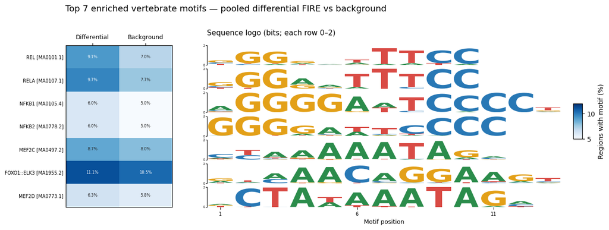

```python
if not top_motifs.empty:
    logo_figure = plot_motif_heatmap_and_logos(top_motifs, motif_probabilities)
    logo_figure.savefig(figures_dir / 'top100_motif_heatmap_logos.pdf', bbox_inches='tight')
    plt.show()
    plt.close(logo_figure)
else:
    print('Heatmap/logos: waiting for results, or no motifs meet the enrichment cutoff.')
```

### 2. Top enriched motifs: odds-ratio lollipop plot

The x-axis is odds ratio on a logarithmic scale; the reference line is OR = 1. Point color shows shared versus differential-only status. Triangles flag zero-cell tables whose plotted odds ratios use the 0.5 correction described above. Exact, potentially infinite odds ratios are available in the result TSV.

```python
def plot_motif_lollipops(top_table):
    """Plot finite odds ratios while identifying corrected zero-cell tables."""
    fig, ax = plt.subplots(figsize=(12, max(4, 0.29 * len(top_table) + 1.5)))
    y = np.arange(len(top_table))
    palette = {'shared': '#3274a1', 'differential-only': '#dd8452'}
    ax.hlines(y, 1, top_table['odds_ratio_plot'], color='#c7c7c7', linewidth=1.1)
    for status, color in palette.items():
        for corrected, marker in [(False, 'o'), (True, '^')]:
            keep = (top_table['motif_status'] == status) & (top_table['zero_cell_correction'] == corrected)
            if keep.any():
                ax.scatter(top_table.loc[keep, 'odds_ratio_plot'], y[keep], color=color,
                           marker=marker, s=35, zorder=3,
                           label=status + (' (0.5 correction)' if corrected else ''))
    ax.axvline(1, color='#555555', linestyle='--', linewidth=1)
    ax.set_xscale('log')
    ax.set_yticks(y, top_table['label'], fontsize=7)
    ax.invert_yaxis()
    ax.set_xlabel('Odds ratio: differential vs background (log scale)')
    ax.set_title(f'Top {len(top_table)} enriched motifs (BH q < {fdr_threshold})')
    ax.grid(axis='x', alpha=0.2)
    ax.spines[['top', 'right']].set_visible(False)
    ax.legend(loc='best', fontsize=8)
    fig.tight_layout()
    return fig
```

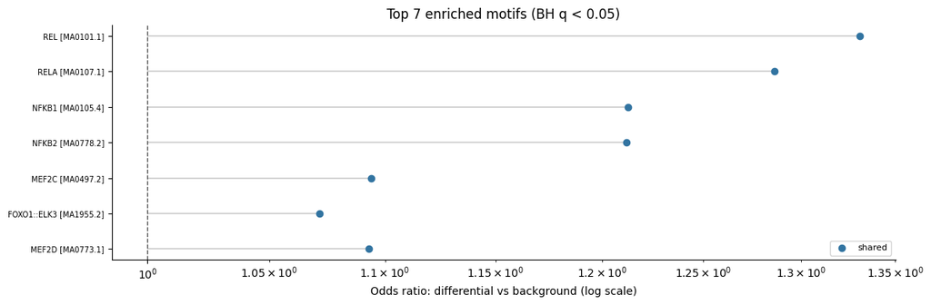

```python
if not top_motifs.empty:
    lollipop_figure = plot_motif_lollipops(top_motifs)
    lollipop_figure.savefig(figures_dir / 'top100_motif_odds_ratios.pdf', bbox_inches='tight')
    plt.show()
    plt.close(lollipop_figure)
else:
    print('Lollipop plot: waiting for results, or no motifs meet the enrichment cutoff.')
```

### 3. Shared and differential-only motif enrichment

Plot the same top significant motifs: x = log2 odds ratio and y = −log10(raw two-sided Fisher p)

```python
def plot_shared_unique_enrichment(top_table):
    """Plot enrichment strength and significance by motif detection category."""
    fig, ax = plt.subplots(figsize=(11, 7))
    palette = {'shared': '#3274a1', 'differential-only': '#dd8452'}
    for status, color in palette.items():
        subset = top_table.loc[top_table['motif_status'] == status]
        if not subset.empty:
            ax.scatter(subset['log2_odds_ratio_plot'], subset['neg_log10_p'],
                       s=30 + 150 * subset['differential_fraction'], c=color, alpha=0.8,
                       edgecolors='white', linewidths=0.5, label=f'{status} (n={len(subset)})')
    # Place labels in a separate right margin so clustered significant motifs remain legible.
    labels = top_table.head(10).sort_values('neg_log10_p', ascending=False)
    for i, (_, row) in enumerate(labels.iterrows()):
        ax.annotate(row['label'], (row['log2_odds_ratio_plot'], row['neg_log10_p']),
                    xytext=(1.02, 0.92 - i * 0.078), textcoords='axes fraction', fontsize=8,
                    va='center', annotation_clip=False,
                    arrowprops={'arrowstyle': '-', 'color': '#aaaaaa', 'lw': 0.6})
    ax.axvline(0, color='#777777', linestyle='--', linewidth=1)
    ax.set_xlabel('log2 odds ratio: differential vs background (0.5 correction for zero cells)')
    ax.set_ylabel('−log10(Fisher enrichment p-value)')
    ax.set_title(f'Top {len(top_table)} significant motifs: shared vs differential-only')
    ax.legend(title='Detection at FIMO p ≤ 1e-4', fontsize=9, loc='upper left')
    ax.spines[['top', 'right']].set_visible(False)
    ax.margins(x=0.2, y=0.2)
    fig.subplots_adjust(left=0.1, right=0.74, bottom=0.13, top=0.92)
    return fig
```

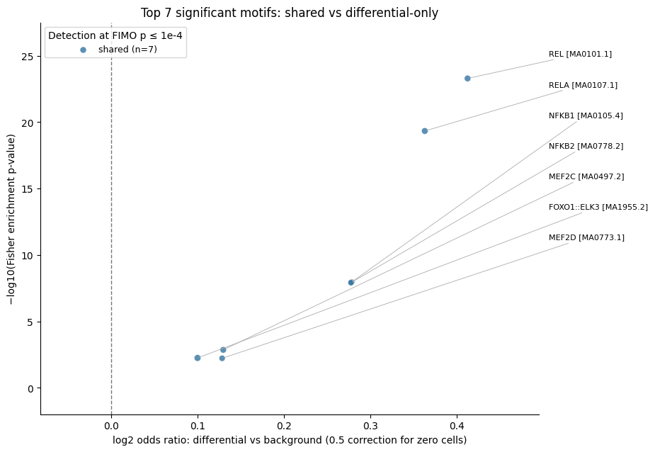

```python
if not top_motifs.empty:
    shared_unique_figure = plot_shared_unique_enrichment(top_motifs)
    shared_unique_figure.savefig(figures_dir / 'top100_shared_unique_enrichment.pdf', bbox_inches='tight')
    plt.show()
    plt.close(shared_unique_figure)
    print(f'Result tables, region/motif count matrices, and figures saved to {enrichment_dir}')
else:
    print('Shared/unique plot: waiting for results, or no motifs meet the enrichment cutoff.')
```

### 4. Expression of the top 100 significant TF genes across time

Colors show within-TF z-scores of log2(mean CPM + 1) across the displayed time points: red is above that TF's temporal average and blue is below it. Each TF is scaled separately using the population standard deviation across time; constant-expression rows are neutral. Cell numbers show the original mean CPM across three replicates. This scaling highlights temporal patterns, including small changes, and does not test differential expression. Gene selection and expression filtering are unchanged. Figures are saved as PDF only.

```python
def select_top_enriched_tf_genes(results, components, limit=100):
    """Rank unique expressed human TF genes by their best significant motif."""
    significant = results.loc[results['significant_enrichment'],
                              ['motif_id', 'q_value', 'p_value', 'odds_ratio']]
    mapped = components.dropna(subset=['gene_name'])[['motif_id', 'gene_name']].drop_duplicates()
    ranked = significant.merge(mapped, on='motif_id', validate='one_to_many')
    return (ranked.sort_values(['q_value', 'p_value', 'odds_ratio', 'gene_name'],
                               ascending=[True, True, False, True])
            .drop_duplicates('gene_name').head(limit).reset_index(drop=True))
```

```python
top_tf_genes = pd.DataFrame()
if enrichment_results is not None:
    top_tf_genes = select_top_enriched_tf_genes(enrichment_results, motif_tf_components, top_n)
    top_tf_genes.to_csv(tables_dir / 'top100_significant_tf_genes.tsv', sep='\t', index=False)
    top_tf_expression = gene_time_mean_cpm.reindex(top_tf_genes['gene_name'])
    top_tf_expression.to_csv(tables_dir / 'top100_tf_mean_cpm_by_time.tsv', sep='\t')
    print(f'{len(top_tf_genes)} unique TF genes selected from significant motifs.')
    display(top_tf_genes.head(15))
    display(top_tf_expression.head(15).round(2))
else:
    print('Top significant TF expression: waiting for both FIMO scans. Replicate/time expression tables are already available.')
```

|  | motif_id | q_value | p_value | odds_ratio | gene_name |
| --- | --- | --- | --- | --- | --- |
| 0 | MA0101.1 | 2.612484e-21 | 5.082655e-24 | 1.330912 | REL |
| 1 | MA0107.1 | 7.856424e-18 | 4.585462e-20 | 1.285962 | RELA |
| 2 | MA0105.4 | 8.889597e-07 | 1.096924e-08 | 1.212675 | NFKB1 |
| 3 | MA0778.2 | 8.889597e-07 | 1.210646e-08 | 1.211929 | NFKB2 |
| 4 | MA0497.2 | 1.395117e-02 | 1.384261e-03 | 1.093855 | MEF2C |
| 5 | MA1955.2 | 4.399302e-02 | 5.648910e-03 | 1.071487 | ELK3 |
| 6 | MA1955.2 | 4.399302e-02 | 5.648910e-03 | 1.071487 | FOXO1 |
| 7 | MA0773.1 | 4.592485e-02 | 5.986313e-03 | 1.092874 | MEF2D |

| time_min gene_name | 0 | 5 | 10 | 15 |
| --- | --- | --- | --- | --- |
| REL | 21.00 | 21.64 | 21.29 | 22.80 |
| RELA | 81.05 | 80.87 | 78.92 | 83.57 |
| NFKB1 | 67.95 | 68.03 | 65.69 | 67.06 |
| NFKB2 | 43.78 | 45.00 | 41.75 | 45.18 |
| MEF2C | 281.23 | 298.42 | 285.75 | 298.24 |
| ELK3 | 81.17 | 84.26 | 81.41 | 84.04 |
| FOXO1 | 4.55 | 4.42 | 5.06 | 4.40 |
| MEF2D | 579.65 | 554.43 | 561.26 | 555.07 |

plot expression as Z score of log2(mean CPM + 1)

negative values = SD below that the TF's averae across time points

```python
def plot_tf_expression_timecourse(mean_cpm, ranked_genes):
    """Color by within-TF z-score of log2(mean CPM + 1); annotate actual CPM."""
    values = mean_cpm.reindex(ranked_genes['gene_name'])
    if values.empty or values.isna().any().any():
        raise ValueError('Missing expression for a selected TF gene')
    log_values = np.log2(values.to_numpy() + 1)
    centered = log_values - log_values.mean(axis=1, keepdims=True)
    row_sd = log_values.std(axis=1, keepdims=True)
    z_values = np.divide(centered, row_sd, out=np.zeros_like(centered),
                         where=row_sd > np.finfo(float).eps)
    color_limit = max(1.0, float(np.abs(z_values).max()))
    fig, ax = plt.subplots(figsize=(10, max(4, 0.28 * len(values) + 1.5)))
    heat = ax.imshow(z_values, cmap='RdBu_r', aspect='auto',
                     vmin=-color_limit, vmax=color_limit)
    for row in range(len(values)):
        for col in range(len(values.columns)):
            ax.text(col, row, f'{values.iloc[row, col]:.1f}', ha='center', va='center',
                    fontsize=8, color='white' if abs(z_values[row, col]) > 0.65 * color_limit
                    else '#222222')
    ax.set_xticks(np.arange(len(values.columns)), [f'{time} min' for time in values.columns])
    ax.set_yticks(np.arange(len(values)), values.index, fontsize=7)
    ax.set_xlabel('LPS time point; cell numbers = mean CPM across three replicates')
    ax.set_ylabel('TF gene; ranked by best enriched motif')
    ax.set_title(f'Expression of top {len(values)} TF genes associated with enriched motifs\n'
                 'Colors show relative expression within each TF', fontsize=12)
    fig.colorbar(heat, ax=ax, fraction=0.03, pad=0.03,
                 label='Within-TF z-score of log2(mean CPM + 1)')
    fig.tight_layout()
    return fig
```

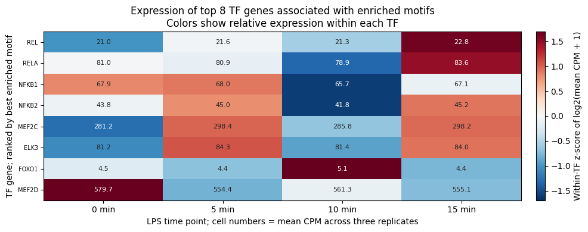

```python
if not top_tf_genes.empty:
    expression_figure = plot_tf_expression_timecourse(gene_time_mean_cpm, top_tf_genes)
    expression_figure.savefig(figures_dir / 'top100_tf_expression_timecourse.pdf', bbox_inches='tight')
    plt.show()
    plt.close(expression_figure)
else:
    print('Expression heatmap: no expressed TFs have significant motifs.')
```

### 5. Top enriched motifs by raw Fisher p-value

Select up to 100 expression-eligible motifs with odds ratio > 1 and **raw enrichment p < 0.05**, ranked by raw p, then decreasing odds ratio `motif_enrichment_top100_raw_p.tsv`

```python
def plot_raw_p_motif_enrichment(top_table, raw_p_cutoff=0.05, bh_cutoff=0.05):
    """Plot raw enrichment significance and distinguish BH-supported motifs."""
    if top_table.empty:
        raise ValueError('No motifs selected for the raw-p plot')
    values = -np.log10(top_table['p_value'].clip(lower=np.finfo(float).tiny))
    y = np.arange(len(top_table))
    fig, ax = plt.subplots(figsize=(12, max(4, 0.30 * len(top_table) + 2)))
    ax.hlines(y, 0, values, color='#c7c7c7', linewidth=1.2)
    bh_pass = top_table['q_value'].lt(bh_cutoff)
    for keep, color, label in [
        (bh_pass, '#3274a1', f'Also BH q < {bh_cutoff}'),
        (~bh_pass, '#dd8452', f'Raw p only (BH q ≥ {bh_cutoff})'),
    ]:
        if keep.any():
            ax.scatter(values.loc[keep], y[keep.to_numpy()], color=color, s=38,
                       zorder=3, label=f'{label}; n={int(keep.sum())}')
    ax.axvline(-np.log10(raw_p_cutoff), color='#555555', linestyle='--', linewidth=1,
               label=f'Raw p = {raw_p_cutoff}')
    ax.set_yticks(y, top_table['label'], fontsize=8)
    ax.invert_yaxis()
    ax.set_xlim(left=0)
    ax.set_xlabel('−log10(raw Fisher enrichment p-value)')
    ax.set_title(f'Top {len(top_table)} motifs ranked by raw enrichment p-value\n'
                 f'Expressed TFs; odds ratio > 1; raw p < {raw_p_cutoff}', fontsize=12)
    ax.grid(axis='x', alpha=0.2)
    ax.spines[['top', 'right']].set_visible(False)
    ax.legend(loc='lower right', fontsize=8)
    fig.tight_layout()
    return fig
```

```python
raw_p_threshold = 0.05
raw_p_candidates = enrichment_results.loc[
    enrichment_results['expressed_any_time']
    & enrichment_results['odds_ratio'].gt(1)
    & enrichment_results['p_value'].lt(raw_p_threshold)
].sort_values(['p_value', 'odds_ratio', 'motif_id'], ascending=[True, False, True])
top_raw_p_motifs = raw_p_candidates.head(top_n).copy()
top_raw_p_motifs.to_csv(tables_dir / 'motif_enrichment_top100_raw_p.tsv', sep='\t', index=False)
print(f'{len(raw_p_candidates)} expression-eligible motifs have raw p < {raw_p_threshold} and OR > 1; '
      f'plotting {len(top_raw_p_motifs)} (up to {top_n}).')
print(f'{top_raw_p_motifs["q_value"].lt(fdr_threshold).sum()} plotted motifs also pass BH q < {fdr_threshold}.')
display(top_raw_p_motifs[['motif_id', 'TF', 'odds_ratio', 'p_value', 'q_value']].head(10))
```

|  | motif_id | TF | odds_ratio | p_value | q_value |
| --- | --- | --- | --- | --- | --- |
| 0 | MA0101.1 | REL | 1.330912 | 5.082655e-24 | 2.612484e-21 |
| 2 | MA0107.1 | RELA | 1.285962 | 4.585462e-20 | 7.856424e-18 |
| 5 | MA0105.4 | NFKB1 | 1.212675 | 1.096924e-08 | 8.889597e-07 |
| 6 | MA0778.2 | NFKB2 | 1.211929 | 1.210646e-08 | 8.889597e-07 |
| 50 | MA0497.2 | MEF2C | 1.093855 | 1.384261e-03 | 1.395117e-02 |
| 65 | MA1955.2 | FOXO1::ELK3 | 1.071487 | 5.648910e-03 | 4.399302e-02 |
| 66 | MA0773.1 | MEF2D | 1.092874 | 5.986313e-03 | 4.592485e-02 |
| 70 | MA0052.5 | MEF2A | 1.079310 | 7.708700e-03 | 5.532266e-02 |
| 84 | MA1117.2 | RELB | 1.128546 | 1.419602e-02 | 8.584418e-02 |
| 111 | MA1936.2 | ERF::FOXO1 | 1.049243 | 3.571983e-02 | 1.639285e-01 |

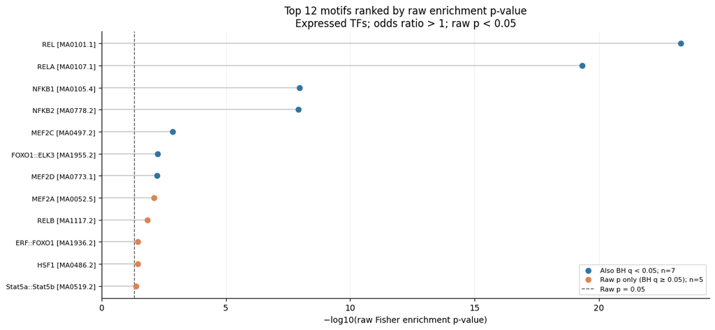

```python
if not top_raw_p_motifs.empty:
    raw_p_figure = plot_raw_p_motif_enrichment(top_raw_p_motifs, raw_p_threshold, fdr_threshold)
    raw_p_figure.savefig(figures_dir / 'top100_motif_raw_p.pdf', bbox_inches='tight')
    plt.show()
    plt.close(raw_p_figure)
else:
    print('Raw-p plot: no expressed-TF motifs meet raw p < 0.05 and odds ratio > 1.')
```

### 6. Differential-versus-background motif prevalence: eligible motifs with defined OR

Plot expression-eligible motifs with defined odds ratios, without an enrichment p-value cutoff or top-N limit. Exclude undefined odds ratios, including the 47 motifs with no hits in either set in the current results. These motifs remain in the two-sided testing/BH family; only this plot excludes them.

The x-axis is the percentage of background regions with at least one motif hit; the y-axis is the corresponding percentage of differential FIRE regions. The common scale and diagonal show equal prevalence. Orange indicates OR > 1, blue OR < 1, and gray OR = 1. Colors describe direction, not significance. Export the plotted table and PDF only.

```python
def plot_eligible_motif_proportions(motif_table):
    """Compare region-level motif prevalence for expression-eligible motifs with defined OR."""
    if motif_table.empty:
        raise ValueError('No expression-eligible motifs to plot')
    x = motif_table['background_fraction'] * 100
    y = motif_table['differential_fraction'] * 100
    upper = max(1.0, float(max(x.max(), y.max())) * 1.05)
    fig, ax = plt.subplots(figsize=(8, 8))
    ax.plot([0, upper], [0, upper], linestyle='--', color='#777777',
            linewidth=1, label='Equal prevalence', zorder=1)
    categories = [
        ('OR > 1', '#d95f02', 'o'),
        ('OR < 1', '#2878b5', 'o'),
        ('OR = 1', '#777777', 'o'),
    ]
    for category, color, marker in categories:
        keep = motif_table['or_category'].eq(category)
        if keep.any():
            ax.scatter(x.loc[keep], y.loc[keep], color=color, marker=marker,
                       s=32, alpha=0.7, linewidths=0.7, zorder=3,
                       label=f'{category} (n={int(keep.sum())})')
    ax.set_xlim(-upper * 0.025, upper)
    ax.set_ylim(-upper * 0.025, upper)
    ax.set_aspect('equal', adjustable='box')
    ax.set_xlabel('Background regions with ≥1 motif hit (%)')
    ax.set_ylabel('Differential FIRE regions with ≥1 motif hit (%)')
    ax.set_title(f'{len(motif_table)} expression-eligible motifs with defined OR\n'
                 'Differential versus background prevalence; no enrichment p-value filtering')
    ax.grid(alpha=0.15)
    ax.spines[['top', 'right']].set_visible(False)
    ax.legend(loc='best', fontsize=8)
    fig.tight_layout()
    return fig
```

```python
eligible_motif_proportions = enrichment_results.loc[
    enrichment_results['expressed_any_time']
    & enrichment_results['odds_ratio'].notna()
].copy()
# Exclude undefined ORs only from this plot; retain infinite ORs for differential-only hits.
eligible_motif_proportions['or_category'] = np.select(
    [eligible_motif_proportions['odds_ratio'].gt(1),
     eligible_motif_proportions['odds_ratio'].lt(1),
     eligible_motif_proportions['odds_ratio'].eq(1)],
    ['OR > 1', 'OR < 1', 'OR = 1'], default='OR undefined'
)
eligible_motif_proportions.to_csv(
    tables_dir / 'all_eligible_motif_proportions.tsv', sep='\t', index=False
)
print(f'Plotting {len(eligible_motif_proportions)} expression-eligible motifs with defined OR.')
display(eligible_motif_proportions['or_category'].value_counts().rename('motifs').to_frame())
```

| or_category | motifs |
| --- | --- |
| OR < 1 | 344 |
| OR > 1 | 123 |

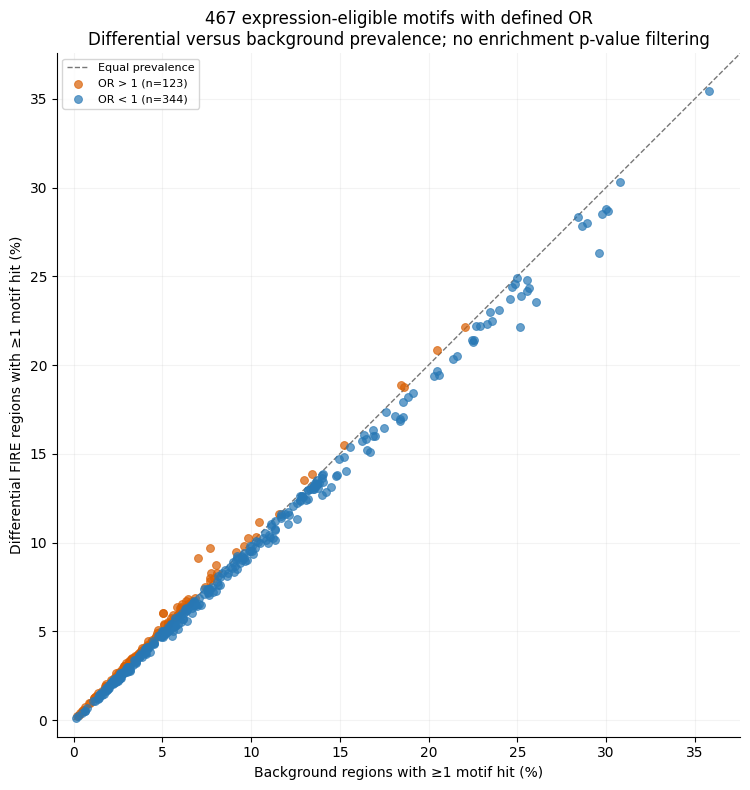

```python
if not eligible_motif_proportions.empty:
    proportion_figure = plot_eligible_motif_proportions(eligible_motif_proportions)
    proportion_figure.savefig(figures_dir / 'all_eligible_motif_proportions.pdf', bbox_inches='tight')
    plt.show()
    plt.close(proportion_figure)
else:
    print('No expression-eligible motifs available for the proportion scatter plot.')
```

## 7. Map motif profiles to TF genes and test Gene Ontology enrichment

Convert motifs into unique TF genes

1. Keep motifs whose TFs pass the expression filter and have a defined OR.
2. Map motifs to TF genes using the validated component mappings.
3. Define enriched TFs from motifs with **raw two-sided motif p < 0.05 and OR > 1**; define depleted TFs from motifs with **raw two-sided motif p < 0.05 and OR < 1**. Motif-level BH q-values are not used to select these GO gene sets.
4. Collapse multiple motif profiles mapping to the same TF into a unique gene, including individual components of complex motifs.
5. Create separate `go_sets` for enriched and depleted TF genes, retaining the same 402-gene background.
6. Flag genes supported in both directions by different motif profiles

```python
def map_motifs_to_ontology_genes(results, components, motif_p_cutoff=0.05):
    """Deduplicate validated motif-to-gene mappings and construct GO gene sets."""
    # eligible motifs are those that are expressed at any time point and have a defined odds ratio
    eligible = results.loc[results['expressed_any_time'] & results['odds_ratio'].notna()].copy()
    if eligible.empty or eligible['motif_id'].duplicated().any():
        raise ValueError('Expected a nonempty set of unique eligible motif IDs')
    matched = components.loc[components['motif_id'].isin(eligible['motif_id'])].copy()
    if matched['gene_name'].isna().any() or set(matched['motif_id']) != set(eligible['motif_id']):
        raise ValueError('Incomplete gene mappings for eligible motifs')
    if matched.groupby(['motif_id', 'component'])['gene_name'].nunique().gt(1).any():
        raise ValueError('Ambiguous motif-component gene mapping')
    links = matched[['motif_id', 'TF', 'gene_name']].drop_duplicates().merge(
        eligible[['motif_id', 'odds_ratio', 'p_value', 'q_value']], on='motif_id', validate='many_to_one')
    links['enriched_motif'] = links['p_value'].lt(motif_p_cutoff) & links['odds_ratio'].gt(1)
    links['depleted_motif'] = links['p_value'].lt(motif_p_cutoff) & links['odds_ratio'].lt(1)
    genes = links.groupby('gene_name', sort=True).agg(
        n_motif_profiles=('motif_id', 'nunique'),
        motif_ids=('motif_id', lambda s: ';'.join(sorted(set(s)))),
        in_enriched_set=('enriched_motif', 'any'),
        in_depleted_set=('depleted_motif', 'any')).reset_index()
    genes['in_both_sets'] = genes['in_enriched_set'] & genes['in_depleted_set']
    go_sets = {direction: sorted(genes.loc[genes[f'in_{direction}_set'], 'gene_name'])
                   for direction in ['enriched', 'depleted']}
    return links.sort_values(['gene_name', 'motif_id']), genes, go_sets
```

```python
# Convert motifs into unique TF genes using raw motif p-values
ontology_motif_p_threshold = 0.05
ontology_motif_results = pd.read_csv(tables_dir / 'motif_enrichment_all.tsv', sep='	')
ontology_components = pd.read_csv(tables_dir / 'motif_tf_gene_mapping.tsv', sep='	')
ontology_links, ontology_gene_summary, go_sets = map_motifs_to_ontology_genes(
    ontology_motif_results, ontology_components, motif_p_cutoff=ontology_motif_p_threshold)
ontology_background = sorted(ontology_gene_summary['gene_name'])
ontology_links.to_csv(tables_dir / 'ontology_background_tf_motif_mapping.tsv', sep='	', index=False)
ontology_mean_cpm = pd.read_csv(tables_dir / 'gene_mean_cpm_by_time.tsv', sep='	', index_col=0)
ontology_mean_cpm.columns = [f'mean_cpm_{t}min' for t in ontology_mean_cpm.columns]
ontology_gene_summary = ontology_gene_summary.merge(
    ontology_mean_cpm, left_on='gene_name', right_index=True, how='left', validate='one_to_one')
ontology_gene_summary.to_csv(tables_dir / 'ontology_background_tf_genes.tsv', sep='	', index=False)
(tables_dir / 'ontology_background_tf_genes.txt').write_text('\n'.join(ontology_background) + '\n')
for direction, genes in go_sets.items():
    (tables_dir / f'ontology_{direction}_tf_genes.txt').write_text('\n'.join(genes) + ('\n' if genes else ''))
    ontology_gene_summary.loc[ontology_gene_summary[f'in_{direction}_set']].to_csv(
        tables_dir / f'ontology_{direction}_tf_genes.tsv', sep='	', index=False)
print(f'{ontology_links["motif_id"].nunique()} motif profiles map to {len(ontology_background)} unique TF genes.')
print('GO gene-set counts:', {k: len(v) for k, v in go_sets.items()})
print('Genes in both GO gene sets:', int(ontology_gene_summary['in_both_sets'].sum()))
display(ontology_gene_summary.head(10))
```

|  | gene_name | n_motif_profiles | motif_ids | in_enriched_set | in_depleted_set | in_both_sets | mean_cpm_0min | mean_cpm_5min | mean_cpm_10min | mean_cpm_15min |
| --- | --- | --- | --- | --- | --- | --- | --- | --- | --- | --- |
| 0 | AR | 1 | MA0007.4 | False | False | False | 98.649256 | 95.737112 | 99.433987 | 94.038242 |
| 1 | ARID5A | 1 | MA0602.2 | False | False | False | 79.813073 | 78.079304 | 75.561726 | 79.567955 |
| 2 | ARNT2 | 1 | MA1464.2 | False | False | False | 174.220596 | 177.498925 | 177.251599 | 165.221712 |
| 3 | ATF1 | 1 | MA0604.1 | False | True | False | 9.962720 | 9.563187 | 9.993123 | 10.026607 |
| 4 | ATF2 | 1 | MA1632.2 | False | False | False | 41.818970 | 43.690679 | 43.516644 | 46.333408 |
| 5 | ATF3 | 2 | MA0605.3;MA1988.2 | False | False | False | 58.348845 | 58.363293 | 57.599360 | 64.853147 |
| 6 | ATF4 | 1 | MA0833.3 | False | False | False | 294.673977 | 288.025996 | 282.309906 | 295.889721 |
| 7 | ATF6 | 1 | MA1466.2 | False | False | False | 109.202438 | 111.381649 | 107.741294 | 113.743323 |
| 8 | ATF7 | 1 | MA0834.2 | False | True | False | 41.143520 | 40.829362 | 39.283908 | 41.966820 |
| 9 | BACH1 | 2 | MA0591.2;MA1633.2 | False | False | False | 146.434263 | 151.485214 | 147.556662 | 154.779875 |

GO libraries: https://maayanlab.cloud/Enrichr/#libraries

`/project/spott/cshan/fiber-seq/macrophage_project/fire_frequency/tf_motif/enrichment/tables/go_annotations/`

```python
def load_go_libraries(libraries, annotation_dir):
    """Load local GO GMT tables into term-to-gene records."""
    terms = []
    for source, library in libraries.items():
        path = annotation_dir / f'{library}.gmt'
        with path.open() as handle:
            for line in handle:
                if not line.strip():
                    continue
                fields = line.rstrip('\n').split('\t')
                terms.append({
                    'source': source,
                    'library': library,
                    'term_id': re.search(r'GO:\d{7}', fields[0]).group(),
                    'term_name': fields[0],
                    'genes': frozenset(g.strip() for g in fields[2:] if g.strip()),
                })
    return terms
```

```python
go_libraries = {'GO:BP': 'GO_Biological_Process_2026',
                'GO:MF': 'GO_Molecular_Function_2026',
                'GO:CC': 'GO_Cellular_Component_2026'}
go_terms = load_go_libraries(
    go_libraries, tables_dir / 'go_annotations')
print(f'Loaded {len(go_terms):,} GO terms from annotation files.')
```

### GO enrichment

If the GO term represented more often in the TF that are enriched/depleted than expected based on all the TFs (402 genes)

- N = total number of TF genes in your background
- n = number of TF genes in your enriched/depleted set
- K = number of background TF genes belonging to that GO term
- k = number of enriched/depleted TF genes belonging to that GO term

Hypergeometric test: “If I draw n genes from my background, what's the probability of getting ≥ k genes from this GO term?”

Ex: The GO enrichment test determines whether the proportion of TF genes associated with a particular GO term is higher in the enriched/depleted TF set than expected based on the TF-gene background. For example, it tests whether observing 8 GO-term genes among 20 enriched TF genes (8/20) represents significant overrepresentation given that 15 of the 100 TF genes in the background (15/100) are associated with that GO term.

```python
def test_go_enrichment(go_sets, background_genes, terms):
    """Test GO enrichment with BH across every term"""
    from scipy.stats import hypergeom
    background = set(background_genes)
    if not background:
        raise ValueError('Empty ontology background')
    if any(not set(genes) <= background for genes in go_sets.values()):
        raise ValueError('Ontology go_sets contains genes outside the background')
    rows, coverage = [], []
    N = len(background)
    for direction, genes in go_sets.items():
        query = set(genes)
        n = len(query)
        for term in terms:
            members = background & term['genes']
            K = len(members)
            if K == 0:
                continue
            overlap = sorted(query & members)
            k = len(overlap)
            rows.append({'go_sets': direction, 'source': term['source'],
                         'term_id': term['term_id'], 'term_name': term['term_name'],
                         'query_size': n, 'background_size': N, 'overlap_size': k,
                         'background_overlap_size': K,
                         'gene_ratio': k / n if n else 0.0, 'background_ratio': K / N,
                         'fold_enrichment': (k / n) / (K / N) if n else 0.0,
                         'p_value': float(hypergeom.sf(k - 1, N, K, n)),
                         'overlap_genes': ';'.join(overlap)})
        for source in sorted({term['source'] for term in terms}):
            annotated = set().union(*(term['genes'] for term in terms if term['source'] == source))
            missing = sorted(background - annotated)
            coverage.append({'go_sets': direction, 'source': source,
                             'background_size': N, 'annotated_background_genes': len(background & annotated),
                             'query_size': n, 'annotated_query_genes': len(query & annotated),
                             'unannotated_background_genes': ';'.join(missing),
                             'unannotated_query_genes': ';'.join(sorted(query - annotated))})
    results = pd.DataFrame(rows)
    if results.empty:
        raise ValueError('No GO terms overlap the TF background')
    results['q_value'] = adjust_bh(results['p_value'].to_numpy())
    return results.sort_values(['q_value', 'p_value', 'go_sets', 'source', 'term_id']), pd.DataFrame(coverage)
```

Run GO enrichment and calculate BH-adjusted q-values for all tests. Keep `ontology_q_threshold = 0.05` to identify BH-supported terms, but report terms using **raw GO p < 0.05** (`ontology_p_threshold`). The plot ranks reported terms by raw p-value and shows **−log10(raw GO p-value)**, with up to 15 terms per gene set. Both raw p-values and adjusted q-values remain in the tables; raw-p-selected terms are not necessarily significant after BH correction. The raw-p report is `ontology_go_raw_p_reported.tsv`; `ontology_go_significant.tsv` retains only BH-significant terms.

```python
ontology_q_threshold = 0.05  # Retained for BH-adjusted significance
ontology_p_threshold = 0.05  # Raw GO p-value cutoff for reporting and plotting
ontology_results, ontology_coverage = test_go_enrichment(
    go_sets, ontology_background, go_terms)
ontology_significant = ontology_results.loc[ontology_results['q_value'].lt(ontology_q_threshold)].copy()
ontology_reported = ontology_results.loc[ontology_results['p_value'].lt(ontology_p_threshold)].sort_values(['p_value', 'go_sets', 'source', 'term_id']).copy()
ontology_results.to_csv(tables_dir / 'ontology_go_all_tests.tsv', sep='	', index=False)
ontology_significant.to_csv(tables_dir / 'ontology_go_significant.tsv', sep='	', index=False)
ontology_reported.to_csv(tables_dir / 'ontology_go_raw_p_reported.tsv', sep='	', index=False)
ontology_coverage.to_csv(tables_dir / 'ontology_annotation_coverage.tsv', sep='	', index=False)
for direction in go_sets:
    ontology_results.loc[ontology_results['go_sets'].eq(direction)].to_csv(
        tables_dir / f'ontology_go_{direction}.tsv', sep='	', index=False)
ontology_settings = {'method': 'local hypergeometric upper tail; custom TF background',
                     'correction': 'BH across all GO terms and both go_sets together',
                     'motif_selection': f'two-sided raw motif p < {ontology_motif_p_threshold}; OR > 1 or OR < 1',
                     'background_size': len(ontology_background),
                     'go_sets_sizes': {k: len(v) for k, v in go_sets.items()},
                     'libraries': go_libraries, 'ontology_q_threshold': ontology_q_threshold,
                     'ontology_p_threshold': ontology_p_threshold,
                     'report_selection': 'raw GO p-value cutoff; BH q-values retained',
                     'plot_axis': '-log10(raw GO p-value)',
                     'tests': len(ontology_results),
                     'input_sha256': {name: hashlib.sha256((tables_dir / name).read_bytes()).hexdigest()
                                      for name in ['motif_enrichment_all.tsv', 'motif_tf_gene_mapping.tsv']}}
(tables_dir / 'ontology_analysis_settings.json').write_text(json.dumps(ontology_settings, indent=2))
print(f'{len(ontology_results):,} GO tests; {len(ontology_significant)} pass global BH q < {ontology_q_threshold}.')
print(f'Reporting {len(ontology_reported)} terms with raw GO p < {ontology_p_threshold}; plots show up to 15 per gene set.')
display(ontology_coverage.drop(columns=['unannotated_background_genes', 'unannotated_query_genes']))
if ontology_reported.empty:
    print('No GO terms meet the raw p-value reporting threshold.')
else:
    display(ontology_reported[['go_sets', 'source', 'term_name', 'overlap_size',
                                  'query_size', 'fold_enrichment', 'p_value', 'q_value', 'overlap_genes']].head(20))
```

|  | go_sets | source | background_size | annotated_background_genes | query_size | annotated_query_genes |
| --- | --- | --- | --- | --- | --- | --- |
| 0 | enriched | GO:BP | 402 | 393 | 14 | 14 |
| 1 | enriched | GO:CC | 402 | 384 | 14 | 14 |
| 2 | enriched | GO:MF | 402 | 386 | 14 | 14 |
| 3 | depleted | GO:BP | 402 | 393 | 104 | 100 |
| 4 | depleted | GO:CC | 402 | 384 | 104 | 97 |
| 5 | depleted | GO:MF | 402 | 386 | 104 | 99 |

|  | go_sets | source | term_name | overlap_size | query_size | fold_enrichment | p_value | q_value | overlap_genes |
| --- | --- | --- | --- | --- | --- | --- | --- | --- | --- |
| 72 | enriched | GO:BP | Canonical NF-kappaB Signal Transduction (GO:00... | 5 | 14 | 28.714286 | 2.346167e-08 | 0.000095 | NFKB1;NFKB2;REL;RELA;RELB |
| 816 | enriched | GO:BP | Non-canonical NF-kappaB Signal Transduction (G... | 4 | 14 | 28.714286 | 9.337745e-07 | 0.001887 | NFKB1;REL;RELA;RELB |
| 407 | enriched | GO:BP | Intracellular Signaling Cassette (GO:0141124) | 7 | 14 | 6.090909 | 3.025596e-05 | 0.031071 | HSF1;MEF2C;NFKB1;NFKB2;REL;RELA;RELB |
| 382 | enriched | GO:BP | Inflammatory Response (GO:0006954) | 4 | 14 | 16.408163 | 3.074834e-05 | 0.031071 | NFKB1;REL;RELA;RELB |
| 165 | enriched | GO:BP | Cellular Response to Metal Ion (GO:0071248) | 3 | 14 | 21.535714 | 1.326809e-04 | 0.107259 | HSF1;MEF2A;MEF2C |
| 518 | enriched | GO:BP | Muscle Organ Development (GO:0007517) | 3 | 14 | 17.228571 | 3.248396e-04 | 0.207431 | MEF2A;MEF2C;MEF2D |
| 1169 | enriched | GO:BP | Positive Regulation of Transcription by RNA Po... | 13 | 14 | 1.954375 | 4.056618e-04 | 0.207431 | ELK3;FOXO1;HSF1;MEF2A;MEF2C;MEF2D;NFKB1;NFKB2;... |
| 161 | enriched | GO:BP | Cellular Response to Lipopolysaccharide (GO:00... | 3 | 14 | 14.357143 | 6.362304e-04 | 0.207431 | MEF2C;NFKB1;RELA |
| 175 | enriched | GO:BP | Cellular Response to Peptide Hormone Stimulus ... | 3 | 14 | 14.357143 | 6.362304e-04 | 0.207431 | FOXO1;NFKB1;RELA |
| 218 | enriched | GO:BP | Cytokine-mediated Signaling Pathway (GO:0019221) | 4 | 14 | 7.657143 | 1.018060e-03 | 0.207431 | NFKB1;RELA;STAT5A;STAT5B |
| 1709 | enriched | GO:BP | Response to Lipopolysaccharide (GO:0032496) | 3 | 14 | 12.306122 | 1.090342e-03 | 0.207431 | MEF2C;NFKB1;RELA |
| 166 | enriched | GO:BP | Cellular Response to Molecule of Bacterial Ori... | 3 | 14 | 12.306122 | 1.090342e-03 | 0.207431 | MEF2C;NFKB1;RELA |
| 1782 | enriched | GO:BP | Taurine Metabolic Process (GO:0019530) | 2 | 14 | 28.714286 | 1.129018e-03 | 0.207431 | STAT5A;STAT5B |
| 11 | enriched | GO:BP | Alkanesulfonate Metabolic Process (GO:0019694) | 2 | 14 | 28.714286 | 1.129018e-03 | 0.207431 | STAT5A;STAT5B |
| 1513 | enriched | GO:BP | Regulation of Multicellular Organism Growth (G... | 2 | 14 | 28.714286 | 1.129018e-03 | 0.207431 | STAT5A;STAT5B |
| 1388 | enriched | GO:BP | Regulation of Developmental Growth (GO:0048638) | 2 | 14 | 28.714286 | 1.129018e-03 | 0.207431 | STAT5A;STAT5B |
| 885 | enriched | GO:BP | Positive Regulation of RNA Metabolic Process (... | 2 | 14 | 28.714286 | 1.129018e-03 | 0.207431 | NFKB1;RELA |
| 1680 | enriched | GO:BP | Response to Calcium Ion (GO:0051592) | 2 | 14 | 28.714286 | 1.129018e-03 | 0.207431 | MEF2A;MEF2C |
| 1702 | enriched | GO:BP | Response to Interleukin-6 (GO:0070741) | 2 | 14 | 28.714286 | 1.129018e-03 | 0.207431 | NFKB1;RELA |
| 118 | enriched | GO:BP | Cellular Response to Calcium Ion (GO:0071277) | 2 | 14 | 28.714286 | 1.129018e-03 | 0.207431 | MEF2A;MEF2C |

```python
def plot_tf_go_enrichment(results, go_sets, p_cutoff=0.05, top_terms=15):
    """Summarize raw-p-selected GO terms separately for enriched/depleted TF genes."""
    import textwrap
    from matplotlib.patches import Patch
    directions = list(go_sets)
    selections = {d: results.loc[results['go_sets'].eq(d) & results['p_value'].lt(p_cutoff)]
                  .sort_values(['p_value', 'term_id']).head(top_terms) for d in directions}
    height = max(4, 0.45 * max(len(s) for s in selections.values()) + 2)
    fig, axes = plt.subplots(1, len(directions), figsize=(18, height), squeeze=False)
    palette = {'GO:BP': '#3274a1', 'GO:MF': '#dd8452', 'GO:CC': '#55a868'}
    for ax, direction in zip(axes.ravel(), directions):
        selected = selections[direction]
        ax.set_title(f'{direction.capitalize()} TF genes (n={len(go_sets[direction])})')
        if selected.empty:
            ax.text(0.5, 0.5, f'No GO terms with raw GO p < {p_cutoff}',
                    ha='center', va='center', transform=ax.transAxes)
            ax.set_axis_off()
            continue
        y = np.arange(len(selected))
        ax.barh(y, -np.log10(selected['p_value'].clip(lower=np.finfo(float).tiny)),
                color=[palette[s] for s in selected['source']])
        labels = [textwrap.fill(f'{row.term_name} [{row.overlap_size}/{row.query_size} genes]', 48)
                  for row in selected.itertuples()]
        ax.set_yticks(y, labels, fontsize=8)
        ax.invert_yaxis()
        ax.set_xlabel('−log10(raw GO p-value)')
        ax.spines[['top', 'right']].set_visible(False)
    fig.legend(handles=[Patch(color=color, label=source) for source, color in palette.items()],
               loc='lower center', ncol=3, frameon=False)
    fig.suptitle('GO overrepresentation among TF genes; raw GO p < 0.05; custom TF background', fontsize=13)
    fig.tight_layout(rect=[0, 0.06, 1, 0.95])
    return fig
```

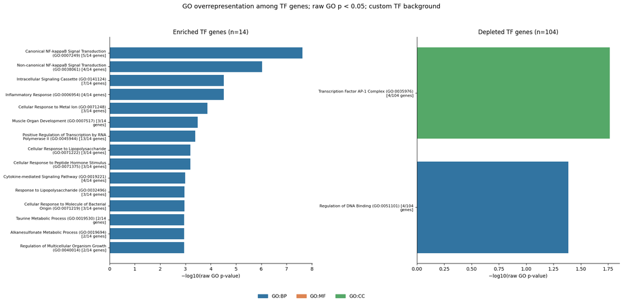

```python
ontology_figure = plot_tf_go_enrichment(ontology_results, go_sets, p_cutoff=ontology_p_threshold)
ontology_figure.savefig(figures_dir / 'tf_gene_ontology_enrichment.pdf', bbox_inches='tight')
plt.show()
plt.close(ontology_figure)
```

# 0 vs 15 min TF motif enrichment analysis at FIRE regions

```python
import os
import io
import re
import sys
import json
import hashlib
import subprocess
import shutil
from pathlib import Path

import numpy as np
import pandas as pd
import matplotlib
matplotlib.use('Agg')
import matplotlib.pyplot as plt
from scipy import sparse
from scipy.stats import fisher_exact
from IPython.display import display, FileLink
import base64

project_root = Path('/project/spott/cshan/fiber-seq')
analysis_root = project_root / 'macrophage_project/fire_frequency'
output_root = analysis_root / 'tf_motif/0_vs_15_min'
# Retain table contents in notebook memory; display previews without disk exports.
notebook_tables = {}

def remember_table(name, table, **csv_options):
    csv_options.setdefault('sep', '\t')
    notebook_tables[name] = table.to_csv(None, **csv_options)
    display(table.head())
plots_dir = output_root / 'plots'
example_root = output_root / 'example_regions'
for directory in (plots_dir, example_root):
    directory.mkdir(parents=True, exist_ok=True)

generate_example_plots = True  # Six requested examples; display RELA and ZNF131 only.
comparison = 'LPS_0_vs_LPS_15'
raw_p_threshold = 0.05
fdr_threshold = 0.05
expected_timepoints = [0, 5, 10, 15]
seed = 1
np.random.seed(seed)
plt.rcParams.update({'pdf.fonttype': 42, 'font.size': 10, 'axes.spines.top': False,
                     'axes.spines.right': False, 'svg.hashsalt': 'fire_0_15'})

def display_pdf_file(path, height=680, dpi=300):
    """Display only RELA and ZNF131 example plots as real inline images, without filename text."""
    path = Path(path)
    if path.is_relative_to(example_root):
        visible = selected_examples.loc[selected_examples['selection_TF'].isin(['RELA', 'ZNF131'])]
        if path.parent.name not in {example_folder_name(row.selection_TF, row.region_id)
                                   for row in visible.itertuples(index=False)}:
            return
    renderer = shutil.which('gs')
    if not renderer:
        raise RuntimeError('Inline plot display requires Ghostscript (gs).')
    rendered = subprocess.run([
        renderer, '-q', '-dSAFER', '-dBATCH', '-dNOPAUSE', '-dFirstPage=1', '-dLastPage=1',
        '-sDEVICE=png16m', f'-r{dpi}', '-dTextAlphaBits=4', '-dGraphicsAlphaBits=4',
        '-sOutputFile=%stdout', str(path),
    ], capture_output=True, check=True)
    # PNG bytes live only in the notebook; the exported figure files remain PDFs.
    # Preserve the on-page size while increasing the embedded image resolution.
    import struct
    width_px, height_px = struct.unpack('>II', rendered.stdout[16:24])
    display({'image/png': base64.b64encode(rendered.stdout).decode('ascii')},
            metadata={'image/png': {'width': round(width_px * 110 / dpi),
                                    'height': round(height_px * 110 / dpi)}}, raw=True)

def show_pdf_figure(fig, path):
    fig.savefig(path, bbox_inches='tight')
    plt.close(fig)
    display_pdf_file(path)

print(f'Comparison: {comparison}\nOutput folder: {output_root}')
```

### Load FIRE differential results

```python
pairwise_path = analysis_root / 'pairwise_fisher.tsv.gz'
pairwise_fire_regions = pd.read_csv(pairwise_path, sep='\t')
required_columns = {'chrom', 'start', 'end', 'region_id', 'comparison', 'pass_coverage',
                    'freq_A', 'freq_B', 'delta_freq', 'log2_or', 'p_value',
                    'n_fire_A', 'n_fire_B', 'n_reads_A', 'n_reads_B'}
assert required_columns <= set(pairwise_fire_regions.columns)
assert pd.api.types.is_bool_dtype(pairwise_fire_regions['pass_coverage'])
print(f'Loaded {len(pairwise_fire_regions):,} rows.')
display(pairwise_fire_regions.head())
display(pairwise_fire_regions.groupby('comparison').size().rename('n_regions').to_frame())
```

|  | chrom | start | end | region_id | comparison | n_reads_A | n_fire_A | freq_A | n_reads_B | n_fire_B | freq_B | delta_freq | log2_or | p_value | rank_p | pass_coverage |
| --- | --- | --- | --- | --- | --- | --- | --- | --- | --- | --- | --- | --- | --- | --- | --- | --- |
| 0 | chr1 | 11261 | 11486 | chr1:11261-11486 | LPS_0_vs_LPS_5 | 9 | 1 | 0.111111 | 16 | 4 | 0.250000 | 0.138889 | 1.028569 | 0.620553 | NaN | False |
| 1 | chr1 | 21178 | 21359 | chr1:21178-21359 | LPS_0_vs_LPS_5 | 71 | 8 | 0.112676 | 84 | 15 | 0.178571 | 0.065895 | 0.736477 | 0.267867 | NaN | False |
| 2 | chr1 | 28997 | 29166 | chr1:28997-29166 | LPS_0_vs_LPS_5 | 26 | 8 | 0.307692 | 45 | 14 | 0.311111 | 0.003419 | 0.002692 | 1.000000 | NaN | False |
| 3 | chr1 | 29283 | 29478 | chr1:29283-29478 | LPS_0_vs_LPS_5 | 24 | 19 | 0.791667 | 44 | 39 | 0.886364 | 0.094697 | 1.018379 | 0.307017 | NaN | False |
| 4 | chr1 | 29964 | 30121 | chr1:29964-30121 | LPS_0_vs_LPS_5 | 23 | 6 | 0.260870 | 40 | 3 | 0.075000 | -0.185870 | -1.992620 | 0.062636 | NaN | False |

| comparison | n_regions |
| --- | --- |
| LPS_0_vs_LPS_10 | 143070 |
| LPS_0_vs_LPS_15 | 143070 |
| LPS_0_vs_LPS_5 | 143070 |
| LPS_10_vs_LPS_15 | 143070 |
| LPS_5_vs_LPS_10 | 143070 |
| LPS_5_vs_LPS_15 | 143070 |

### Restrict to 0 versus 15 min

```python
comparison_script = project_root / 'code/fire_frequency/04_pairwise_differential.R'
comparison_source = comparison_script.read_text()

for expression in (
    'A <- pairs[k, 1]; B <- pairs[k, 2]',
    'comparison <- paste0(A, "_vs_", B)',
    'delta_freq := freq_B - freq_A',
):
    assert expression in comparison_source, 'Recheck the updated comparison producer.'

timepoint_A, timepoint_B = comparison.split('_vs_')
assert (timepoint_A, timepoint_B) == ('LPS_0', 'LPS_15')

pairwise_0_15 = pairwise_fire_regions.loc[
    pairwise_fire_regions['comparison'].eq(comparison)
    & pairwise_fire_regions['pass_coverage'].eq(True)
].copy()

assert not pairwise_0_15.empty
assert not pairwise_0_15['region_id'].duplicated().any()
assert not pairwise_0_15.duplicated(['chrom', 'start', 'end']).any()

long_counts = pd.read_csv(
    analysis_root / 'fire_frequency_long.tsv.gz',
    sep='\t',
)

for side, timepoint in [('A', timepoint_A), ('B', timepoint_B)]:
    reference = long_counts.loc[
        long_counts['timepoint'].eq(timepoint)
    ].set_index('region_id')
    matched = reference.loc[pairwise_0_15['region_id']]

    for count in ('n_fire', 'n_reads'):
        np.testing.assert_array_equal(
            pairwise_0_15[f'{count}_{side}'],
            matched[count],
        )

    np.testing.assert_allclose(
        pairwise_0_15[f'freq_{side}'],
        matched['n_fire'] / matched['n_reads'],
        atol=1e-12,
    )

    # The long table stores frequencies rounded to six decimals.
    np.testing.assert_allclose(
        pairwise_0_15[f'freq_{side}'],
        matched['freq'],
        atol=5e-7,
        rtol=0,
    )

pairwise_0_15['freq_0'] = pairwise_0_15['freq_A']
pairwise_0_15['freq_15'] = pairwise_0_15['freq_B']
pairwise_0_15['delta_freq_15_minus_0'] = (
    pairwise_0_15['freq_15'] - pairwise_0_15['freq_0']
)

np.testing.assert_allclose(
    pairwise_0_15['delta_freq'],
    pairwise_0_15['delta_freq_15_minus_0'],
    atol=1e-12,
)

or_15_over_0 = (
    (pairwise_0_15['n_fire_B'] + 0.5)
    * (pairwise_0_15['n_reads_A'] - pairwise_0_15['n_fire_A'] + 0.5)
    / (
        (pairwise_0_15['n_fire_A'] + 0.5)
        * (pairwise_0_15['n_reads_B'] - pairwise_0_15['n_fire_B'] + 0.5)
    )
)

np.testing.assert_allclose(
    pairwise_0_15['log2_or'],
    np.log2(or_15_over_0),
    atol=1e-12,
)
assert pairwise_0_15['p_value'].between(0, 1).all()

del long_counts

display(pairwise_0_15.head())
```

|  | chrom | start | end | region_id | comparison | n_reads_A | n_fire_A | freq_A | n_reads_B | n_fire_B | freq_B | delta_freq | log2_or | p_value | rank_p | pass_coverage | freq_0 | freq_15 | delta_freq_15_minus_0 |
| --- | --- | --- | --- | --- | --- | --- | --- | --- | --- | --- | --- | --- | --- | --- | --- | --- | --- | --- | --- |
| 286152 | chr1 | 191690 | 191947 | chr1:191690-191947 | LPS_0_vs_LPS_15 | 45 | 16 | 0.355556 | 37 | 10 | 0.270270 | -0.085285 | -0.550793 | 0.478795 | 42365.0 | True | 0.355556 | 0.270270 | -0.085285 |
| 286163 | chr1 | 605049 | 605189 | chr1:605049-605189 | LPS_0_vs_LPS_15 | 32 | 3 | 0.093750 | 35 | 8 | 0.228571 | 0.134821 | 1.381391 | 0.191406 | 18670.0 | True | 0.093750 | 0.228571 | 0.134821 |
| 286164 | chr1 | 605205 | 605324 | chr1:605205-605324 | LPS_0_vs_LPS_15 | 35 | 8 | 0.228571 | 35 | 7 | 0.200000 | -0.028571 | -0.232103 | 1.000000 | 78835.0 | True | 0.228571 | 0.200000 | -0.028571 |
| 286165 | chr1 | 605431 | 605663 | chr1:605431-605663 | LPS_0_vs_LPS_15 | 32 | 21 | 0.656250 | 34 | 22 | 0.647059 | -0.009191 | -0.054706 | 1.000000 | 78835.0 | True | 0.656250 | 0.647059 | -0.009191 |
| 286166 | chr1 | 638325 | 638529 | chr1:638325-638529 | LPS_0_vs_LPS_15 | 48 | 11 | 0.229167 | 68 | 23 | 0.338235 | 0.109069 | 0.752051 | 0.221612 | 21199.0 | True | 0.229167 | 0.338235 | 0.109069 |

## volcano plot

label raw-p-significant increases and decreases while retaining every coverage-passing region for the volcano plot.

```python
volcano_columns = ['chrom', 'start', 'end', 'region_id', 'comparison', 'pass_coverage',
                   'freq_0', 'freq_15', 'delta_freq_15_minus_0', 'log2_or', 'p_value',
                   'n_reads_A', 'n_fire_A', 'n_reads_B', 'n_fire_B']
volcano_data = pairwise_0_15[volcano_columns].copy()
significant = volcano_data['p_value'].lt(raw_p_threshold)
volcano_data['significance_class'] = np.select(
    [significant & volcano_data['delta_freq_15_minus_0'].gt(0),
     significant & volcano_data['delta_freq_15_minus_0'].lt(0)],
    ['raw-p-significant positive delta', 'raw-p-significant negative delta'],
    default='nonsignificant')
volcano_data['minus_log10_raw_p'] = -np.log10(volcano_data['p_value'].clip(lower=np.finfo(float).tiny))
remember_table('panel1_volcano_LPS_0_vs_LPS_15.tsv', volcano_data, sep='\t', index=False)
display(volcano_data.head())
display(volcano_data['significance_class'].value_counts().rename('n_regions').to_frame())
```

|  | chrom | start | end | region_id | comparison | pass_coverage | freq_0 | freq_15 | delta_freq_15_minus_0 | log2_or | p_value | n_reads_A | n_fire_A | n_reads_B | n_fire_B | significance_class | minus_log10_raw_p |
| --- | --- | --- | --- | --- | --- | --- | --- | --- | --- | --- | --- | --- | --- | --- | --- | --- | --- |
| 286152 | chr1 | 191690 | 191947 | chr1:191690-191947 | LPS_0_vs_LPS_15 | True | 0.355556 | 0.270270 | -0.085285 | -0.550793 | 0.478795 | 45 | 16 | 37 | 10 | nonsignificant | 0.319851 |
| 286163 | chr1 | 605049 | 605189 | chr1:605049-605189 | LPS_0_vs_LPS_15 | True | 0.093750 | 0.228571 | 0.134821 | 1.381391 | 0.191406 | 32 | 3 | 35 | 8 | nonsignificant | 0.718044 |
| 286164 | chr1 | 605205 | 605324 | chr1:605205-605324 | LPS_0_vs_LPS_15 | True | 0.228571 | 0.200000 | -0.028571 | -0.232103 | 1.000000 | 35 | 8 | 35 | 7 | nonsignificant | -0.000000 |
| 286165 | chr1 | 605431 | 605663 | chr1:605431-605663 | LPS_0_vs_LPS_15 | True | 0.656250 | 0.647059 | -0.009191 | -0.054706 | 1.000000 | 32 | 21 | 34 | 22 | nonsignificant | -0.000000 |
| 286166 | chr1 | 638325 | 638529 | chr1:638325-638529 | LPS_0_vs_LPS_15 | True | 0.229167 | 0.338235 | 0.109069 | 0.752051 | 0.221612 | 48 | 11 | 68 | 23 | nonsignificant | 0.654406 |

|  | chrom | start | end | region_id | comparison | pass_coverage | freq_0 | freq_15 | delta_freq_15_minus_0 | log2_or | p_value | n_reads_A | n_fire_A | n_reads_B | n_fire_B | significance_class | minus_log10_raw_p |
| --- | --- | --- | --- | --- | --- | --- | --- | --- | --- | --- | --- | --- | --- | --- | --- | --- | --- |
| 286152 | chr1 | 191690 | 191947 | chr1:191690-191947 | LPS_0_vs_LPS_15 | True | 0.355556 | 0.270270 | -0.085285 | -0.550793 | 0.478795 | 45 | 16 | 37 | 10 | nonsignificant | 0.319851 |
| 286163 | chr1 | 605049 | 605189 | chr1:605049-605189 | LPS_0_vs_LPS_15 | True | 0.093750 | 0.228571 | 0.134821 | 1.381391 | 0.191406 | 32 | 3 | 35 | 8 | nonsignificant | 0.718044 |
| 286164 | chr1 | 605205 | 605324 | chr1:605205-605324 | LPS_0_vs_LPS_15 | True | 0.228571 | 0.200000 | -0.028571 | -0.232103 | 1.000000 | 35 | 8 | 35 | 7 | nonsignificant | -0.000000 |
| 286165 | chr1 | 605431 | 605663 | chr1:605431-605663 | LPS_0_vs_LPS_15 | True | 0.656250 | 0.647059 | -0.009191 | -0.054706 | 1.000000 | 32 | 21 | 34 | 22 | nonsignificant | -0.000000 |
| 286166 | chr1 | 638325 | 638529 | chr1:638325-638529 | LPS_0_vs_LPS_15 | True | 0.229167 | 0.338235 | 0.109069 | 0.752051 | 0.221612 | 48 | 11 | 68 | 23 | nonsignificant | 0.654406 |

| significance_class | n_regions |
| --- | --- |
| nonsignificant | 86059 |
| raw-p-significant negative delta | 3505 |
| raw-p-significant positive delta | 2245 |

Each points = one FIRE region

x = changes in FIRE frequency from 0 to 15 mins. Regions on the right have increased FIRE frequency at 15 mins

y = -log10(raw p-value). Regions with raw p < 0.05 are colored red (increased) or blue (decreased). The horizontal dashed line shows the raw p = 0.05 threshold

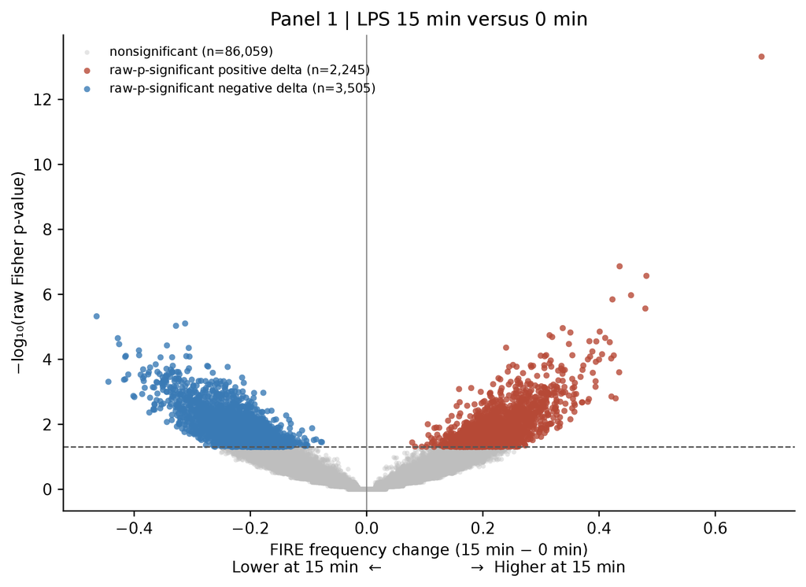

```python
fig, ax = plt.subplots(figsize=(8.4, 5.5))
volcano_colors = {'nonsignificant': '#bdbdbd',
                  'raw-p-significant positive delta': '#b64936',
                  'raw-p-significant negative delta': '#397ab5'}
for label, color in volcano_colors.items():
    points = volcano_data.loc[volcano_data['significance_class'].eq(label)]
    ax.scatter(points['delta_freq_15_minus_0'], points['minus_log10_raw_p'],
               s=9 if label == 'nonsignificant' else 15,
               alpha=0.4 if label == 'nonsignificant' else 0.8,
               color=color, linewidths=0, label=f'{label} (n={len(points):,})')
ax.axhline(-np.log10(raw_p_threshold), color='#555555', linestyle='--', linewidth=0.9)
ax.axvline(0, color='#888888', linewidth=0.7)
ax.set(xlabel='FIRE frequency change (15 min − 0 min)\nLower at 15 min  ←                  →  Higher at 15 min',
       ylabel='−log₁₀(raw Fisher p-value)', title='Panel 1 | LPS 15 min versus 0 min')
ax.legend(frameon=False, fontsize=8, loc='upper left')
show_pdf_figure(fig, plots_dir / 'panel1_volcano_LPS_0_vs_LPS_15.pdf')
```

### Prepare differential and background FIREs

Differential FIRE regions: p < 0.05 - regions whose FIRE frequency differs between 0 and 15 min

Background FIRE regions: p > 0.05 - regions without evidence of a FIRE-frequency difference between 0 and 15 min

```python
pairwise_fire_regions_differential = pairwise_0_15.loc[pairwise_0_15['p_value'].lt(raw_p_threshold)].copy()
pairwise_fire_regions_background = pairwise_0_15.loc[pairwise_0_15['p_value'].gt(raw_p_threshold)].copy()
unique_differential_FIRE_regions = pairwise_fire_regions_differential[['chrom', 'start', 'end']].drop_duplicates().copy()
unique_background_FIRE_regions = pairwise_fire_regions_background[['chrom', 'start', 'end']].drop_duplicates().copy()
assert set(pairwise_fire_regions_differential['region_id']).isdisjoint(pairwise_fire_regions_background['region_id'])
assert len(unique_differential_FIRE_regions) and len(unique_background_FIRE_regions)
print(f'Differential FIREs: {len(pairwise_fire_regions_differential):,}')
print(f'Background FIREs: {len(pairwise_fire_regions_background):,}')
print(f'Regions exactly at p = 0.05, excluded from both motif groups: {pairwise_0_15["p_value"].eq(0.05).sum():,}')
display(pairwise_fire_regions_differential.head())
display(pairwise_fire_regions_background.head())
for group, table in [('differential', pairwise_fire_regions_differential),
                     ('background', pairwise_fire_regions_background)]:
    remember_table(f'{group}_FIREs_LPS_0_vs_LPS_15.tsv', table, sep='\t', index=False)
```

|  | chrom | start | end | region_id | comparison | n_reads_A | n_fire_A | freq_A | n_reads_B | n_fire_B | freq_B | delta_freq | log2_or | p_value | rank_p | pass_coverage | freq_0 | freq_15 | delta_freq_15_minus_0 |
| --- | --- | --- | --- | --- | --- | --- | --- | --- | --- | --- | --- | --- | --- | --- | --- | --- | --- | --- | --- |
| 286192 | chr1 | 940874 | 941024 | chr1:940874-941024 | LPS_0_vs_LPS_15 | 39 | 5 | 0.128205 | 37 | 14 | 0.378378 | 0.250173 | 1.952485 | 0.016750 | 2242.0 | True | 0.128205 | 0.378378 | 0.250173 |
| 286200 | chr1 | 984253 | 984401 | chr1:984253-984401 | LPS_0_vs_LPS_15 | 38 | 16 | 0.421053 | 70 | 45 | 0.642857 | 0.221805 | 1.282828 | 0.041447 | 4852.0 | True | 0.421053 | 0.642857 | 0.221805 |
| 286226 | chr1 | 1104238 | 1104488 | chr1:1104238-1104488 | LPS_0_vs_LPS_15 | 49 | 13 | 0.265306 | 53 | 26 | 0.490566 | 0.225260 | 1.381498 | 0.025138 | 3127.0 | True | 0.265306 | 0.490566 | 0.225260 |
| 286235 | chr1 | 1201433 | 1201620 | chr1:1201433-1201620 | LPS_0_vs_LPS_15 | 28 | 2 | 0.071429 | 40 | 14 | 0.350000 | 0.278571 | 2.536053 | 0.008944 | 1304.0 | True | 0.071429 | 0.350000 | 0.278571 |
| 286238 | chr1 | 1208048 | 1208288 | chr1:1208048-1208288 | LPS_0_vs_LPS_15 | 33 | 22 | 0.666667 | 39 | 34 | 0.871795 | 0.205128 | 1.680802 | 0.048502 | 5591.0 | True | 0.666667 | 0.871795 | 0.205128 |

|  | chrom | start | end | region_id | comparison | n_reads_A | n_fire_A | freq_A | n_reads_B | n_fire_B | freq_B | delta_freq | log2_or | p_value | rank_p | pass_coverage | freq_0 | freq_15 | delta_freq_15_minus_0 |
| --- | --- | --- | --- | --- | --- | --- | --- | --- | --- | --- | --- | --- | --- | --- | --- | --- | --- | --- | --- |
| 286152 | chr1 | 191690 | 191947 | chr1:191690-191947 | LPS_0_vs_LPS_15 | 45 | 16 | 0.355556 | 37 | 10 | 0.270270 | -0.085285 | -0.550793 | 0.478795 | 42365.0 | True | 0.355556 | 0.270270 | -0.085285 |
| 286163 | chr1 | 605049 | 605189 | chr1:605049-605189 | LPS_0_vs_LPS_15 | 32 | 3 | 0.093750 | 35 | 8 | 0.228571 | 0.134821 | 1.381391 | 0.191406 | 18670.0 | True | 0.093750 | 0.228571 | 0.134821 |
| 286164 | chr1 | 605205 | 605324 | chr1:605205-605324 | LPS_0_vs_LPS_15 | 35 | 8 | 0.228571 | 35 | 7 | 0.200000 | -0.028571 | -0.232103 | 1.000000 | 78835.0 | True | 0.228571 | 0.200000 | -0.028571 |
| 286165 | chr1 | 605431 | 605663 | chr1:605431-605663 | LPS_0_vs_LPS_15 | 32 | 21 | 0.656250 | 34 | 22 | 0.647059 | -0.009191 | -0.054706 | 1.000000 | 78835.0 | True | 0.656250 | 0.647059 | -0.009191 |
| 286166 | chr1 | 638325 | 638529 | chr1:638325-638529 | LPS_0_vs_LPS_15 | 48 | 11 | 0.229167 | 68 | 23 | 0.338235 | 0.109069 | 0.752051 | 0.221612 | 21199.0 | True | 0.229167 | 0.338235 | 0.109069 |

|  | chrom | start | end | region_id | comparison | n_reads_A | n_fire_A | freq_A | n_reads_B | n_fire_B | freq_B | delta_freq | log2_or | p_value | rank_p | pass_coverage | freq_0 | freq_15 | delta_freq_15_minus_0 |
| --- | --- | --- | --- | --- | --- | --- | --- | --- | --- | --- | --- | --- | --- | --- | --- | --- | --- | --- | --- |
| 286192 | chr1 | 940874 | 941024 | chr1:940874-941024 | LPS_0_vs_LPS_15 | 39 | 5 | 0.128205 | 37 | 14 | 0.378378 | 0.250173 | 1.952485 | 0.016750 | 2242.0 | True | 0.128205 | 0.378378 | 0.250173 |
| 286200 | chr1 | 984253 | 984401 | chr1:984253-984401 | LPS_0_vs_LPS_15 | 38 | 16 | 0.421053 | 70 | 45 | 0.642857 | 0.221805 | 1.282828 | 0.041447 | 4852.0 | True | 0.421053 | 0.642857 | 0.221805 |
| 286226 | chr1 | 1104238 | 1104488 | chr1:1104238-1104488 | LPS_0_vs_LPS_15 | 49 | 13 | 0.265306 | 53 | 26 | 0.490566 | 0.225260 | 1.381498 | 0.025138 | 3127.0 | True | 0.265306 | 0.490566 | 0.225260 |
| 286235 | chr1 | 1201433 | 1201620 | chr1:1201433-1201620 | LPS_0_vs_LPS_15 | 28 | 2 | 0.071429 | 40 | 14 | 0.350000 | 0.278571 | 2.536053 | 0.008944 | 1304.0 | True | 0.071429 | 0.350000 | 0.278571 |
| 286238 | chr1 | 1208048 | 1208288 | chr1:1208048-1208288 | LPS_0_vs_LPS_15 | 33 | 22 | 0.666667 | 39 | 34 | 0.871795 | 0.205128 | 1.680802 | 0.048502 | 5591.0 | True | 0.666667 | 0.871795 | 0.205128 |

|  | chrom | start | end | region_id | comparison | n_reads_A | n_fire_A | freq_A | n_reads_B | n_fire_B | freq_B | delta_freq | log2_or | p_value | rank_p | pass_coverage | freq_0 | freq_15 | delta_freq_15_minus_0 |
| --- | --- | --- | --- | --- | --- | --- | --- | --- | --- | --- | --- | --- | --- | --- | --- | --- | --- | --- | --- |
| 286152 | chr1 | 191690 | 191947 | chr1:191690-191947 | LPS_0_vs_LPS_15 | 45 | 16 | 0.355556 | 37 | 10 | 0.270270 | -0.085285 | -0.550793 | 0.478795 | 42365.0 | True | 0.355556 | 0.270270 | -0.085285 |
| 286163 | chr1 | 605049 | 605189 | chr1:605049-605189 | LPS_0_vs_LPS_15 | 32 | 3 | 0.093750 | 35 | 8 | 0.228571 | 0.134821 | 1.381391 | 0.191406 | 18670.0 | True | 0.093750 | 0.228571 | 0.134821 |
| 286164 | chr1 | 605205 | 605324 | chr1:605205-605324 | LPS_0_vs_LPS_15 | 35 | 8 | 0.228571 | 35 | 7 | 0.200000 | -0.028571 | -0.232103 | 1.000000 | 78835.0 | True | 0.228571 | 0.200000 | -0.028571 |
| 286165 | chr1 | 605431 | 605663 | chr1:605431-605663 | LPS_0_vs_LPS_15 | 32 | 21 | 0.656250 | 34 | 22 | 0.647059 | -0.009191 | -0.054706 | 1.000000 | 78835.0 | True | 0.656250 | 0.647059 | -0.009191 |
| 286166 | chr1 | 638325 | 638529 | chr1:638325-638529 | LPS_0_vs_LPS_15 | 48 | 11 | 0.229167 | 68 | 23 | 0.338235 | 0.109069 | 0.752051 | 0.221612 | 21199.0 | True | 0.229167 | 0.338235 | 0.109069 |

### motif enrichment

For Panel 2, we compare motif presence in raw-p differential FIREs with raw-p nonsignificant FIREs from this comparison.

```python
import io
import re
import json
import hashlib
import xml.etree.ElementTree as ET
from scipy import sparse
from scipy.stats import fisher_exact

analysis_root = project_root / 'macrophage_project/fire_frequency'
fasta_root = analysis_root / 'FIRE_region_fasta'  # Existing scan inputs are read only.
fimo_root = analysis_root / 'tf_motif'  # Existing FIMO outputs are read only.
motif_database = Path('/project/spott/cshan/annotations/JASPAR2026_CORE_vertebrates_non-redundant_pfms_meme.txt')
fimo_threshold = 1e-4
fdr_threshold = 0.05
top_n = 100
fasta_headers_use_bed_start = True
print('Motif test: two-sided Fisher on regions with/without ≥1 footprint-supported motif hit (>=50% motif overlap), including zero-hit motifs.')
print('BH correction includes every expression-eligible motif; both FIRE directions are pooled.')
print('Background: pass_coverage and raw p > 0.05 in LPS_0_vs_LPS_15 only.')
```

read JASPAR motif names and probability matrices

inspect the motif database and save the motif labels for the count matrices

```python
def read_meme_database(path):
    """Return motif annotations and A/C/G/T position-probability matrices."""
    lines = Path(path).read_text().splitlines()
    rows, matrices = [], {}
    motif_id = tf_name = None
    for i, line in enumerate(lines):
        if line.startswith('MOTIF '):
            fields = line.split(maxsplit=2)
            motif_id = fields[1]
            tf_name = fields[2] if len(fields) > 2 else motif_id
        elif line.startswith('letter-probability matrix:'):
            width = int(re.search(r'\bw=\s*(\d+)', line).group(1))
            matrix = np.array([list(map(float, row.split()))
                               for row in lines[i + 1:i + 1 + width]])
            if matrix.shape != (width, 4) or np.any(matrix < 0):
                raise ValueError(f'Invalid ACGT matrix: {motif_id}')
            if not np.allclose(matrix.sum(axis=1), 1, atol=1e-4):
                raise ValueError(f'Probability rows do not sum to 1: {motif_id}')
            if motif_id in matrices:
                raise ValueError(f'Duplicate motif ID: {motif_id}')
            matrices[motif_id] = matrix / matrix.sum(axis=1, keepdims=True)
            rows.append({'motif_id': motif_id, 'TF': tf_name, 'width': width})
    if not rows:
        raise ValueError(f'No motifs found in {path}')
    return pd.DataFrame(rows), matrices

motif_annotations, motif_probabilities = read_meme_database(motif_database)
motif_ids = motif_annotations['motif_id'].tolist()
remember_table('motif_to_tf.tsv', motif_annotations, sep='\t', index=False)
print(f'{len(motif_annotations):,}  motif profiles loaded.')
display(motif_annotations.head(10))
```

|  | motif_id | TF | width |
| --- | --- | --- | --- |
| 0 | MA0004.1 | Arnt | 6 |
| 1 | MA0069.1 | PAX6 | 14 |
| 2 | MA0071.1 | RORA | 10 |
| 3 | MA0074.1 | RXRA::VDR | 15 |
| 4 | MA0101.1 | REL | 10 |

|  | motif_id | TF | width |
| --- | --- | --- | --- |
| 0 | MA0004.1 | Arnt | 6 |
| 1 | MA0069.1 | PAX6 | 14 |
| 2 | MA0071.1 | RORA | 10 |
| 3 | MA0074.1 | RXRA::VDR | 15 |
| 4 | MA0101.1 | REL | 10 |
| 5 | MA0107.1 | RELA | 10 |
| 6 | MA0111.1 | Spz1 | 11 |
| 7 | MA0115.1 | NR1H2::RXRA | 17 |
| 8 | MA0119.1 | NFIC::TLX1 | 14 |
| 9 | MA0130.1 | ZNF354C | 6 |

keep the RNA-seq sources and require mean CPM of at least five at one of the four macrophage timepoints

```python
import io
rna_aligned_dir = Path('/project/spott/lizarraga/pacbio_analysis/macrophage_project/rna_seq/aligned')
rna_sample_sheet = rna_aligned_dir / 'sample_names.txt'
rna_gene_gtf = Path('/project/spott/lizarraga/human_references/gencode.v46.annotation.gtf')
expression_cpm_threshold = 5.0
expression_comparison = '>='
star_count_column = 'reverse'
expected_timepoints = [0, 5, 10, 15]

tf_alias_overrides = {}
```

checks the RNA sample sheet and its three replicates at each timepoint.

```python
def read_rna_sample_sheet(path, aligned_dir):
    """Read sample/replicate/time metadata"""

    text = Path(path).read_text().replace('\\t', '\t')
    samples = pd.read_csv(io.StringIO(text), sep='\t', dtype=str)
    samples.columns = samples.columns.str.strip()
    required = ['FILE NAME', 'REPLICATE', 'TIME']
    if not set(required) <= set(samples.columns):
        raise ValueError(f'Unexpected sample-sheet columns: {samples.columns.tolist()}')
    samples = samples[required].rename(columns={'FILE NAME': 'sample', 'REPLICATE': 'replicate', 'TIME': 'time_min'})
    for column in ['sample', 'replicate']:
        samples[column] = samples[column].str.strip()
    samples['time_min'] = pd.to_numeric(samples['time_min'].str.strip(), errors='raise').astype(int)
    samples = samples.loc[samples['time_min'].isin(expected_timepoints)].copy()
    if samples.isna().any().any() or samples['sample'].duplicated().any() or samples.duplicated(['time_min', 'replicate']).any():
        raise ValueError('Missing or duplicate sample/replicate/time entries')
    if sorted(samples['time_min'].unique()) != expected_timepoints:
        raise ValueError('RNA-seq time points do not match the configured time course')
    if not (samples.groupby('time_min').size() == 3).all():
        raise ValueError('Expected three biological replicates at every time point')
    samples['count_file'] = [str(aligned_dir / sample / f'{sample}_ReadsPerGene.out.tab')
                             for sample in samples['sample']]
    missing = [p for p in samples['count_file'] if not Path(p).is_file()]
    if missing:
        raise FileNotFoundError(f'Missing STAR counts: {missing}')
    return samples.sort_values(['time_min', 'replicate']).reset_index(drop=True)
```

```python
rna_samples = read_rna_sample_sheet(rna_sample_sheet, rna_aligned_dir)
remember_table('rna_samples.tsv', rna_samples, sep='\t', index=False)
```

|  | sample | replicate | time_min | count_file |
| --- | --- | --- | --- | --- |
| 0 | SP-AL-18s-R10_S1 | R1 | 0 | /project/spott/lizarraga/pacbio_analysis/macro... |
| 1 | SP-AL-18s-R20_S7 | R2 | 0 | /project/spott/lizarraga/pacbio_analysis/macro... |
| 2 | SP-AL-18s-R30_S13 | R3 | 0 | /project/spott/lizarraga/pacbio_analysis/macro... |
| 3 | SP-AL-18s-R15_S5 | R1 | 5 | /project/spott/lizarraga/pacbio_analysis/macro... |
| 4 | SP-AL-18s-R25_S11 | R2 | 5 | /project/spott/lizarraga/pacbio_analysis/macro... |

reads the original STAR gene counts and checks library strandedness.

```python
def load_star_gene_counts(samples, count_column='reverse'):
    """Load gene counts in a consistent order and inspect strandedness per sample."""
    counts = {}
    qc_rows = []
    reference_ids = None
    for row in samples.itertuples(index=False):
        data = pd.read_csv(row.count_file, sep='\t', header=None,
                           names=['gene_id', 'unstranded', 'forward', 'reverse'])
        genes = data.loc[~data['gene_id'].str.startswith('N_')].set_index('gene_id')
        if genes.index.has_duplicates or genes.empty:
            raise ValueError(f'{row.sample}: duplicate or absent gene IDs')
        values = genes.to_numpy(dtype=float)
        if not np.isfinite(values).all() or (values < 0).any() or not np.equal(values, np.floor(values)).all():
            raise ValueError(f'{row.sample}: invalid STAR counts')
        if reference_ids is None:
            reference_ids = genes.index
        if set(genes.index) != set(reference_ids):
            raise ValueError(f'{row.sample}: different gene inventory')
        genes = genes.reindex(reference_ids)
        sums = genes.sum()
        if sums[count_column] <= 0:
            raise ValueError(f'{row.sample}: zero assigned counts')
        if count_column == 'reverse' and sums['reverse'] <= sums['forward']:
            raise ValueError(f'{row.sample}: reverse-stranded counts do not dominate; inspect library strandedness')
        counts[row.sample] = genes[count_column].astype(np.int64)
        qc_rows.append({'sample': row.sample, 'time_min': row.time_min,
                        'unstranded_assigned': int(sums['unstranded']),
                        'forward_assigned': int(sums['forward']),
                        'reverse_assigned': int(sums['reverse']),
                        'reverse_to_forward_ratio': sums['reverse'] / max(1, sums['forward'])})
    return pd.DataFrame(counts), pd.DataFrame(qc_rows)
```

We load the RNA libraries and inspect their counts and strandedness.

```python
# Read RNA sample metadata and load STAR gene counts
rna_samples = read_rna_sample_sheet(rna_sample_sheet, rna_aligned_dir)
rna_counts, rna_count_qc = load_star_gene_counts(rna_samples, star_count_column)
print(f'Loaded {rna_counts.shape[0]:,} genes from {rna_counts.shape[1]} RNA-seq libraries.')
remember_table('rna_count_qc.tsv', rna_count_qc, sep='\t', index=False)
```

|  | sample | time_min | unstranded_assigned | forward_assigned | reverse_assigned | reverse_to_forward_ratio |
| --- | --- | --- | --- | --- | --- | --- |
| 0 | SP-AL-18s-R10_S1 | 0 | 63323256 | 5122178 | 66993670 | 13.079137 |
| 1 | SP-AL-18s-R20_S7 | 0 | 55163858 | 5043428 | 58347442 | 11.569005 |
| 2 | SP-AL-18s-R30_S13 | 0 | 54335352 | 4857458 | 57502710 | 11.838025 |
| 3 | SP-AL-18s-R15_S5 | 5 | 52972613 | 4371905 | 55970571 | 12.802330 |
| 4 | SP-AL-18s-R25_S11 | 5 | 51880572 | 4578249 | 54813913 | 11.972681 |

maps the RNA gene identifiers to the GENCODE v46 gene symbols

```python
def read_gtf_gene_symbols(path):
    """Stream gene features from the alignment GTF; do not load all exon records."""
    records = []
    with Path(path).open() as handle:
        for line in handle:
            if line.startswith('#'):
                continue
            fields = line.rstrip('\n').split('\t', 8)
            if len(fields) != 9 or fields[2] != 'gene':
                continue
            attrs = dict(re.findall(r'(\w+) "([^"]*)"', fields[8]))
            if 'gene_id' in attrs and 'gene_name' in attrs:
                records.append({'gene_id': attrs['gene_id'], 'gene_name': attrs['gene_name'],
                                'gene_type': attrs.get('gene_type', '')})
    annotation = pd.DataFrame(records)
    if annotation.empty or annotation['gene_id'].duplicated().any():
        raise ValueError('Empty GTF annotation or ambiguous duplicate gene IDs')
    return annotation
```

GENCODE symbols that match the count matrix

```python
rna_gene_annotation = read_gtf_gene_symbols(rna_gene_gtf)
```

calculates CPM within each library and averages the replicates at each timepoint

```python
def average_gene_expression_by_time(counts, samples, annotation):
    """Normalize each library to CPM, sum gene IDs by symbol, then average replicates."""
    symbols = annotation.set_index('gene_id')['gene_name'].reindex(counts.index)
    matched = symbols.notna()
    if not matched.any():
        raise ValueError('No exact gene IDs match the RNA-seq GTF')
    library_sizes = counts.sum(axis=0)
    gene_cpm = counts.divide(library_sizes, axis=1) * 1e6
    symbol_cpm = gene_cpm.loc[matched].groupby(symbols.loc[matched], sort=True).sum()
    sample_time = samples.set_index('sample')['time_min']
    mean_cpm = symbol_cpm.T.groupby(sample_time.reindex(symbol_cpm.columns)).mean().T
    mean_cpm = mean_cpm.reindex(columns=expected_timepoints)
    mean_cpm.index.name = 'gene_name'
    mean_cpm.columns.name = 'time_min'
    return symbol_cpm, mean_cpm, symbols.loc[~matched].index.tolist()
```

```python
gene_sample_cpm, gene_time_mean_cpm, unannotated_rna_genes = average_gene_expression_by_time(
    rna_counts, rna_samples, rna_gene_annotation
)
remember_table('gene_mean_cpm_by_time.tsv', gene_time_mean_cpm, sep='\t')
remember_table('rna_genes_without_symbol.tsv', pd.Series(unannotated_rna_genes, name='gene_id'), sep='\t', index=False)
print(f'{len(gene_time_mean_cpm):,} gene symbols; {len(unannotated_rna_genes)} count IDs without annotation.')
print('Inspecting mean CPM for representative macrophage TFs:')
representative_tfs = [gene for gene in ['SPI1', 'CEBPB', 'JUN', 'FOS', 'RELA', 'NFKB1', 'IRF1']
                      if gene in gene_time_mean_cpm.index]
display(gene_time_mean_cpm.loc[representative_tfs].round(2))
```

| time_min gene_name | 0 | 5 | 10 | 15 |
| --- | --- | --- | --- | --- |
| 5S_rRNA | 0.010772 | 0.000000 | 0.011754 | 0.021021 |
| 5_8S_rRNA | 0.000000 | 0.000000 | 0.000000 | 0.000000 |
| 7SK | 0.034613 | 0.030029 | 0.048497 | 0.021777 |
| A1BG | 0.543350 | 0.673085 | 0.600501 | 0.592975 |
| A1BG-AS1 | 26.571318 | 25.505082 | 25.105620 | 25.687975 |

```
Series([], Name: gene_id, dtype: object)
```

| time_min gene_name | 0 | 5 | 10 | 15 |
| --- | --- | --- | --- | --- |
| SPI1 | 198.49 | 189.94 | 191.12 | 191.34 |
| CEBPB | 92.68 | 90.65 | 95.67 | 88.04 |
| JUN | 250.84 | 243.64 | 271.96 | 335.41 |
| FOS | 46.48 | 46.73 | 50.98 | 68.08 |
| RELA | 81.05 | 80.87 | 78.92 | 83.57 |
| NFKB1 | 67.95 | 68.03 | 65.69 | 67.06 |
| IRF1 | 69.72 | 69.08 | 66.04 | 69.93 |

filter for TF that is expressed in the data with CPM ≥ 5 in at least one included time point. For complexes, every component must meet the threshold in the same time point

```python
def annotate_motif_expression(motif_table, mean_cpm, threshold=5.0):
    """Match TF components and require expression at a common time point for complexes."""
    symbol_lookup = {}
    for symbol in mean_cpm.index:
        symbol_lookup.setdefault(symbol.upper(), []).append(symbol)
    rows, components = [], []
    for row in motif_table.itertuples(index=False):
        labels = [re.sub(r'\s*\(var\.\d+\)$', '', label).strip() for label in row.TF.split('::')]
        resolved, unmapped = [], []
        for label in labels:
            query = tf_alias_overrides.get(label, label)
            candidates = symbol_lookup.get(query.upper(), [])
            symbol = candidates[0] if len(candidates) == 1 else None
            if symbol is None:
                unmapped.append(label)
            else:
                resolved.append(symbol)
            components.append({'motif_id': row.motif_id, 'TF': row.TF, 'component': label,
                               'gene_name': symbol,
                               'mapping': 'explicit alias' if symbol and label in tf_alias_overrides
                               else 'symbol (case-insensitive)' if symbol else 'unmapped or ambiguous'})
        if unmapped:
            values = pd.Series(np.nan, index=mean_cpm.columns)
            passed = pd.Series(False, index=mean_cpm.columns)
            mapping_status = 'partially mapped' if resolved else 'unmapped'
        else:
            # For complexes this is the least-expressed component at each time
            values = mean_cpm.loc[resolved].min(axis=0)
            passed = values.ge(threshold) if expression_comparison == '>=' else values.gt(threshold)
            mapping_status = 'mapped'
        record = {'motif_id': row.motif_id, 'TF': row.TF,
                  'tf_genes': ';'.join(dict.fromkeys(resolved)),
                  'unmapped_components': ';'.join(unmapped), 'mapping_status': mapping_status,
                  'expressed_any_time': bool(passed.any()),
                  'expressed_timepoints': ';'.join(str(t) for t in mean_cpm.columns[passed]),
                  'max_component_min_mean_cpm': values.max()}
        record.update({f'mean_cpm_{time}min': value for time, value in values.items()})
        rows.append(record)
    return pd.DataFrame(rows), pd.DataFrame(components)
```

apply the expression filter and inspect the eligible motifs and any unmapped TF names.

```python
motif_expression, motif_tf_components = annotate_motif_expression(
    motif_annotations, gene_time_mean_cpm, expression_cpm_threshold
)
remember_table('motif_tf_expression_filter.tsv', motif_expression, sep='\t', index=False)
remember_table('motif_tf_gene_mapping.tsv', motif_tf_components, sep='\t', index=False)
remember_table('motifs_with_unmapped_tf_labels.tsv', motif_expression.loc[motif_expression['mapping_status'] != 'mapped'], sep='\t', index=False)
mapped_tf_genes = sorted(set(motif_tf_components['gene_name'].dropna()))
remember_table('tf_cpm_by_replicate.tsv', gene_sample_cpm.loc[mapped_tf_genes], sep='\t')
remember_table('tf_mean_cpm_by_time.tsv', gene_time_mean_cpm.loc[mapped_tf_genes], sep='\t')
print(f'{motif_expression["expressed_any_time"].sum():,} of {len(motif_expression):,} motifs pass the expression filter.')
display(motif_expression.groupby(['mapping_status', 'expressed_any_time']).size().rename('motifs').to_frame())
display(motif_expression.loc[motif_expression['expressed_any_time']].head(10))
print('Unmapped TFs:')
display(motif_expression.loc[motif_expression['mapping_status'] != 'mapped',
                              ['motif_id', 'TF', 'unmapped_components']].head(20))
```

|  | motif_id | TF | tf_genes | unmapped_components | mapping_status | expressed_any_time | expressed_timepoints | max_component_min_mean_cpm | mean_cpm_0min | mean_cpm_5min | mean_cpm_10min | mean_cpm_15min |
| --- | --- | --- | --- | --- | --- | --- | --- | --- | --- | --- | --- | --- |
| 0 | MA0004.1 | Arnt | ARNT |  | mapped | True | 0;5;10;15 | 88.753619 | 87.022900 | 87.492756 | 84.512927 | 88.753619 |
| 1 | MA0069.1 | PAX6 | PAX6 |  | mapped | False |  | 0.142613 | 0.124359 | 0.142613 | 0.127886 | 0.089200 |
| 2 | MA0071.1 | RORA | RORA |  | mapped | False |  | 0.224233 | 0.187135 | 0.179372 | 0.224233 | 0.176997 |
| 3 | MA0074.1 | RXRA::VDR | RXRA;VDR |  | mapped | True | 0;5;10;15 | 12.685174 | 12.533401 | 11.668266 | 12.685174 | 11.967121 |
| 4 | MA0101.1 | REL | REL |  | mapped | True | 0;5;10;15 | 22.800974 | 20.995554 | 21.641931 | 21.288950 | 22.800974 |

|  | motif_id | TF | component | gene_name | mapping |
| --- | --- | --- | --- | --- | --- |
| 0 | MA0004.1 | Arnt | Arnt | ARNT | symbol (case-insensitive) |
| 1 | MA0069.1 | PAX6 | PAX6 | PAX6 | symbol (case-insensitive) |
| 2 | MA0071.1 | RORA | RORA | RORA | symbol (case-insensitive) |
| 3 | MA0074.1 | RXRA::VDR | RXRA | RXRA | symbol (case-insensitive) |
| 4 | MA0074.1 | RXRA::VDR | VDR | VDR | symbol (case-insensitive) |

|  | motif_id | TF | tf_genes | unmapped_components | mapping_status | expressed_any_time | expressed_timepoints | max_component_min_mean_cpm | mean_cpm_0min | mean_cpm_5min | mean_cpm_10min | mean_cpm_15min |
| --- | --- | --- | --- | --- | --- | --- | --- | --- | --- | --- | --- | --- |
| 11 | MA0149.1 | EWSR1-FLI1 |  | EWSR1-FLI1 | unmapped | False |  | NaN | NaN | NaN | NaN | NaN |
| 166 | MA2125.1 | Zfp809 |  | Zfp809 | unmapped | False |  | NaN | NaN | NaN | NaN | NaN |
| 167 | MA2126.1 | Zfp961 |  | Zfp961 | unmapped | False |  | NaN | NaN | NaN | NaN | NaN |
| 218 | MA0603.2 | Arntl |  | Arntl | unmapped | False |  | NaN | NaN | NaN | NaN | NaN |
| 291 | MA0611.3 | Dux |  | Dux | unmapped | False |  | NaN | NaN | NaN | NaN | NaN |

| gene_name | SP-AL-18s-R10_S1 | SP-AL-18s-R20_S7 | SP-AL-18s-R30_S13 | SP-AL-18s-R15_S5 | SP-AL-18s-R25_S11 | SP-AL-18s-R35_S17 | SP-AL-18s-R110_S2 | SP-AL-18s-R210_S8 | SP-AL-18s-R310_S14 | SP-AL-18s-R115_S3 | SP-AL-18s-R215_S9 | SP-AL-18s-R315_S15 |
| --- | --- | --- | --- | --- | --- | --- | --- | --- | --- | --- | --- | --- |
| AHR | 25.957676 | 23.308648 | 23.094564 | 24.584348 | 23.461197 | 24.177287 | 24.370684 | 25.807221 | 25.579149 | 29.681720 | 24.213704 | 23.279156 |
| ALX1 | 4.881058 | 4.576036 | 4.712821 | 4.931163 | 4.688591 | 4.349815 | 4.058814 | 4.702097 | 5.063449 | 4.274813 | 4.892283 | 5.661909 |
| ALX3 | 0.000000 | 0.000000 | 0.000000 | 0.000000 | 0.000000 | 0.017469 | 0.000000 | 0.000000 | 0.000000 | 0.000000 | 0.000000 | 0.000000 |
| ALX4 | 0.507511 | 0.668410 | 0.434762 | 0.535996 | 0.401358 | 0.489136 | 0.569658 | 0.698331 | 0.768247 | 0.580729 | 0.557349 | 0.544414 |
| AR | 97.636090 | 92.977512 | 105.334166 | 85.330557 | 102.236817 | 99.643962 | 86.267592 | 107.605091 | 104.429279 | 91.884281 | 90.951050 | 99.279396 |

| time_min gene_name | 0 | 5 | 10 | 15 |
| --- | --- | --- | --- | --- |
| AHR | 24.120296 | 24.074277 | 25.252351 | 25.724860 |
| ALX1 | 4.723305 | 4.656523 | 4.608120 | 4.943002 |
| ALX3 | 0.000000 | 0.005823 | 0.000000 | 0.000000 |
| ALX4 | 0.536894 | 0.475497 | 0.678746 | 0.560831 |
| AR | 98.649256 | 95.737112 | 99.433987 | 94.038242 |

| mapping_status | expressed_any_time | motifs |
| --- | --- | --- |
| mapped | False | 495 |
|  | True | 514 |
| unmapped | False | 10 |

|  | motif_id | TF | tf_genes | unmapped_components | mapping_status | expressed_any_time | expressed_timepoints | max_component_min_mean_cpm | mean_cpm_0min | mean_cpm_5min | mean_cpm_10min | mean_cpm_15min |
| --- | --- | --- | --- | --- | --- | --- | --- | --- | --- | --- | --- | --- |
| 0 | MA0004.1 | Arnt | ARNT |  | mapped | True | 0;5;10;15 | 88.753619 | 87.022900 | 87.492756 | 84.512927 | 88.753619 |
| 3 | MA0074.1 | RXRA::VDR | RXRA;VDR |  | mapped | True | 0;5;10;15 | 12.685174 | 12.533401 | 11.668266 | 12.685174 | 11.967121 |
| 4 | MA0101.1 | REL | REL |  | mapped | True | 0;5;10;15 | 22.800974 | 20.995554 | 21.641931 | 21.288950 | 22.800974 |
| 5 | MA0107.1 | RELA | RELA |  | mapped | True | 0;5;10;15 | 83.567722 | 81.048324 | 80.865040 | 78.924501 | 83.567722 |
| 7 | MA0115.1 | NR1H2::RXRA | NR1H2;RXRA |  | mapped | True | 0;5;10;15 | 60.970686 | 60.970686 | 58.691882 | 58.960923 | 57.742821 |
| 9 | MA0130.1 | ZNF354C | ZNF354C |  | mapped | True | 0;5;10;15 | 12.934087 | 11.986869 | 12.527465 | 11.923325 | 12.934087 |
| 12 | MA0151.1 | Arid3a | ARID3A |  | mapped | True | 0;5;10;15 | 92.283446 | 92.283446 | 88.205788 | 91.925580 | 85.898789 |
| 14 | MA0159.1 | RARA::RXRA | RARA;RXRA |  | mapped | True | 0;5;10;15 | 53.698033 | 53.698033 | 49.971569 | 52.397784 | 50.726159 |
| 15 | MA0163.1 | PLAG1 | PLAG1 |  | mapped | True | 0;5;10;15 | 12.718949 | 11.154906 | 12.199886 | 11.199160 | 12.718949 |
| 20 | MA0595.1 | SREBF1 | SREBF1 |  | mapped | True | 0;5;10;15 | 46.057316 | 45.196800 | 46.057316 | 43.424078 | 43.285739 |

|  | motif_id | TF | unmapped_components |
| --- | --- | --- | --- |
| 11 | MA0149.1 | EWSR1-FLI1 | EWSR1-FLI1 |
| 166 | MA2125.1 | Zfp809 | Zfp809 |
| 167 | MA2126.1 | Zfp961 | Zfp961 |
| 218 | MA0603.2 | Arntl | Arntl |
| 291 | MA0611.3 | Dux | Dux |
| 552 | MA0621.2 | mix-a | mix-a |
| 562 | MA0709.2 | Msx3 | Msx3 |
| 691 | MA0629.2 | Rhox11 | Rhox11 |
| 807 | MA2002.2 | Zfp335 | Zfp335 |
| 1011 | MA2485.1 | Duxbl1 | Duxbl1 |

```python
def load_fire_regions(group):
    """Read sequence inputs and validate unique, nonoverlapping BED intervals."""
    path = fasta_root / f'{group}_FIRE_regions_with_sequences.tsv'
    regions = pd.read_csv(path, sep='\t', usecols=['chrom', 'start', 'end', 'sequence'])
    regions['chrom'] = regions['chrom'].astype(str)
    regions[['start', 'end']] = regions[['start', 'end']].astype('int64')
    regions = regions.sort_values(['chrom', 'start', 'end']).reset_index(drop=True)
    regions['region_id'] = (regions['chrom'] + ':' + regions['start'].astype(str)
                            + '-' + regions['end'].astype(str))
    regions['length'] = regions['end'] - regions['start']
    seq = regions['sequence'].str.upper()
    if regions['region_id'].duplicated().any() or (regions['length'] <= 0).any():
        raise ValueError(f'{group}: duplicate or invalid FIRE intervals')
    if not (seq.str.len() == regions['length']).all():
        raise ValueError(f'{group}: sequence lengths disagree with BED coordinates')
    previous_end = regions.groupby('chrom')['end'].shift()
    if (regions['start'] < previous_end).any():
        raise ValueError(f'{group}: overlapping input intervals require unambiguous FASTA IDs')
    canonical_bases = seq.str.count('[ACGT]')
    regions['gc_fraction'] = seq.str.count('[GC]') / canonical_bases.replace(0, np.nan)

    observed_ids = []
    observed_sequence = []
    expected = regions.set_index('region_id')['sequence'].str.upper().to_dict()
    current_id = None
    with (fasta_root / f'{group}_FIRE_regions.fa').open() as handle:
        for line in handle:
            if line.startswith('>'):
                if current_id is not None and ''.join(observed_sequence).upper() != expected.get(current_id):
                    raise ValueError(f'{group}: FASTA/TSV sequence mismatch at {current_id}')
                current_id = line[1:].strip()
                observed_ids.append(current_id)
                observed_sequence = []
            else:
                observed_sequence.append(line.strip())
    if current_id is not None and ''.join(observed_sequence).upper() != expected.get(current_id):
        raise ValueError(f'{group}: FASTA/TSV sequence mismatch at {current_id}')
    if len(observed_ids) != len(expected) or set(observed_ids) != set(expected):
        raise ValueError(f'{group}: FASTA headers disagree with TSV regions')
    return regions.drop(columns='sequence')
```

```python
def validate_existing_fimo_scan(group, regions):
    xml_path = fimo_root / f'fimo_{group}' / 'fimo.xml'
    xml = ET.parse(xml_path).getroot()
    if any(node.tag.rsplit('}', 1)[-1] == 'incomplete-motif' for node in xml.iter()):
        raise ValueError(f'{group}: the original FIMO scan reports incomplete motif hits')
    settings = {node.attrib['name']: node.text for node in xml.findall('./settings/setting')}
    expected = {
        'MEME file name': str(motif_database),
        'sequence file name': str(fasta_root / f'{group}_FIRE_regions.fa'),
        'background file name': '--nrdb--',
        'parse genomic coord.': 'true',
        'scan both strands': 'true',
        'threshold type': 'p-value',
    }
    for key, value in expected.items():
        if settings.get(key) != value:
            raise ValueError(f'{group}: incompatible original FIMO setting {key}')
    if not np.isclose(float(settings['output threshold']), fimo_threshold):
        raise ValueError(f'{group}: incompatible FIMO hit threshold')
    sequence_data = xml.find('sequence-data')
    if int(sequence_data.attrib['num-sequences']) != len(regions):
        raise ValueError(f'{group}: scan/FASTA sequence counts differ')
    if int(sequence_data.attrib['num-residues']) != int(regions['length'].sum()):
        raise ValueError(f'{group}: scan/FASTA residue counts differ')
    observed = {node.attrib['name']: (node.attrib['alt'], int(node.attrib['width']))
                for node in xml.findall('motif')}
    expected_motifs = {row.motif_id: (row.TF, row.width)
                       for row in motif_annotations.itertuples(index=False)}
    if observed != expected_motifs:
        raise ValueError(f'{group}: scanned motif inventory differs from JASPAR')
    source_settings = json.loads((fimo_root / 'enrichment/tables/analysis_settings.json').read_text())
    if source_settings['motif_database_sha256'] != hashlib.sha256(motif_database.read_bytes()).hexdigest():
        raise ValueError('The JASPAR database has changed since the original analysis')
    return {'group': group, 'source_fimo': str(fimo_root / f'fimo_{group}' / 'fimo.tsv'),
            'source_fasta': settings['sequence file name'], 'scan_version': xml.attrib['version'],
            'scanned_regions': len(regions), 'threshold': float(settings['output threshold']),
            'max_stored_scores': int(settings['max stored scores']), 'incomplete_motifs': 0}

regions_by_group = {group: load_fire_regions(group) for group in ['differential', 'background']}
scan_validation = pd.DataFrame([validate_existing_fimo_scan(group, regions)
                               for group, regions in regions_by_group.items()])
display(scan_validation.head())
```

|  | group | source_fimo | source_fasta | scan_version | scanned_regions | threshold | max_stored_scores | incomplete_motifs |
| --- | --- | --- | --- | --- | --- | --- | --- | --- |
| 0 | differential | /project/spott/cshan/fiber-seq/macrophage_proj... | /project/spott/cshan/fiber-seq/macrophage_proj... | 5.5.9 | 20479 | 0.0001 | 10000000 | 0 |
| 1 | background | /project/spott/cshan/fiber-seq/macrophage_proj... | /project/spott/cshan/fiber-seq/macrophage_proj... | 5.5.9 | 105604 | 0.0001 | 10000000 | 0 |

### Define differential and background FIRE regions

Differential FIRE regions: p < 0.05 - regions whose FIRE frequency differs between 0 and 15 min

Background FIRE regions: p > 0.05 - regions without evidence of a FIRE-frequency difference between 0 and 15 min

```python
target_regions_by_group = {'differential': unique_differential_FIRE_regions,
                           'background': unique_background_FIRE_regions}
analysis_masks = {}
region_summary_rows = []
for group, target in target_regions_by_group.items():
    target_ids = set(target['chrom'].astype(str) + ':' + target['start'].astype(str)
                     + '-' + target['end'].astype(str))
    scanned = regions_by_group[group]
    missing = target_ids - set(scanned['region_id'])
    if missing:
        raise ValueError(f'{group}: {len(missing)} requested FIREs are absent from the existing scan')
    analysis_masks[group] = scanned['region_id'].isin(target_ids).to_numpy()
    selected = scanned.loc[analysis_masks[group]].copy()
    if selected.empty or len(selected) != len(target_ids):
        raise ValueError(f'{group}: empty or incomplete focal region set')
    remember_table(f'{group}_tested_regions.tsv', selected, sep='	', index=False)
    region_summary_rows.append({'group': group, 'scanned_regions': len(scanned),
                                'tested_regions': len(selected),
                                'median_length': selected['length'].median(),
                                'mean_gc_fraction': selected['gc_fraction'].mean()})
    print(f'{group}: {len(selected):,} focal regions from {len(scanned):,} scanned regions')
    display(selected.head())
focal_ids = {group: set(regions.loc[analysis_masks[group], 'region_id'])
             for group, regions in regions_by_group.items()}
assert not (focal_ids['differential'] & focal_ids['background']), 'Motif groups must be disjoint'
region_summary = pd.DataFrame(region_summary_rows)
remember_table('region_summary.tsv', region_summary, sep='	', index=False)
remember_table('fimo_scan_validation.tsv', scan_validation, sep='	', index=False)
display(region_summary.head())
```

|  | chrom | start | end | region_id | length | gc_fraction |
| --- | --- | --- | --- | --- | --- | --- |
| 3 | chr1 | 940874 | 941024 | chr1:940874-941024 | 150 | 0.700000 |
| 4 | chr1 | 984253 | 984401 | chr1:984253-984401 | 148 | 0.750000 |
| 7 | chr1 | 1104238 | 1104488 | chr1:1104238-1104488 | 250 | 0.524000 |
| 8 | chr1 | 1201433 | 1201620 | chr1:1201433-1201620 | 187 | 0.791444 |
| 9 | chr1 | 1208048 | 1208288 | chr1:1208048-1208288 | 240 | 0.595833 |

|  | chrom | start | end | region_id | length | gc_fraction |
| --- | --- | --- | --- | --- | --- | --- |
| 3 | chr1 | 940874 | 941024 | chr1:940874-941024 | 150 | 0.700000 |
| 4 | chr1 | 984253 | 984401 | chr1:984253-984401 | 148 | 0.750000 |
| 7 | chr1 | 1104238 | 1104488 | chr1:1104238-1104488 | 250 | 0.524000 |
| 8 | chr1 | 1201433 | 1201620 | chr1:1201433-1201620 | 187 | 0.791444 |
| 9 | chr1 | 1208048 | 1208288 | chr1:1208048-1208288 | 240 | 0.595833 |

|  | chrom | start | end | region_id | length | gc_fraction |
| --- | --- | --- | --- | --- | --- | --- |
| 2 | chr1 | 191690 | 191947 | chr1:191690-191947 | 257 | 0.583658 |
| 3 | chr1 | 605049 | 605189 | chr1:605049-605189 | 140 | 0.471429 |
| 4 | chr1 | 605205 | 605324 | chr1:605205-605324 | 119 | 0.563025 |
| 5 | chr1 | 605431 | 605663 | chr1:605431-605663 | 232 | 0.646552 |
| 6 | chr1 | 638325 | 638529 | chr1:638325-638529 | 204 | 0.578431 |

|  | chrom | start | end | region_id | length | gc_fraction |
| --- | --- | --- | --- | --- | --- | --- |
| 2 | chr1 | 191690 | 191947 | chr1:191690-191947 | 257 | 0.583658 |
| 3 | chr1 | 605049 | 605189 | chr1:605049-605189 | 140 | 0.471429 |
| 4 | chr1 | 605205 | 605324 | chr1:605205-605324 | 119 | 0.563025 |
| 5 | chr1 | 605431 | 605663 | chr1:605431-605663 | 232 | 0.646552 |
| 6 | chr1 | 638325 | 638529 | chr1:638325-638529 | 204 | 0.578431 |

|  | group | scanned_regions | tested_regions | median_length | mean_gc_fraction |
| --- | --- | --- | --- | --- | --- |
| 0 | differential | 20479 | 5750 | 209.0 | 0.516594 |
| 1 | background | 105604 | 86059 | 207.0 | 0.527824 |

|  | group | source_fimo | source_fasta | scan_version | scanned_regions | threshold | max_stored_scores | incomplete_motifs |
| --- | --- | --- | --- | --- | --- | --- | --- | --- |
| 0 | differential | /project/spott/cshan/fiber-seq/macrophage_proj... | /project/spott/cshan/fiber-seq/macrophage_proj... | 5.5.9 | 20479 | 0.0001 | 10000000 | 0 |
| 1 | background | /project/spott/cshan/fiber-seq/macrophage_proj... | /project/spott/cshan/fiber-seq/macrophage_proj... | 5.5.9 | 105604 | 0.0001 | 10000000 | 0 |

|  | group | scanned_regions | tested_regions | median_length | mean_gc_fraction |
| --- | --- | --- | --- | --- | --- |
| 0 | differential | 20479 | 5750 | 209.0 | 0.516594 |
| 1 | background | 105604 | 86059 | 207.0 | 0.527824 |

### Motif enrichment

Motif presence requires ≥50% of its bases to overlap one 0- or 15-min TF footprint (score ≥50; 10–80 bp; fully within a FIRE element on the same read). All tested regions, including zero supported hits, remain in the Fisher-test denominators. Footprints are pooled across the two timepoints; this tests supported motif presence, not differential occupancy.

**keep only motifs supported by footprints** and builds a FIRE-by-motif count matrix for the differential and background FIRE regions. The resulting matrices are used to perform Fisher's exact test for motif enrichment in differential FIREs versus background FIREs

```python
import importlib.util
support_spec = importlib.util.spec_from_file_location('motif_footprint_overlap', project_root / 'code/fire_frequency/motif_footprint_overlap.py')
footprint_support = importlib.util.module_from_spec(support_spec)
support_spec.loader.exec_module(footprint_support)
from collections import defaultdict
import pysam

def build_footprint_index(project_root, chromosomes, timepoints=(0, 15)):
    """Pool selected timepoints, score>=50, 10..80 bp footprints within same-read FIREs.

    Coordinates are BED (zero-based, half-open). Keep individual intervals;
    merging adjacent footprints could falsely satisfy the motif overlap rule.
    """
    fire_root = Path('/project/spott/lizarraga/pacbio_analysis/macrophage_project/merged_hifi_bams/FIRE')
    tf_root = Path(project_root) / 'macrophage_project/FiberHMM/extract/firehmm_tf'
    result = {}
    for chrom in sorted(chromosomes):
        sources = []
        for time in timepoints:
            sample = f'LPS_{time}'
            sources.append((
                fire_root / sample / f'additional-outputs-v0.1/fire-peaks/{sample}-v0.1-fire-elements.bed.gz',
                tf_root / f'LPS{time}' / f'LPS{time}_hmm_extracted_tf_{chrom}.bed.gz'))
        intervals = set()
        for fire_path, tf_path in sources:
            fires = defaultdict(list)
            with pysam.TabixFile(str(fire_path)) as stream:
                for line in stream.fetch(chrom):
                    fields = line.split('\t')
                    if fields[8] not in ('169,169,169', '147,112,219'):
                        fires[fields[3]].append((int(fields[1]), int(fields[2])))
            with pysam.TabixFile(str(tf_path)) as stream:
                for line in stream.fetch(chrom):
                    fields = line.split('\t')
                    segments = fires.get(fields[3])
                    if not segments:
                        continue
                    sizes = fields[10].rstrip(',').split(',')
                    offsets = fields[11].rstrip(',').split(',')
                    scores = fields[12].rstrip(',').split(',')
                    assert len(sizes) == len(offsets) == len(scores) == int(fields[9])
                    base = int(fields[1])
                    for size, offset, score in zip(sizes, offsets, scores):
                        size = int(size)
                        if not 10 <= size <= 80 or float(score) < 50:
                            continue
                        start = base + int(offset)
                        end = start + size
                        if any(a <= start and end <= b for a, b in segments):
                            intervals.add((start, end))
            del fires
        array = np.array(sorted(intervals), dtype=np.int64).reshape(-1, 2)
        result[chrom] = (array[:, 0], array[:, 1])
        print(f'{chrom}: indexed {len(array):,} eligible footprint intervals', flush=True)
    return result

footprint_index = build_footprint_index(
    project_root, set(pairwise_0_15['chrom']))
display(pd.DataFrame([{'chrom': chrom, 'eligible_footprints': len(intervals[0])}
                      for chrom, intervals in footprint_index.items()]))

def count_fimo_hits_by_region(group, chunksize=250_000):
    """Map genomic hits to their containing FIRE and return footprint-supported occurrence counts"""
    regions = regions_by_group[group]
    chromosome_lookup = {chrom: (part.index.to_numpy(), part['start'].to_numpy(), part['end'].to_numpy())
                         for chrom, part in regions.groupby('chrom', sort=False)}
    motif_lookup = {motif: i for i, motif in enumerate(motif_ids)}
    counts = sparse.csr_matrix((len(regions), len(motif_ids)), dtype=np.int64)
    total_rows = 0
    usecols = ['motif_id', 'sequence_name', 'start', 'stop', 'p-value']
    for chunk in pd.read_csv(fimo_root / f'fimo_{group}' / 'fimo.tsv', sep='\t', comment='#',
                             usecols=usecols, chunksize=chunksize):
        total_rows += len(chunk)
        unexpected = set(chunk['motif_id']) - set(motif_lookup)
        if unexpected:
            raise ValueError(f'{group}: unexpected motifs from another database: {sorted(unexpected)[:5]}')
        if not chunk['p-value'].between(0, fimo_threshold * (1 + 1e-8)).all():
            raise ValueError(f'{group}: hit outside the configured FIMO threshold')
        row_parts, col_parts = [], []
        for chrom, hits in chunk.groupby('sequence_name', sort=False):
            if chrom not in chromosome_lookup:
                raise ValueError(f'{group}: unexpected sequence name {chrom}')
            row_ids, starts, ends = chromosome_lookup[chrom]
            left = hits[['start', 'stop']].min(axis=1).to_numpy(dtype=np.int64)
            right = hits[['start', 'stop']].max(axis=1).to_numpy(dtype=np.int64)

            # takes the genomic coordinates of every FIMO hit and determines which FIRE region completely contains that motif occurrence
            if fasta_headers_use_bed_start:
                right = right + 1
            else:
                left = left - 1
            idx = np.searchsorted(starts, left, side='right') - 1
            safe_idx = np.maximum(idx, 0)
            valid = (idx >= 0) & (left >= starts[safe_idx]) & (right <= ends[safe_idx])
            if not valid.all():
                raise ValueError(f'{group}: {int((~valid).sum())} hits cannot be assigned to a containing FIRE')
            supported = footprint_support.supported_motifs(left, right, footprint_index[chrom])
            row_parts.append(row_ids[idx][supported])
            col_parts.append(hits['motif_id'].map(motif_lookup).to_numpy(dtype=np.int64)[supported])
        rr, cc = np.concatenate(row_parts), np.concatenate(col_parts)
        counts += sparse.coo_matrix((np.ones(len(rr), dtype=np.int64), (rr, cc)),
                                    shape=counts.shape).tocsr()
    selected_counts = counts[analysis_masks[group]].tocsr()
    pass  # Results remain in notebook memory.
    remember_table('motif_matrix_columns.tsv', motif_annotations, sep='\t', index=False)
    summary = {'group': group, 'all_scan_hit_rows': total_rows,
               'tested_regions': selected_counts.shape[0],
               'motif_occurrences': int(selected_counts.sum()),
               'region_motif_pairs': selected_counts.nnz,
               'regions_without_any_hit': int((selected_counts.getnnz(axis=1) == 0).sum())}
    return selected_counts, summary
```

|  | chrom | eligible_footprints |
| --- | --- | --- |
| 0 | chr1 | 1620034 |
| 1 | chr10 | 309423 |
| 2 | chr11 | 613751 |
| 3 | chr12 | 575463 |
| 4 | chr13 | 365340 |
| 5 | chr14 | 362261 |
| 6 | chr15 | 368960 |
| 7 | chr16 | 327436 |
| 8 | chr17 | 357961 |
| 9 | chr18 | 289351 |
| 10 | chr19 | 301593 |
| 11 | chr2 | 1021012 |
| 12 | chr20 | 252950 |
| 13 | chr21 | 172182 |
| 14 | chr22 | 169871 |
| 15 | chr3 | 839078 |
| 16 | chr4 | 733559 |
| 17 | chr5 | 746164 |
| 18 | chr6 | 966576 |
| 19 | chr7 | 658659 |
| 20 | chr8 | 849243 |
| 21 | chr9 | 585426 |
| 22 | chrX | 316787 |
| 23 | chrY | 48459 |

count the selected motif hits and inspect the resulting region-by-motif matrices

```python
assert pairwise_0_15['comparison'].eq('LPS_0_vs_LPS_15').all()
assert pairwise_0_15['pass_coverage'].eq(True).all()
target_ids_by_group = {
    'differential': set(pairwise_0_15.loc[
        pairwise_0_15['p_value'].lt(raw_p_threshold), 'region_id']),
    'background': set(pairwise_0_15.loc[
        pairwise_0_15['p_value'].gt(raw_p_threshold), 'region_id']),
}
assert target_ids_by_group['differential'].isdisjoint(target_ids_by_group['background'])
analysis_masks = {}
for group, target_ids in target_ids_by_group.items():
    scanned_ids = regions_by_group[group]['region_id']
    missing = target_ids - set(scanned_ids)
    if missing:
        raise ValueError(f'{group}: {len(missing)} requested FIREs are absent from the existing scan')
    analysis_masks[group] = scanned_ids.isin(target_ids).to_numpy()
    if not target_ids or analysis_masks[group].sum() != len(target_ids):
        raise ValueError(f'{group}: empty or incomplete focal region set')

counts_by_group = {}
hit_summaries = []
for group in ['differential', 'background']:
    counts_by_group[group], summary = count_fimo_hits_by_region(group)
    cap = int(scan_validation.set_index('group').loc[group, 'max_stored_scores'])
    if summary['all_scan_hit_rows'] >= cap:
        raise ValueError(f'{group}: check original FIMO storage-limit completeness before reuse')
    hit_summaries.append(summary)
    example = counts_by_group[group][:5]
    columns = np.flatnonzero(np.asarray(example.sum(axis=0)).ravel())[:10]
    selected_ids = regions_by_group[group].loc[analysis_masks[group], 'region_id'].head(5)
    print(f'{group}: motif matrix shape {counts_by_group[group].shape}')
    display(pd.DataFrame(example[:, columns].toarray(), index=selected_ids,
                         columns=np.array(motif_ids)[columns]))
hit_mapping_summary = pd.DataFrame(hit_summaries)
remember_table('hit_mapping_summary.tsv', hit_mapping_summary, sep='	', index=False)
display(hit_mapping_summary.head())
```

|  | motif_id | TF | width |
| --- | --- | --- | --- |
| 0 | MA0004.1 | Arnt | 6 |
| 1 | MA0069.1 | PAX6 | 14 |
| 2 | MA0071.1 | RORA | 10 |
| 3 | MA0074.1 | RXRA::VDR | 15 |
| 4 | MA0101.1 | REL | 10 |

| region_id | MA0101.1 | MA0107.1 | MA0119.1 | MA0155.1 | MA0163.1 | MA0258.2 | MA0595.1 | MA0596.1 | MA0599.1 | MA0655.1 |
| --- | --- | --- | --- | --- | --- | --- | --- | --- | --- | --- |
| chr1:940874-941024 | 0 | 0 | 0 | 0 | 0 | 0 | 0 | 0 | 0 | 0 |
| chr1:984253-984401 | 0 | 0 | 0 | 0 | 1 | 1 | 0 | 0 | 0 | 0 |
| chr1:1104238-1104488 | 0 | 0 | 0 | 0 | 0 | 0 | 0 | 0 | 0 | 0 |
| chr1:1201433-1201620 | 1 | 1 | 0 | 0 | 0 | 0 | 0 | 0 | 0 | 0 |
| chr1:1208048-1208288 | 0 | 0 | 1 | 2 | 2 | 0 | 1 | 1 | 2 | 2 |

|  | motif_id | TF | width |
| --- | --- | --- | --- |
| 0 | MA0004.1 | Arnt | 6 |
| 1 | MA0069.1 | PAX6 | 14 |
| 2 | MA0071.1 | RORA | 10 |
| 3 | MA0074.1 | RXRA::VDR | 15 |
| 4 | MA0101.1 | REL | 10 |

| region_id | MA0101.1 | MA0107.1 | MA0149.1 | MA0163.1 | MA0145.2 | MA0599.1 | MA0655.1 | MA0665.1 | MA0689.1 | MA0472.2 |
| --- | --- | --- | --- | --- | --- | --- | --- | --- | --- | --- |
| chr1:191690-191947 | 0 | 0 | 1 | 0 | 1 | 1 | 0 | 1 | 0 | 0 |
| chr1:605049-605189 | 0 | 0 | 0 | 0 | 0 | 0 | 0 | 0 | 0 | 0 |
| chr1:605205-605324 | 0 | 0 | 0 | 0 | 0 | 0 | 1 | 0 | 0 | 0 |
| chr1:605431-605663 | 1 | 1 | 0 | 1 | 0 | 1 | 0 | 0 | 0 | 1 |
| chr1:638325-638529 | 0 | 0 | 0 | 0 | 1 | 0 | 0 | 0 | 1 | 0 |

|  | group | all_scan_hit_rows | tested_regions | motif_occurrences | region_motif_pairs | regions_without_any_hit |
| --- | --- | --- | --- | --- | --- | --- |
| 0 | differential | 1838902 | 5750 | 404857 | 302160 | 18 |
| 1 | background | 9722490 | 86059 | 6303715 | 4602578 | 226 |

|  | group | all_scan_hit_rows | tested_regions | motif_occurrences | region_motif_pairs | regions_without_any_hit |
| --- | --- | --- | --- | --- | --- | --- |
| 0 | differential | 1838902 | 5750 | 404857 | 302160 | 18 |
| 1 | background | 9722490 | 86059 | 6303715 | 4602578 | 226 |

Benjamini–Hochberg adjustment across all expression-eligible motifs.

```python
def adjust_bh(p_values):
    """BH adjustment"""
    p = np.asarray(p_values, dtype=float)
    if not np.isfinite(p).all() or np.any((p < 0) | (p > 1)):
        raise ValueError('Invalid p-values for BH correction')
    order = np.argsort(p, kind='stable')
    ranked = p[order] * len(p) / np.arange(1, len(p) + 1)
    corrected = np.minimum.accumulate(ranked[::-1])[::-1]
    result = np.empty_like(p)
    result[order] = np.minimum(corrected, 1)
    return result
```

two-sided Fisher test compares regions with and without each motif, with the 0.5 correction used only for plotting.

```python
def test_motif_enrichment(differential_counts, background_counts, expression_annotation):
    """Test two-sided differences in region-level motif presence, including zero-hit motifs."""
    n_diff, n_bg = differential_counts.shape[0], background_counts.shape[0]
    if min(n_diff, n_bg) == 0 or differential_counts.shape[1] != len(motif_ids) or background_counts.shape[1] != len(motif_ids):
        raise ValueError('Empty groups or inconsistent motif matrix columns')
    a_values = np.asarray((differential_counts > 0).sum(axis=0)).ravel()
    c_values = np.asarray((background_counts > 0).sum(axis=0)).ravel()
    eligibility = expression_annotation.set_index('motif_id')['expressed_any_time']
    if eligibility.index.has_duplicates or set(eligibility.index) != set(motif_ids):
        raise ValueError('Expression eligibility must contain exactly one row per scanned motif')
    rows = []
    for motif_id, a, c in zip(motif_ids, a_values, c_values):
        a, c = int(a), int(c)
        b, d = n_diff - a, n_bg - c
        if eligibility.loc[motif_id]:
            odds_ratio, p_value = fisher_exact([[a, b], [c, d]], alternative='two-sided')
        else:
            odds_ratio, p_value = np.nan, np.nan
        correction = 0.5 if min(a, b, c, d) == 0 else 0.0
        plot_or = ((a + correction) * (d + correction)) / ((b + correction) * (c + correction))
        status = ('shared' if a > 0 and c > 0 else 'differential-only' if a > 0
                  else 'background-only' if c > 0 else 'not detected')
        rows.append({'motif_id': motif_id, 'differential_with_hit': a,
                     'differential_without_hit': b, 'background_with_hit': c,
                     'background_without_hit': d,
                     'differential_fraction': a / n_diff, 'background_fraction': c / n_bg,
                     'odds_ratio': odds_ratio, 'odds_ratio_plot': plot_or,
                     'zero_cell_correction': bool(correction), 'p_value': p_value,
                     'motif_status': status})
    results = pd.DataFrame(rows).merge(motif_annotations, on='motif_id', validate='one_to_one')
    results = results.merge(expression_annotation.drop(columns='TF'), on='motif_id', validate='one_to_one')
    eligible = results['expressed_any_time']
    results['q_value'] = np.nan
    if eligible.any():
        results.loc[eligible, 'q_value'] = adjust_bh(results.loc[eligible, 'p_value'])
    results['log2_odds_ratio_plot'] = np.log2(results['odds_ratio_plot'])
    results['neg_log10_p'] = -np.log10(results['p_value'].clip(lower=np.finfo(float).tiny))
    results['significant_enrichment'] = eligible & (results['q_value'] < fdr_threshold) & (results['odds_ratio'] > 1)
    results['label'] = results['TF'] + ' [' + results['motif_id'] + ']'
    return results.sort_values(['q_value', 'p_value', 'odds_ratio', 'motif_id'],
                               ascending=[True, True, False, True]).reset_index(drop=True)
```

Keep every tested motif in memory and inspect the enrichment results before sorting by raw p-value

```python
motif_enrichment_audit = test_motif_enrichment(
    counts_by_group['differential'], counts_by_group['background'], motif_expression)
enrichment_results = motif_enrichment_audit.loc[motif_enrichment_audit['expressed_any_time']].copy()
enrichment_results['raw_significant'] = enrichment_results['p_value'] < 0.05
enrichment_results['bh_significant'] = enrichment_results['q_value'] < 0.05
enrichment_results['significance_class'] = np.select(
    [enrichment_results['bh_significant'], enrichment_results['raw_significant']],
    ['BH q < 0.05', 'Raw p < 0.05 only'], default='Nonsignificant')
print(f'Total motifs tested: {len(enrichment_results):,}')
print(f'Raw p < 0.05: {enrichment_results["raw_significant"].sum():,}')
print(f'BH-adjusted p < 0.05: {enrichment_results["bh_significant"].sum():,}')
display(enrichment_results.head())
```

|  | motif_id | differential_with_hit | differential_without_hit | background_with_hit | background_without_hit | differential_fraction | background_fraction | odds_ratio | odds_ratio_plot | zero_cell_correction | ... | mean_cpm_10min | mean_cpm_15min | q_value | log2_odds_ratio_plot | neg_log10_p | significant_enrichment | label | raw_significant | bh_significant | significance_class |
| --- | --- | --- | --- | --- | --- | --- | --- | --- | --- | --- | --- | --- | --- | --- | --- | --- | --- | --- | --- | --- | --- |
| 0 | MA0107.1 | 723 | 5027 | 6165 | 79894 | 0.125739 | 0.071637 | 1.863848 | 1.863848 | False | ... | 78.924501 | 83.567722 | 1.648997e-41 | 0.898284 | 43.493743 | True | RELA [MA0107.1] | True | True | BH q < 0.05 |
| 1 | MA0101.1 | 673 | 5077 | 5686 | 80373 | 0.117043 | 0.066071 | 1.873748 | 1.873748 | False | ... | 21.288950 | 22.800974 | 9.091498e-40 | 0.905927 | 41.451298 | True | REL [MA0101.1] | True | True | BH q < 0.05 |
| 2 | MA0139.2 | 1203 | 4547 | 23824 | 62235 | 0.209217 | 0.276833 | 0.691131 | 0.691131 | False | ... | 71.951583 | 71.144179 | 5.838443e-28 | -0.532968 | 29.467545 | False | CTCF [MA0139.2] | True | True | BH q < 0.05 |
| 3 | MA1929.2 | 1035 | 4715 | 20405 | 65654 | 0.180000 | 0.237105 | 0.706290 | 0.706290 | False | ... | 71.951583 | 71.144179 | 3.286883e-22 | -0.501667 | 23.592119 | False | CTCF [MA1929.2] | True | True | BH q < 0.05 |
| 4 | MA1930.2 | 1003 | 4747 | 19525 | 66534 | 0.174435 | 0.226879 | 0.720003 | 0.720003 | False | ... | 71.951583 | 71.144179 | 2.639178e-19 | -0.473925 | 20.590524 | False | CTCF [MA1930.2] | True | True | BH q < 0.05 |

5 rows × 32 columns

### volcano plot of motif enrichment results by raw p value

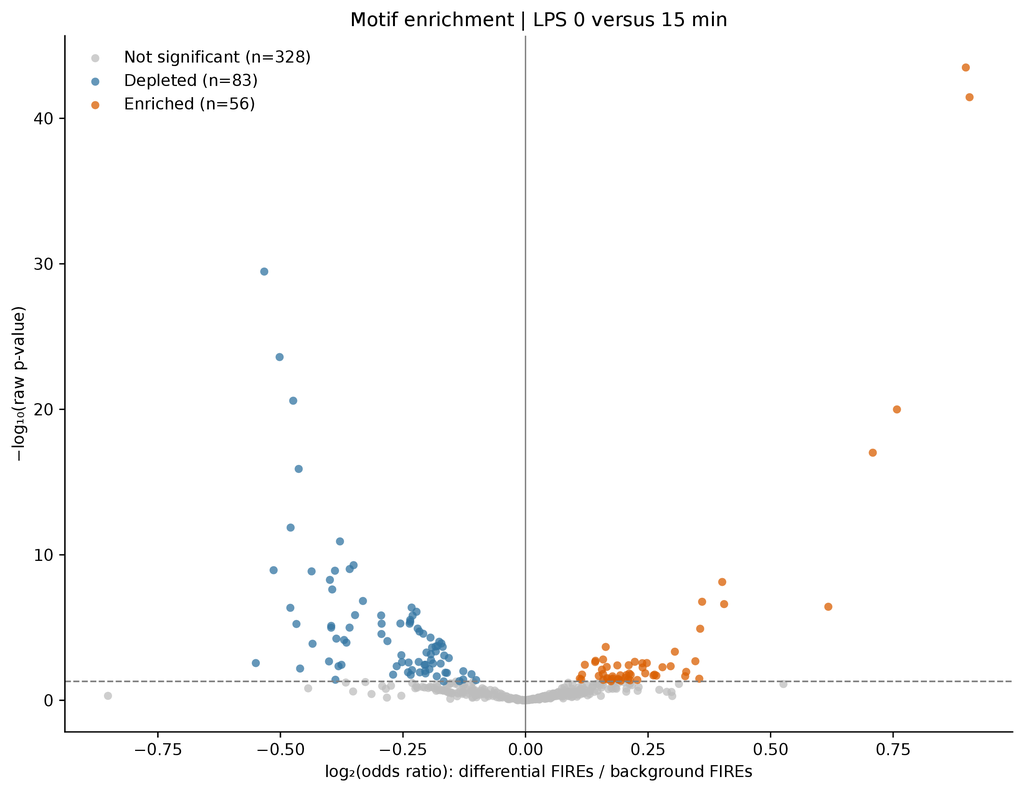

```python
### Volcano plot of motif enrichment results by raw p value

plot_data = enrichment_results.copy()
if 'expressed_any_time' in plot_data.columns:
    plot_data = plot_data.loc[plot_data['expressed_any_time']].copy()

plot_data = plot_data.loc[
    plot_data['p_value'].between(0, 1)
    & plot_data['odds_ratio'].notna()
    & plot_data['odds_ratio'].ge(0)
].copy()

if plot_data.empty:
    raise ValueError('No valid motif enrichment results to plot.')

with np.errstate(divide='ignore'):
    plot_data['log2_or'] = np.log2(plot_data['odds_ratio'])

plot_data['neg_log10_p'] = -np.log10(
    plot_data['p_value'].clip(lower=np.finfo(float).tiny)
)

# Show zero/infinite odds ratios at the plot edges.
finite_x = plot_data.loc[
    np.isfinite(plot_data['log2_or']), 'log2_or'
]
edge = max(1.0, finite_x.abs().max() if not finite_x.empty else 1.0) * 1.1
plot_data['plot_x'] = plot_data['log2_or'].clip(-edge, edge)

cutoff = 0.05
plot_data['category'] = np.select(
    [
        plot_data['p_value'].lt(cutoff) & plot_data['odds_ratio'].gt(1),
        plot_data['p_value'].lt(cutoff) & plot_data['odds_ratio'].lt(1),
    ],
    ['Enriched', 'Depleted'],
    default='Not significant',
)

fig, ax = plt.subplots(figsize=(9, 7))
palette = {
    'Not significant': '#bdbdbd',
    'Depleted': '#3274a1',
    'Enriched': '#d95f02',
}

for category, color in palette.items():
    subset = plot_data.loc[plot_data['category'].eq(category)]
    ax.scatter(
        subset['plot_x'], subset['neg_log10_p'],
        c=color, s=25, alpha=0.75, linewidths=0,
        label=f'{category} (n={len(subset)})',
    )

ax.axhline(-np.log10(cutoff), color='grey', linestyle='--', linewidth=1)
ax.axvline(0, color='grey', linewidth=0.8)

ax.set(
    xlabel='log₂(odds ratio): differential FIREs / background FIREs',
    ylabel='−log₁₀(raw p-value)',
    title='Motif enrichment | LPS 0 versus 15 min',
)
ax.legend(frameon=False)
ax.spines[['top', 'right']].set_visible(False)

if (~np.isfinite(plot_data['log2_or'])).any():
    fig.text(
        0.5, 0.01, 'Zero/infinite odds ratios are displayed at the x-axis edges.',
        ha='center', fontsize=9,
    )
    fig.tight_layout(rect=(0, 0.04, 1, 1))
else:
    fig.tight_layout()

plots_dir.mkdir(parents=True, exist_ok=True)
show_pdf_figure(
    fig,
    plots_dir / 'motif_enrichment_volcano_raw_p.pdf',
)
```

We rank the motifs by raw p-value and retain all raw-significant motifs in the significant results table.

```python
motif_results_by_raw_p = enrichment_results.sort_values(['p_value', 'motif_id']).reset_index(drop=True)
significant_motifs = motif_results_by_raw_p.loc[motif_results_by_raw_p['raw_significant']].copy()
top_motifs = significant_motifs.head(top_n).copy()
display(motif_results_by_raw_p.head())
print(f'Panel 2 shows the first {len(top_motifs)} of {len(significant_motifs)} raw-significant motifs.')
display(significant_motifs.head())
```

|  | motif_id | differential_with_hit | differential_without_hit | background_with_hit | background_without_hit | differential_fraction | background_fraction | odds_ratio | odds_ratio_plot | zero_cell_correction | ... | mean_cpm_10min | mean_cpm_15min | q_value | log2_odds_ratio_plot | neg_log10_p | significant_enrichment | label | raw_significant | bh_significant | significance_class |
| --- | --- | --- | --- | --- | --- | --- | --- | --- | --- | --- | --- | --- | --- | --- | --- | --- | --- | --- | --- | --- | --- |
| 0 | MA0107.1 | 723 | 5027 | 6165 | 79894 | 0.125739 | 0.071637 | 1.863848 | 1.863848 | False | ... | 78.924501 | 83.567722 | 1.648997e-41 | 0.898284 | 43.493743 | True | RELA [MA0107.1] | True | True | BH q < 0.05 |
| 1 | MA0101.1 | 673 | 5077 | 5686 | 80373 | 0.117043 | 0.066071 | 1.873748 | 1.873748 | False | ... | 21.288950 | 22.800974 | 9.091498e-40 | 0.905927 | 41.451298 | True | REL [MA0101.1] | True | True | BH q < 0.05 |
| 2 | MA0139.2 | 1203 | 4547 | 23824 | 62235 | 0.209217 | 0.276833 | 0.691131 | 0.691131 | False | ... | 71.951583 | 71.144179 | 5.838443e-28 | -0.532968 | 29.467545 | False | CTCF [MA0139.2] | True | True | BH q < 0.05 |
| 3 | MA1929.2 | 1035 | 4715 | 20405 | 65654 | 0.180000 | 0.237105 | 0.706290 | 0.706290 | False | ... | 71.951583 | 71.144179 | 3.286883e-22 | -0.501667 | 23.592119 | False | CTCF [MA1929.2] | True | True | BH q < 0.05 |
| 4 | MA1930.2 | 1003 | 4747 | 19525 | 66534 | 0.174435 | 0.226879 | 0.720003 | 0.720003 | False | ... | 71.951583 | 71.144179 | 2.639178e-19 | -0.473925 | 20.590524 | False | CTCF [MA1930.2] | True | True | BH q < 0.05 |

5 rows × 32 columns

|  | motif_id | differential_with_hit | differential_without_hit | background_with_hit | background_without_hit | differential_fraction | background_fraction | odds_ratio | odds_ratio_plot | zero_cell_correction | ... | mean_cpm_10min | mean_cpm_15min | q_value | log2_odds_ratio_plot | neg_log10_p | significant_enrichment | label | raw_significant | bh_significant | significance_class |
| --- | --- | --- | --- | --- | --- | --- | --- | --- | --- | --- | --- | --- | --- | --- | --- | --- | --- | --- | --- | --- | --- |
| 0 | MA0107.1 | 723 | 5027 | 6165 | 79894 | 0.125739 | 0.071637 | 1.863848 | 1.863848 | False | ... | 78.924501 | 83.567722 | 1.648997e-41 | 0.898284 | 43.493743 | True | RELA [MA0107.1] | True | True | BH q < 0.05 |
| 1 | MA0101.1 | 673 | 5077 | 5686 | 80373 | 0.117043 | 0.066071 | 1.873748 | 1.873748 | False | ... | 21.288950 | 22.800974 | 9.091498e-40 | 0.905927 | 41.451298 | True | REL [MA0101.1] | True | True | BH q < 0.05 |
| 2 | MA0139.2 | 1203 | 4547 | 23824 | 62235 | 0.209217 | 0.276833 | 0.691131 | 0.691131 | False | ... | 71.951583 | 71.144179 | 5.838443e-28 | -0.532968 | 29.467545 | False | CTCF [MA0139.2] | True | True | BH q < 0.05 |
| 3 | MA1929.2 | 1035 | 4715 | 20405 | 65654 | 0.180000 | 0.237105 | 0.706290 | 0.706290 | False | ... | 71.951583 | 71.144179 | 3.286883e-22 | -0.501667 | 23.592119 | False | CTCF [MA1929.2] | True | True | BH q < 0.05 |
| 4 | MA1930.2 | 1003 | 4747 | 19525 | 66534 | 0.174435 | 0.226879 | 0.720003 | 0.720003 | False | ... | 71.951583 | 71.144179 | 2.639178e-19 | -0.473925 | 20.590524 | False | CTCF [MA1930.2] | True | True | BH q < 0.05 |

5 rows × 32 columns

Panel 2 shows raw-significant enriched and depleted motifs, with a separate color for those supported after BH correction.

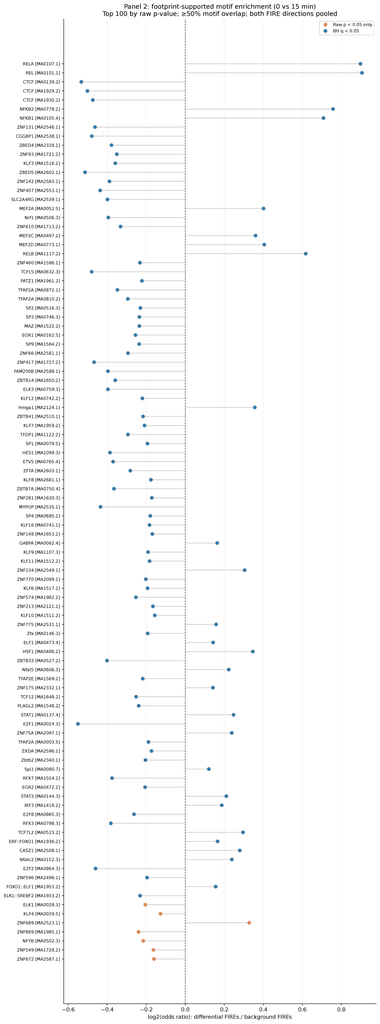

```python
from matplotlib.lines import Line2D

def plot_motif_lollipop(motif_table, title, xlabel):
    fig, ax = plt.subplots(figsize=(10, max(4, 0.25 * len(motif_table) + 1.8)))
    if motif_table.empty:
        ax.text(0.5, 0.5, 'No expression-eligible motifs have raw p < 0.05',
                transform=ax.transAxes, ha='center', va='center')
        ax.set_yticks([])
    else:
        y = np.arange(len(motif_table))
        ax.hlines(y, 0, motif_table['log2_odds_ratio_plot'], color='#c7c7c7', linewidth=1.1)
        for bh_supported, color in [(False, '#dd8452'), (True, '#3274a1')]:
            for corrected, marker in [(False, 'o'), (True, '^')]:
                keep = motif_table['bh_significant'].eq(bh_supported) & motif_table['zero_cell_correction'].eq(corrected)
                ax.scatter(motif_table.loc[keep, 'log2_odds_ratio_plot'], y[keep],
                           color=color, marker=marker, s=35, zorder=3)
        ax.set_yticks(y, motif_table['label'], fontsize=8)
        ax.invert_yaxis()
        legend = [Line2D([0], [0], color='#dd8452', marker='o', linestyle='', label='Raw p < 0.05 only'),
                  Line2D([0], [0], color='#3274a1', marker='o', linestyle='', label='BH q < 0.05')]
        if motif_table['zero_cell_correction'].any():
            legend.append(Line2D([0], [0], color='#555555', marker='^', linestyle='',
                                 label='0.5 correction for plotting only'))
        ax.legend(handles=legend, loc='best', fontsize=8)
    ax.axvline(0, color='#555555', linestyle='--', linewidth=1)
    ax.set_xlabel(xlabel)
    ax.set_title(title)
    ax.grid(axis='x', alpha=0.2)
    ax.spines[['top', 'right']].set_visible(False)
    fig.tight_layout()
    return fig

fig = plot_motif_lollipop(
    top_motifs,
    f'Panel 2: footprint-supported motif enrichment (0 vs 15 min)\nTop {len(top_motifs)} by raw p-value; ≥50% motif overlap; both FIRE directions pooled',
    'log2(odds ratio): differential FIREs / background FIREs',
)
show_pdf_figure(fig, plots_dir / 'panel2_motif_enrichment_lollipop.pdf')
```

### Motif enrichment separately in FIRE-frequency increases and decreases

Split the raw-p-significant 0-versus-15 FIREs by the sign of `freq_15 - freq_0`. Each group is tested against the same coverage-passing, raw p > 0.05 background, using the existing expression filter and footprint-supported motif matrices (≥50% motif overlap with one 10–80 bp footprint). Regions without supported motifs remain in each denominator. BH correction is applied separately within each analysis across all expression-eligible motifs.

The lollipop plots show up to 100 motifs with raw p < 0.05, ranked by raw p-value, including both motif enrichment and depletion. FIRE-frequency direction defines the region group; motif odds-ratio direction describes enrichment within that group. Only the lollipop PDFs are saved, with separate increase/decrease filenames; results remain in memory.

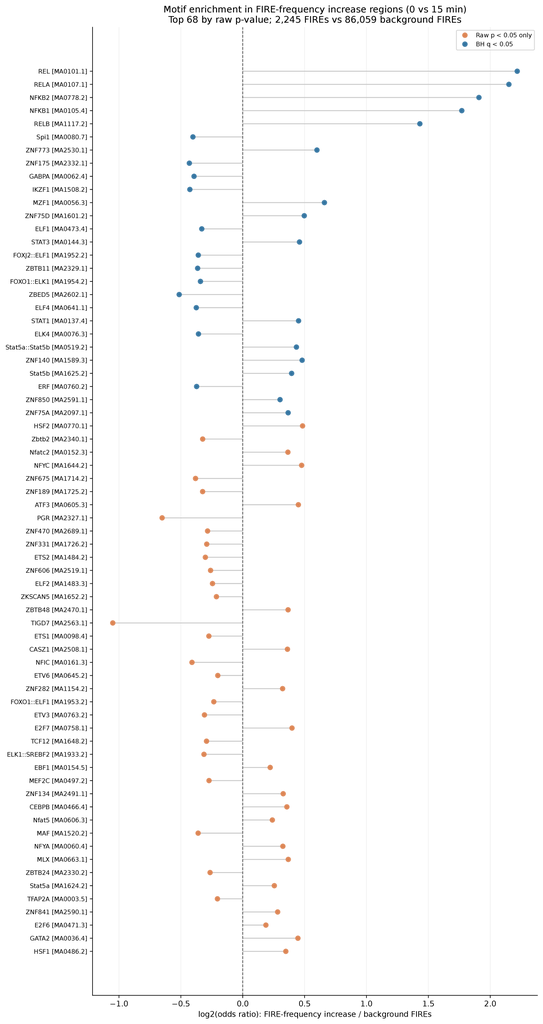

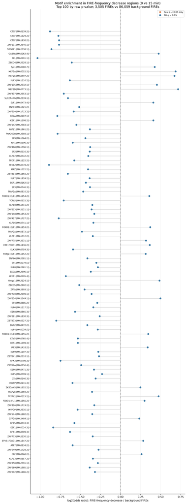

```python
# Match each sparse-matrix row to its 0-versus-15 FIRE-frequency change.
directional_region_ids = regions_by_group['differential'].loc[
    analysis_masks['differential'], 'region_id'].to_numpy()
assert len(directional_region_ids) == counts_by_group['differential'].shape[0]
directional_regions = pairwise_0_15.set_index('region_id').loc[directional_region_ids]
assert directional_regions['comparison'].eq('LPS_0_vs_LPS_15').all()
assert directional_regions['pass_coverage'].eq(True).all()
assert directional_regions['p_value'].lt(raw_p_threshold).all()
directional_delta = directional_regions['delta_freq_15_minus_0'].to_numpy()
assert np.isfinite(directional_delta).all()
fire_direction_masks = {'increase': directional_delta > 0, 'decrease': directional_delta < 0}

motif_results_by_fire_direction = {}
for fire_direction, row_mask in fire_direction_masks.items():
    if not row_mask.any():
        raise ValueError(f'No differential FIREs with a frequency {fire_direction}')
    direction_counts = counts_by_group['differential'][row_mask].tocsr()
    direction_audit = test_motif_enrichment(
        direction_counts, counts_by_group['background'], motif_expression)
    direction_results = direction_audit.loc[direction_audit['expressed_any_time']].copy()
    direction_results['raw_significant'] = direction_results['p_value'].lt(raw_p_threshold)
    direction_results['bh_significant'] = direction_results['q_value'].lt(fdr_threshold)
    direction_results = direction_results.sort_values(['p_value', 'motif_id']).reset_index(drop=True)
    motif_results_by_fire_direction[fire_direction] = direction_results

    direction_top = direction_results.loc[direction_results['raw_significant']].head(top_n)
    direction_fig = plot_motif_lollipop(
        direction_top,
        f'Motif enrichment in FIRE-frequency {fire_direction} regions (0 vs 15 min)\n'
        f'Top {len(direction_top)} by raw p-value; {direction_counts.shape[0]:,} FIREs vs '
        f'{counts_by_group["background"].shape[0]:,} background FIREs',
        f'log2(odds ratio): FIRE-frequency {fire_direction} / background FIREs',
    )
    show_pdf_figure(direction_fig, plots_dir / f'motif_enrichment_FIRE_{fire_direction}_lollipop.pdf')
```

## Plot the TF example regions

Generate RELA, NFKB1, KLF12 and CTCF, ZNF131, ELK3 examples; display only RELA and ZNF131

```python
if generate_example_plots:
    # The order below is user specified, not an ordering by motif p-value or BH q-value.
    example_directions = ['enriched', 'depleted']
    requested_profiles = {
        'enriched': [('RELA', 'MA0107.1'), ('NFKB1', 'MA0105.4'), ('KLF12', 'MA0742.2')],
        'depleted': [('CTCF', 'MA0139.2'), ('ZNF131', 'MA2546.1'), ('ELK3', 'MA0759.3')],
    }
    # CTCF uses the explicit MA0139.2 profile; its other profiles are not plotted.
    requested_example_motifs = pd.DataFrame([
        {'direction': direction, 'rank_within_direction': rank,
         'selection_TF': tf, 'selection_motif_id': motif}
        for direction, profiles in requested_profiles.items()
        for rank, (tf, motif) in enumerate(profiles, start=1)
    ])
    motif_statistics = enrichment_results[['motif_id', 'TF', 'q_value', 'p_value', 'odds_ratio']].rename(
        columns={'motif_id': 'selection_motif_id', 'TF': 'reported_TF',
                 'q_value': 'selection_motif_q_value', 'p_value': 'selection_motif_p_value',
                 'odds_ratio': 'selection_motif_odds_ratio'})
    requested_example_motifs = requested_example_motifs.merge(
        motif_statistics, on='selection_motif_id', how='left', validate='one_to_one', sort=False)
    assert requested_example_motifs['reported_TF'].notna().all(), 'A requested TF profile is absent from the tested motif results.'
    assert requested_example_motifs['selection_TF'].str.upper().eq(requested_example_motifs['reported_TF'].str.upper()).all()
    observed_effect = np.where(requested_example_motifs['selection_motif_odds_ratio'].gt(1), 'enriched', 'depleted')
    requested_example_motifs['observed_motif_effect'] = observed_effect
    # Requested plotting groups are distinct from measured enrichment direction.
    mismatch = requested_example_motifs.loc[requested_example_motifs['direction'].ne(observed_effect)]
    if not mismatch.empty:
        print('Requested group differs from measured enrichment for:', ', '.join(mismatch.selection_TF))
        display(mismatch[['selection_TF', 'direction', 'observed_motif_effect', 'selection_motif_odds_ratio', 'selection_motif_q_value']])
    requested_example_motifs = requested_example_motifs.drop(columns='reported_TF')
    remember_table('requested_example_motifs.tsv', requested_example_motifs, sep='\t', index=False)

    # FIRE BH values annotate the FIRE track and do not rank the TFs or their regions.
    fire_q_by_region = pd.Series(adjust_bh(pairwise_0_15['p_value']), index=pairwise_0_15['region_id'])
    rank_columns = ['chrom', 'start', 'end', 'region_id', 'freq_0', 'freq_15',
                    'delta_freq_15_minus_0', 'log2_or', 'p_value']
    region_candidates = pairwise_fire_regions_differential.loc[
        pairwise_fire_regions_differential['delta_freq_15_minus_0'].ne(0), rank_columns
    ].copy()
    region_candidates['fire_direction'] = np.where(region_candidates['delta_freq_15_minus_0'].gt(0), 'increased', 'decreased')
    region_candidates['fire_q_value'] = region_candidates['region_id'].map(fire_q_by_region)
    assert region_candidates['fire_q_value'].notna().all()
    count_region_ids = regions_by_group['differential'].loc[analysis_masks['differential'], 'region_id'].to_numpy()
    assert len(count_region_ids) == counts_by_group['differential'].shape[0]
    assert len(motif_ids) == counts_by_group['differential'].shape[1]
    motif_column_indices = pd.Index(motif_ids).get_indexer(requested_example_motifs['selection_motif_id'])
    assert (motif_column_indices >= 0).all()
    present = counts_by_group['differential'][:, motif_column_indices].tocoo()
    motif_region_hits = pd.DataFrame({
        'region_id': count_region_ids[present.row],
        'selection_motif_id': requested_example_motifs['selection_motif_id'].to_numpy()[present.col],
        'selection_motif_hit_count': present.data,
    })
    ranked_regions = (motif_region_hits
        .merge(requested_example_motifs, on='selection_motif_id', validate='many_to_one')
        .merge(region_candidates, on='region_id', validate='many_to_one')
        .sort_values(['direction', 'rank_within_direction', 'p_value', 'chrom', 'start', 'end', 'region_id'],
                     kind='stable').reset_index(drop=True))
    remember_table('ranked_differential_regions.tsv', ranked_regions, sep='\t', index=False)
    display(requested_example_motifs)
    print('Candidate motif-region pairs:', len(ranked_regions))
    print('Each requested TF receives its strongest remaining differential FIRE by raw Fisher p-value, then coordinates.')
```

|  | selection_TF | direction | observed_motif_effect | selection_motif_odds_ratio | selection_motif_q_value |
| --- | --- | --- | --- | --- | --- |
| 2 | KLF12 | enriched | depleted | 0.858572 | 0.000159 |

|  | direction | rank_within_direction | selection_TF | selection_motif_id | selection_motif_q_value | selection_motif_p_value | selection_motif_odds_ratio | observed_motif_effect |
| --- | --- | --- | --- | --- | --- | --- | --- | --- |
| 0 | enriched | 1 | RELA | MA0107.1 | 1.648997e-41 | 3.208164e-44 | 1.863848 | enriched |
| 1 | enriched | 2 | NFKB1 | MA0105.4 | 7.035066e-16 | 9.580829e-18 | 1.634104 | enriched |
| 2 | enriched | 3 | KLF12 | MA0742.2 | 1.590712e-04 | 1.176013e-05 | 0.858572 | depleted |
| 3 | depleted | 1 | CTCF | MA0139.2 | 5.838443e-28 | 3.407651e-30 | 0.691131 | depleted |
| 4 | depleted | 2 | ZNF131 | MA2546.1 | 8.031374e-15 | 1.250019e-16 | 0.725613 | depleted |

|  | region_id | selection_motif_id | selection_motif_hit_count | direction | rank_within_direction | selection_TF | selection_motif_q_value | selection_motif_p_value | selection_motif_odds_ratio | observed_motif_effect | chrom | start | end | freq_0 | freq_15 | delta_freq_15_minus_0 | log2_or | p_value | fire_direction | fire_q_value |
| --- | --- | --- | --- | --- | --- | --- | --- | --- | --- | --- | --- | --- | --- | --- | --- | --- | --- | --- | --- | --- |
| 0 | chr4:112284963-112285236 | MA0139.2 | 1 | depleted | 1 | CTCF | 5.838443e-28 | 3.407651e-30 | 0.691131 | depleted | chr4 | 112284963 | 112285236 | 0.040816 | 0.476190 | 0.435374 | 4.112576 | 1.365642e-07 | increased | 0.006269 |
| 1 | chr3:101827658-101828081 | MA0139.2 | 1 | depleted | 1 | CTCF | 5.838443e-28 | 3.407651e-30 | 0.691131 | depleted | chr3 | 101827658 | 101828081 | 0.134615 | 0.535714 | 0.401099 | 2.803721 | 1.401221e-05 | increased | 0.114063 |
| 2 | chr6:36291030-36291485 | MA0139.2 | 1 | depleted | 1 | CTCF | 5.838443e-28 | 3.407651e-30 | 0.691131 | depleted | chr6 | 36291030 | 36291485 | 0.153846 | 0.507937 | 0.354090 | 2.433358 | 7.466207e-05 | increased | 0.199166 |
| 3 | chr17:77323671-77323902 | MA0139.2 | 1 | depleted | 1 | CTCF | 5.838443e-28 | 3.407651e-30 | 0.691131 | depleted | chr17 | 77323671 | 77323902 | 0.310345 | 0.000000 | -0.310345 | -5.429534 | 7.974008e-05 | decreased | 0.199166 |
| 4 | chr3:66816234-66816434 | MA0139.2 | 1 | depleted | 1 | CTCF | 5.838443e-28 | 3.407651e-30 | 0.691131 | depleted | chr3 | 66816234 | 66816434 | 0.409091 | 0.793651 | 0.384560 | 2.421791 | 8.204132e-05 | increased | 0.199166 |

|  | direction | rank_within_direction | selection_TF | selection_motif_id | selection_motif_q_value | selection_motif_p_value | selection_motif_odds_ratio | observed_motif_effect |
| --- | --- | --- | --- | --- | --- | --- | --- | --- |
| 0 | enriched | 1 | RELA | MA0107.1 | 1.648997e-41 | 3.208164e-44 | 1.863848 | enriched |
| 1 | enriched | 2 | NFKB1 | MA0105.4 | 7.035066e-16 | 9.580829e-18 | 1.634104 | enriched |
| 2 | enriched | 3 | KLF12 | MA0742.2 | 1.590712e-04 | 1.176013e-05 | 0.858572 | depleted |
| 3 | depleted | 1 | CTCF | MA0139.2 | 5.838443e-28 | 3.407651e-30 | 0.691131 | depleted |
| 4 | depleted | 2 | ZNF131 | MA2546.1 | 8.031374e-15 | 1.250019e-16 | 0.725613 | depleted |
| 5 | depleted | 3 | ELK3 | MA0759.3 | 1.417969e-04 | 1.020717e-05 | 0.759700 | depleted |

### Select FIRE region for the enriched TF

select the TF examples, first examine a ±500 bp window around each FIRE midpoint, then center the final ±500 bp window on its most footprint-supported motif hit.

```python
if generate_example_plots:
    n_examples_per_direction = 3
    example_exclusions = pd.DataFrame([
        {'region_id': 'chr16:28141068-28141263',
         'reason': 'User exclusion: missing segment in the read'},
        {'region_id': 'chr4:112284963-112285236',
         'reason': 'User exclusion: remove this example and its associated plots'},
    ])
    remember_table('excluded_example_regions.tsv', example_exclusions, sep='\t', index=False)
    excluded_region_ids = set(example_exclusions['region_id'])
    eligible_example_regions = ranked_regions.loc[~ranked_regions['region_id'].isin(excluded_region_ids)].copy()
    remember_table('eligible_ranked_example_regions.tsv', eligible_example_regions, sep='\t', index=False)
    selected_rows, used_regions = [], set()
    for requested in requested_example_motifs.itertuples(index=False):
        candidates = eligible_example_regions.loc[
            eligible_example_regions['selection_motif_id'].eq(requested.selection_motif_id)
            & ~eligible_example_regions['region_id'].isin(used_regions)
        ]
        if candidates.empty:
            raise ValueError(f'No distinct eligible FIRE region remains for {requested.selection_TF}')
        row = candidates.iloc[0]
        selected_rows.append(row)
        used_regions.add(row['region_id'])
    selected_examples = pd.DataFrame(selected_rows).reset_index(drop=True)
    assert len(selected_examples) == 2 * n_examples_per_direction
    assert selected_examples.groupby('direction').size().eq(n_examples_per_direction).all()
    assert not selected_examples['region_id'].duplicated().any()
    assert not selected_examples['region_id'].isin(excluded_region_ids).any()
    assert selected_examples['selection_motif_hit_count'].gt(0).all()
    assert selected_examples['selection_TF'].tolist() == requested_example_motifs['selection_TF'].tolist()
    selected_examples['example_id'] = selected_examples['direction'] + '_' + selected_examples['rank_within_direction'].astype(str)

    def example_folder_name(tf_name, region_id):
        motif_label = re.sub(r'[^A-Za-z0-9_.-]', '_', tf_name)
        region_label = re.sub(r'[:-]', '_', region_id)
        return f'{motif_label}_{region_label}'

    example_folder_names = {
        row.example_id: example_folder_name(row.selection_TF, row.region_id)
        for row in selected_examples.itertuples(index=False)
    }

    def example_directory(example_id):
        return example_root / example_folder_names[example_id]

    # First identify footprints in a +/-500 bp window around the FIRE midpoint.
    example_flank_bp = 500
    selected_examples['fire_midpoint'] = ((selected_examples['start'] + 1 + selected_examples['end']) // 2).astype(int)
    selected_examples['window_center'] = selected_examples['fire_midpoint']
    selected_examples['window_start'] = selected_examples['window_center'] - example_flank_bp
    selected_examples['window_end'] = selected_examples['window_center'] + example_flank_bp
    assert selected_examples['window_start'].gt(0).all()
    selected_examples['initial_window_start'] = selected_examples['window_start']
    selected_examples['initial_window_end'] = selected_examples['window_end']
    selected_examples['window_coordinate_system'] = '1-based inclusive; center +/-500 bp (1001 bases)'
    remember_table('selected_example_regions.tsv', selected_examples, sep='\t', index=False)
    for row in selected_examples.itertuples(index=False):
        example_directory(row.example_id).mkdir(parents=True, exist_ok=True)
    display(example_exclusions)
    display(selected_examples[['example_id', 'region_id', 'selection_TF', 'selection_motif_id',
                               'selection_motif_q_value', 'fire_direction', 'p_value']])
    print('Selected one distinct region for each requested TF, keeping the specified TF order.')

    # The original FIMO scan covers FIRE intervals only; flanking sequence is not rescanned.
    track_motifs = enrichment_results.loc[
        enrichment_results['motif_id'].isin(selected_examples['selection_motif_id']),
        ['motif_id', 'TF', 'q_value', 'odds_ratio']
    ].rename(columns={'q_value': 'motif_q_value'})
    track_motifs['motif_effect'] = np.where(track_motifs['odds_ratio'].gt(1), 'enriched', 'depleted')
    hit_parts = []
    for chunk in pd.read_csv(fimo_root / 'fimo_differential/fimo.tsv', sep='\t', comment='#',
                             usecols=['motif_id', 'sequence_name', 'start', 'stop', 'strand', 'score', 'p-value'],
                             chunksize=250_000):
        chunk = chunk.loc[chunk['motif_id'].isin(track_motifs['motif_id'])].copy()
        left = chunk[['start', 'stop']].min(axis=1)
        right = chunk[['start', 'stop']].max(axis=1)
        chunk['bed_start'] = left if fasta_headers_use_bed_start else left - 1
        chunk['bed_end'] = right + 1 if fasta_headers_use_bed_start else right
        for ex in selected_examples.itertuples(index=False):
            hits = chunk.loc[chunk['motif_id'].eq(ex.selection_motif_id)
                             & chunk['sequence_name'].eq(ex.chrom)
                             & chunk['bed_start'].ge(ex.start) & chunk['bed_end'].le(ex.end)].copy()
            if hits.empty:
                continue
            supported = footprint_support.supported_motifs(
                hits['bed_start'].to_numpy(), hits['bed_end'].to_numpy(), footprint_index[ex.chrom])
            hits = hits.loc[supported].copy()
            if hits.empty:
                continue
            hits['example_id'], hits['region_id'] = ex.example_id, ex.region_id
            hits['start'], hits['end'] = hits['bed_start'] + 1, hits['bed_end']
            hit_parts.append(hits[['example_id', 'region_id', 'motif_id', 'start', 'end', 'strand', 'score', 'p-value']])
    if not hit_parts:
        raise ValueError('No FIMO hits found for the motif-selected regions')
    example_motif_hits = (pd.concat(hit_parts, ignore_index=True)
        .rename(columns={'p-value': 'fimo_p_value'})
        .merge(track_motifs.drop(columns='odds_ratio'), on='motif_id', validate='many_to_one')
        .sort_values(['example_id', 'motif_q_value', 'motif_id', 'start', 'end', 'strand']))
    assert np.isfinite(example_motif_hits['score']).all()
    for ex in selected_examples.itertuples(index=False):
        hits = example_motif_hits.loc[example_motif_hits['example_id'].eq(ex.example_id)]
        assert hits['start'].ge(ex.start + 1).all() and hits['end'].le(ex.end).all()
        assert hits['motif_id'].eq(ex.selection_motif_id).all()
        assert len(hits) == ex.selection_motif_hit_count
    remember_table('example_motif_hits.tsv', example_motif_hits, sep='\t', index=False)
    display(example_motif_hits.head())
    print('Each example shows only its requested TF motif; motif and FIRE BH values annotate separate tests.')
```

|  | region_id | reason |
| --- | --- | --- |
| 0 | chr16:28141068-28141263 | User exclusion: missing segment in the read |
| 1 | chr4:112284963-112285236 | User exclusion: remove this example and its as... |

|  | region_id | selection_motif_id | selection_motif_hit_count | direction | rank_within_direction | selection_TF | selection_motif_q_value | selection_motif_p_value | selection_motif_odds_ratio | observed_motif_effect | chrom | start | end | freq_0 | freq_15 | delta_freq_15_minus_0 | log2_or | p_value | fire_direction | fire_q_value |
| --- | --- | --- | --- | --- | --- | --- | --- | --- | --- | --- | --- | --- | --- | --- | --- | --- | --- | --- | --- | --- |
| 1 | chr3:101827658-101828081 | MA0139.2 | 1 | depleted | 1 | CTCF | 5.838443e-28 | 3.407651e-30 | 0.691131 | depleted | chr3 | 101827658 | 101828081 | 0.134615 | 0.535714 | 0.401099 | 2.803721 | 0.000014 | increased | 0.114063 |
| 2 | chr6:36291030-36291485 | MA0139.2 | 1 | depleted | 1 | CTCF | 5.838443e-28 | 3.407651e-30 | 0.691131 | depleted | chr6 | 36291030 | 36291485 | 0.153846 | 0.507937 | 0.354090 | 2.433358 | 0.000075 | increased | 0.199166 |
| 3 | chr17:77323671-77323902 | MA0139.2 | 1 | depleted | 1 | CTCF | 5.838443e-28 | 3.407651e-30 | 0.691131 | depleted | chr17 | 77323671 | 77323902 | 0.310345 | 0.000000 | -0.310345 | -5.429534 | 0.000080 | decreased | 0.199166 |
| 4 | chr3:66816234-66816434 | MA0139.2 | 1 | depleted | 1 | CTCF | 5.838443e-28 | 3.407651e-30 | 0.691131 | depleted | chr3 | 66816234 | 66816434 | 0.409091 | 0.793651 | 0.384560 | 2.421791 | 0.000082 | increased | 0.199166 |
| 5 | chr2:112799353-112799889 | MA0139.2 | 1 | depleted | 1 | CTCF | 5.838443e-28 | 3.407651e-30 | 0.691131 | depleted | chr2 | 112799353 | 112799889 | 0.163636 | 0.536585 | 0.372949 | 2.497682 | 0.000155 | increased | 0.258663 |

|  | region_id | selection_motif_id | selection_motif_hit_count | direction | rank_within_direction | selection_TF | selection_motif_q_value | selection_motif_p_value | selection_motif_odds_ratio | observed_motif_effect | ... | fire_direction | fire_q_value | example_id | fire_midpoint | window_center | window_start | window_end | initial_window_start | initial_window_end | window_coordinate_system |
| --- | --- | --- | --- | --- | --- | --- | --- | --- | --- | --- | --- | --- | --- | --- | --- | --- | --- | --- | --- | --- | --- |
| 0 | chr2:64204191-64204575 | MA0107.1 | 4 | enriched | 1 | RELA | 1.648997e-41 | 3.208164e-44 | 1.863848 | enriched | ... | increased | 4.417060e-09 | enriched_1 | 64204383 | 64204383 | 64203883 | 64204883 | 64203883 | 64204883 | 1-based inclusive; center +/-500 bp (1001 bases) |
| 1 | chr11:102317165-102317516 | MA0105.4 | 3 | enriched | 2 | NFKB1 | 7.035066e-16 | 9.580829e-18 | 1.634104 | enriched | ... | increased | 1.278662e-01 | enriched_2 | 102317341 | 102317341 | 102316841 | 102317841 | 102316841 | 102317841 | 1-based inclusive; center +/-500 bp (1001 bases) |
| 2 | chr2:142874306-142874693 | MA0742.2 | 1 | enriched | 3 | KLF12 | 1.590712e-04 | 1.176013e-05 | 0.858572 | depleted | ... | increased | 8.246461e-03 | enriched_3 | 142874500 | 142874500 | 142874000 | 142875000 | 142874000 | 142875000 | 1-based inclusive; center +/-500 bp (1001 bases) |
| 3 | chr3:101827658-101828081 | MA0139.2 | 1 | depleted | 1 | CTCF | 5.838443e-28 | 3.407651e-30 | 0.691131 | depleted | ... | increased | 1.140630e-01 | depleted_1 | 101827870 | 101827870 | 101827370 | 101828370 | 101827370 | 101828370 | 1-based inclusive; center +/-500 bp (1001 bases) |
| 4 | chr3:105366544-105366955 | MA2546.1 | 6 | depleted | 2 | ZNF131 | 8.031374e-15 | 1.250019e-16 | 0.725613 | depleted | ... | increased | 1.704717e-01 | depleted_2 | 105366750 | 105366750 | 105366250 | 105367250 | 105366250 | 105367250 | 1-based inclusive; center +/-500 bp (1001 bases) |

5 rows × 28 columns

|  | region_id | reason |
| --- | --- | --- |
| 0 | chr16:28141068-28141263 | User exclusion: missing segment in the read |
| 1 | chr4:112284963-112285236 | User exclusion: remove this example and its as... |

|  | example_id | region_id | selection_TF | selection_motif_id | selection_motif_q_value | fire_direction | p_value |
| --- | --- | --- | --- | --- | --- | --- | --- |
| 0 | enriched_1 | chr2:64204191-64204575 | RELA | MA0107.1 | 1.648997e-41 | increased | 4.811141e-14 |
| 1 | enriched_2 | chr11:102317165-102317516 | NFKB1 | MA0105.4 | 7.035066e-16 | increased | 2.049657e-05 |
| 2 | enriched_3 | chr2:142874306-142874693 | KLF12 | MA0742.2 | 1.590712e-04 | increased | 2.694658e-07 |
| 3 | depleted_1 | chr3:101827658-101828081 | CTCF | MA0139.2 | 5.838443e-28 | increased | 1.401221e-05 |
| 4 | depleted_2 | chr3:105366544-105366955 | ZNF131 | MA2546.1 | 8.031374e-15 | increased | 4.353380e-05 |
| 5 | depleted_3 | chr15:42360050-42360278 | ELK3 | MA0759.3 | 1.417969e-04 | increased | 1.517037e-04 |

|  | example_id | region_id | motif_id | start | end | strand | score | fimo_p_value | TF | motif_q_value | motif_effect |
| --- | --- | --- | --- | --- | --- | --- | --- | --- | --- | --- | --- |
| 14 | depleted_1 | chr3:101827658-101828081 | MA0139.2 | 101827813 | 101827827 | - | 8.7541 | 0.000082 | CTCF | 5.838443e-28 | depleted |
| 11 | depleted_2 | chr3:105366544-105366955 | MA2546.1 | 105366614 | 105366626 | + | 10.8794 | 0.000042 | ZNF131 | 8.031374e-15 | depleted |
| 2 | depleted_2 | chr3:105366544-105366955 | MA2546.1 | 105366615 | 105366627 | - | 15.6312 | 0.000002 | ZNF131 | 8.031374e-15 | depleted |
| 3 | depleted_2 | chr3:105366544-105366955 | MA2546.1 | 105366616 | 105366628 | + | 13.8298 | 0.000008 | ZNF131 | 8.031374e-15 | depleted |
| 7 | depleted_2 | chr3:105366544-105366955 | MA2546.1 | 105366617 | 105366629 | - | 11.9787 | 0.000023 | ZNF131 | 8.031374e-15 | depleted |

|  | example_id | region_id | motif_id | start | end | strand | score | fimo_p_value | TF | motif_q_value | motif_effect |
| --- | --- | --- | --- | --- | --- | --- | --- | --- | --- | --- | --- |
| 14 | depleted_1 | chr3:101827658-101828081 | MA0139.2 | 101827813 | 101827827 | - | 8.7541 | 0.000082 | CTCF | 5.838443e-28 | depleted |
| 11 | depleted_2 | chr3:105366544-105366955 | MA2546.1 | 105366614 | 105366626 | + | 10.8794 | 0.000042 | ZNF131 | 8.031374e-15 | depleted |
| 2 | depleted_2 | chr3:105366544-105366955 | MA2546.1 | 105366615 | 105366627 | - | 15.6312 | 0.000002 | ZNF131 | 8.031374e-15 | depleted |
| 3 | depleted_2 | chr3:105366544-105366955 | MA2546.1 | 105366616 | 105366628 | + | 13.8298 | 0.000008 | ZNF131 | 8.031374e-15 | depleted |
| 7 | depleted_2 | chr3:105366544-105366955 | MA2546.1 | 105366617 | 105366629 | - | 11.9787 | 0.000023 | ZNF131 | 8.031374e-15 | depleted |

## Load the Leiden–Manhattan functions

```python
if generate_example_plots:
    import os
    import shutil
    import subprocess
    from pathlib import Path
    from IPython.display import display, FileLink

    example_root = output_root / "example_regions"
    r_scripts_dir = output_root / "scripts"
    for directory in (example_root, r_scripts_dir):
        directory.mkdir(parents=True, exist_ok=True)
    # Use the active R environment, or the installed project-compatible R on Midway.
    r_environment = os.environ.copy()
    r_environment.setdefault("R_LIBS_USER", "/project/spott/cshan/Rlibs/x86_64-pc-linux-gnu-library/4.4")
    rscript = os.environ.get("RSCRIPT") or shutil.which("Rscript")
    if not rscript:
        rscript = "/software/R-4.4.1-el8-x86_64/bin/Rscript"
        shared_libraries = [
            "/software/openblas-0.3.29-el8-x86_64/lib",
            "/software/gcc-10.2.0-el8-x86_64/lib64",
            "/software/glpk-5.0-el8-x86_64/lib",
        ]
        r_environment["LD_LIBRARY_PATH"] = os.pathsep.join(
            shared_libraries + [r_environment.get("LD_LIBRARY_PATH", "")]
        )
    if not Path(rscript).is_file():
        raise FileNotFoundError("Set RSCRIPT to an Rscript executable with the project R packages installed.")
    r_environment["FIRE_PROJECT_ROOT"] = str(project_root)
    r_environment["FIRE_0_15_OUTPUT"] = str(output_root)
    r_environment["FIRE_EXAMPLES_PER_DIRECTION"] = str(n_examples_per_direction)
    r_environment["TZ"] = "America/Chicago"
    r_environment["OPENBLAS_NUM_THREADS"] = "1"
    r_environment["OMP_NUM_THREADS"] = "1"
    print("R executable:", rscript)
    print("Pooled timepoints: 0, 5, 10, 15 min; bin = 0; k = 10; resolution = 1; seed = 1.")
    display(selected_examples[["example_id", "region_id", "window_start", "window_end"]].head())
```

|  | example_id | region_id | window_start | window_end |
| --- | --- | --- | --- | --- |
| 0 | enriched_1 | chr2:64204191-64204575 | 64203883 | 64204883 |
| 1 | enriched_2 | chr11:102317165-102317516 | 102316841 | 102317841 |
| 2 | enriched_3 | chr2:142874306-142874693 | 142874000 | 142875000 |
| 3 | depleted_1 | chr3:101827658-101828081 | 101827370 | 101828370 |
| 4 | depleted_2 | chr3:105366544-105366955 | 105366250 | 105367250 |

Next, we source the existing parsing, clustering, and plotting functions and check their inputs.

```python
if generate_example_plots:
    r_common = r"""
    suppressPackageStartupMessages({
      library(dplyr); library(tidyr); library(ggplot2); library(Matrix)
      library(GenomicRanges); library(Rsamtools); library(data.table)
      library(igraph); library(ComplexHeatmap); library(cowplot); library(grid)
      library(patchwork)
    })
    project_root <- Sys.getenv("FIRE_PROJECT_ROOT")
    output_root <- Sys.getenv("FIRE_0_15_OUTPUT")
    tables_dir <- Sys.getenv("FIRE_TEMP_TABLES")
    example_root <- file.path(output_root, "example_regions")
    source(file.path(project_root, "code/parsing_functions/parsing_footprints_functions.r"))
    source(file.path(project_root, "code/clustering_methods/Leiden_Manhattan/leiden_manhattan_functions.r"))
    source("/project/spott/cshan/fiber-seq/code/parsing_functions/plotting_functions.r", local = TRUE)
    source(file.path(project_root, "code/clustering_methods/Leiden_Manhattan/leiden_manhattan_plots.r"))
    options(scipen = 999)
    set.seed(1)
    examples <- read.delim(file.path(tables_dir, "selected_example_regions.tsv"), check.names = FALSE)
    n_per_direction <- as.integer(Sys.getenv("FIRE_EXAMPLES_PER_DIRECTION", "5"))
    excluded_examples <- read.delim(file.path(tables_dir, "excluded_example_regions.tsv"))
    stopifnot(nrow(examples) == 2L * n_per_direction, !anyDuplicated(examples$example_id),
              all(table(examples$direction) == n_per_direction),
              !any(examples$region_id %in% excluded_examples$region_id))
    sample_table <- data.frame(sample_name = c("LPS_0", "LPS_5", "LPS_10", "LPS_15"),
                               condition = "LPS", timepoint = c(0L, 5L, 10L, 15L))
    sample_names <- sample_table$sample_name
    ft_result_dir <- file.path(project_root, "macrophage_project/FiberHMM/extract/ft_result_dir")
    window_size <- 0L
    k_neighbors <- 10L
    leiden_resolution <- 1
    leiden_seed <- 1L
    # Name examples by their selected TF motif and genomic region coordinates.
    example_output_name <- function(ex) {
      paste0(gsub("[^A-Za-z0-9_.-]", "_", ex$selection_TF), "_",
             gsub("[:-]", "_", ex$region_id))
    }
    example_dir <- function(ex) {
      path <- file.path(example_root, example_output_name(ex))
      dir.create(path, recursive = TRUE, showWarnings = FALSE)
      path
    }
    example_figure_path <- function(ex, panel, description) {
      filename <- paste0(example_output_name(ex), "_", panel, "_", description, ".pdf")
      file.path(example_dir(ex), filename)
    }
    write_tsv <- function(x, path) {
      # Temporary table exchange with Python; removed after this R stage.
      destination <- normalizePath(dirname(path), mustWork = TRUE)
      allowed <- normalizePath(tables_dir, mustWork = TRUE)
      if (!identical(destination, allowed)) stop("TSV output must be in tables_dir: ", path)
      write.table(x, path, sep = "\t", quote = FALSE, row.names = FALSE, na = "NA")
    }
    read_result <- function(ex) readRDS(file.path(example_dir(ex), "pooled_leiden.rds"))
    region_title <- function(ex) paste0(ex$example_id, " | ", ex$region_id,
                                       " | 15 - 0 min delta = ", signif(ex$delta_freq_15_minus_0, 3))
    show_reads <- function(result) {
      print(head(result$assignments[, c("RID", "sample_name", "timepoint", "cluster")]))
      print(table(factor(result$assignments$sample_name, levels = sample_names)))
    }
    """

    def run_r_stage(name, body):
        """Exchange in-memory tables through temporary files scoped to one R stage."""
        import tempfile
        script_path = r_scripts_dir / f"{name}.R"
        script_path.write_text(r_common + "\n" + body + "\n")
        with tempfile.TemporaryDirectory(prefix="fire_0_15_r_") as temporary_tables:
            temporary_path = Path(temporary_tables)
            for filename, contents in notebook_tables.items():
                (temporary_path / filename).write_text(contents)
            stage_environment = r_environment.copy()
            stage_environment["FIRE_TEMP_TABLES"] = temporary_tables
            process = subprocess.run(
                [rscript, "--vanilla", str(script_path)], env=stage_environment,
                stdout=subprocess.PIPE, stderr=subprocess.STDOUT, text=True,
            )
            if process.returncode:
                raise RuntimeError(
                    f"R stage {name} failed with exit status {process.returncode}:\n{process.stdout}"
                )
            for table_path in sorted(temporary_path.glob("*.tsv")):
                contents = table_path.read_text()
                if notebook_tables.get(table_path.name) != contents:
                    notebook_tables[table_path.name] = contents
                    display(pd.read_csv(io.StringIO(contents), sep="\t").head())

    run_r_stage("00_check_leiden_inputs", r"""
    print(sample_table)
    print(examples[, c("example_id", "region_id", "window_start", "window_end")])
    for (chrom in unique(examples$chrom)) {
      paths <- file.path(ft_result_dir, sample_names, "extracted_results", "m6a_by_chr",
                         paste0(sample_names, ".ft_extracted_m6a.", chrom, ".bed.gz"))
      required <- c(paths, paste0(paths, ".tbi"))
      if (!all(file.exists(required))) stop("Missing m6A files: ", paste(required[!file.exists(required)], collapse = ", "))
    }
    print(sessionInfo())
    cat("All", nrow(examples), "selected regions have indexed m6A inputs for every timepoint.\n")
    """)
```

Extract the 0, 5, 10, and 15 min reads

```python
if generate_example_plots:
    def extract_pooled_m6a():
        run_r_stage("01_extract_pooled_m6a", r"""
        input_summary <- list()
        for (i in seq_len(nrow(examples))) {
          ex <- examples[i, , drop = FALSE]
          cat("\nExtracting", ex$example_id, ex$region_id, "\n")
          assembly_samples <- data.frame(sample_name = sample_names,
            fire_dir = file.path(ft_result_dir, sample_names), stringsAsFactors = FALSE)
          assembly_region <- data.frame(region_id = ex$region_id, chr = ex$chrom,
            start = ex$window_start - 1L, end = ex$window_end,
            analysis_start = ex$window_start, analysis_end = ex$window_end)
          dat <- assemble_region_m6a(sample_table = assembly_samples, region = assembly_region)
          # Keep overlapping reads with at least one m6A call in the window.
          called <- Matrix::rowSums(dat$met_mat, na.rm = TRUE) > 0
          dat$met_mat <- dat$met_mat[called, , drop = FALSE]
          dat$rids_df <- dat$rids_df[called, , drop = FALSE]
          stopifnot(!anyDuplicated(dat$rids_df$RID),
                    identical(rownames(dat$met_mat), as.character(dat$rids_df$RID)))
          dat$rids_df$timepoint <- sample_table$timepoint[match(dat$rids_df$sample_name, sample_names)]
          dat$example <- ex
          saveRDS(dat, file.path(example_dir(ex), "pooled_m6a_extracted.rds"))
          print(head(dat$rids_df))
          cat(nrow(dat$met_mat), "pooled reads x", ncol(dat$met_mat), "m6A sites before filtering\n")
          counts <- dat$rids_df %>% count(sample_name, timepoint, name = "n_extracted_reads")
          counts$example_id <- ex$example_id
          counts$region_id <- ex$region_id
          input_summary[[i]] <- counts
          print(counts)
        }
        write_tsv(bind_rows(input_summary), file.path(tables_dir, "extracted_molecule_counts.tsv"))
        """)
        extracted_counts = pd.read_csv(io.StringIO(notebook_tables["extracted_molecule_counts.tsv"]), sep="\t")
        display(extracted_counts.head())

    extract_pooled_m6a()
```

|  | sample_name | timepoint | n_extracted_reads | example_id | region_id |
| --- | --- | --- | --- | --- | --- |
| 0 | LPS_0 | 0 | 58 | enriched_1 | chr2:64204191-64204575 |
| 1 | LPS_10 | 10 | 74 | enriched_1 | chr2:64204191-64204575 |
| 2 | LPS_15 | 15 | 65 | enriched_1 | chr2:64204191-64204575 |
| 3 | LPS_5 | 5 | 71 | enriched_1 | chr2:64204191-64204575 |
| 4 | LPS_0 | 0 | 66 | enriched_2 | chr11:102317165-102317516 |

|  | sample_name | timepoint | n_extracted_reads | example_id | region_id |
| --- | --- | --- | --- | --- | --- |
| 0 | LPS_0 | 0 | 58 | enriched_1 | chr2:64204191-64204575 |
| 1 | LPS_10 | 10 | 74 | enriched_1 | chr2:64204191-64204575 |
| 2 | LPS_15 | 15 | 65 | enriched_1 | chr2:64204191-64204575 |
| 3 | LPS_5 | 5 | 71 | enriched_1 | chr2:64204191-64204575 |
| 4 | LPS_0 | 0 | 66 | enriched_2 | chr11:102317165-102317516 |

## Run pooled Manhattan kNN and Leiden clustering

```python
if generate_example_plots:
    def cluster_pooled_molecules():
        run_r_stage("02_pooled_manhattan_leiden", r"""
    source("/project/spott/cshan/fiber-seq/code/parsing_functions/plotting_functions.r", local = TRUE)
        all_assignments <- list()
        run_summaries <- list()
        for (i in seq_len(nrow(examples))) {
          ex <- examples[i, , drop = FALSE]
          dat <- readRDS(file.path(example_dir(ex), "pooled_m6a_extracted.rds"))
          stopifnot(identical(dat$example, ex))
          # The saved call-derived cache lacks zero-call reads.
          # Re-extract longest alignments spanning the entire window, retaining zero-call reads.
          assembly_samples <- data.frame(sample_name = sample_names,
            fire_dir = file.path(ft_result_dir, sample_names), stringsAsFactors = FALSE)
          assembly_region <- data.frame(region_id = ex$region_id, chr = ex$chrom,
            start = ex$window_start - 1L, end = ex$window_end,
            analysis_start = ex$window_start, analysis_end = ex$window_end)
          dat <- assemble_region_m6a(full_span = TRUE, sample_table = assembly_samples,
            region = assembly_region, matrix_dir = NULL, reuse = FALSE)
          met_mat <- dat$met_mat
          metadata <- dat$rids_df[match(rownames(met_mat), dat$rids_df$RID), , drop = FALSE]
          print(head(metadata))
          cat(ex$example_id, ":", nrow(met_mat), "retained reads x", ncol(met_mat), "sites\n")
          retained_counts <- table(factor(metadata$sample_name, levels = sample_names))
          print(retained_counts)
          if (any(retained_counts == 0L)) stop(ex$example_id, ": no retained molecules at a timepoint; do not substitute another region")
          if (nrow(met_mat) < 3L || ncol(met_mat) < 2L) stop("Too few reads/sites for ", ex$example_id)
          result <- leiden_manhattan_cluster(met_mat = met_mat, rids_df = metadata,
            region_start = ex$window_start, region_end = ex$window_end,
            window_size = window_size, k_neighbors = k_neighbors, resolution = leiden_resolution,
            seed = leiden_seed, verbose = TRUE)
          result$assignments$original_RID <- metadata$original_RID[
            match(result$assignments$RID, metadata$RID)]
          result$assignments$sample_name <- factor(result$assignments$sample_name, levels = sample_names)
          result$assignments$timepoint <- sample_table$timepoint[match(result$assignments$sample_name, sample_names)]
          result$assignments$region_id <- ex$region_id
          result$assignments$example_id <- ex$example_id
          result$assignments$direction <- ex$direction
          result$site_met_mat <- met_mat
          result$met_mat <- met_mat
          result$region <- data.frame(chr = ex$chrom, start = ex$window_start - 1L, end = ex$window_end,
            analysis_start = ex$window_start, analysis_end = ex$window_end,
            width = ex$window_end - ex$window_start + 1L, region_id = ex$region_id,
            annotation = region_title(ex), region_type = "differential_FIRE")
          result$example <- ex
          result$params$region_chr <- ex$chrom
          result$params$region_id <- ex$region_id
          result$params$coordinate_system <- "1-based inclusive"
          result$cluster_colors <- cluster_palette(levels(result$assignments$cluster))
          stopifnot(identical(rownames(result$feat_mat), result$assignments$RID),
                    setequal(igraph::V(result$graph)$name, result$assignments$RID))
          saveRDS(result, file.path(example_dir(ex), "pooled_leiden.rds"))
          show_reads(result)
          all_assignments[[i]] <- result$assignments
          run_summaries[[i]] <- data.frame(example_id = ex$example_id, region_id = ex$region_id,
            n_reads = nrow(result$assignments), n_features = ncol(result$feat_mat),
            n_clusters = result$n_clusters, k_eff = result$params$k_eff,
            n_edges = igraph::ecount(result$graph), sigma = result$params$sigma)
        }
        write_tsv(bind_rows(all_assignments), file.path(tables_dir, "molecule_cluster_assignments.tsv"))
        write_tsv(bind_rows(run_summaries), file.path(tables_dir, "pooled_leiden_run_summary.tsv"))
        print(bind_rows(run_summaries))
        """)
        molecule_assignments = pd.read_csv(io.StringIO(notebook_tables["molecule_cluster_assignments.tsv"]), sep="\t")
        display(molecule_assignments[["region_id", "RID", "timepoint", "cluster"]].head())
        display(pd.read_csv(io.StringIO(notebook_tables["pooled_leiden_run_summary.tsv"]), sep="\t"))

    cluster_pooled_molecules()
```

|  | RID | cluster | sample_name | chr | start | end | strand | original_RID | timepoint | region_id | example_id | direction |
| --- | --- | --- | --- | --- | --- | --- | --- | --- | --- | --- | --- | --- |
| 0 | LPS_0::m84241_260505_182714_s3/190776788/ccs | cluster2 | LPS_0 | chr2 | 64203232 | 64222123 | + | m84241_260505_182714_s3/190776788/ccs | 0 | chr2:64204191-64204575 | enriched_1 | enriched |
| 1 | LPS_0::m84241_260505_182714_s3/196609593/ccs | cluster4 | LPS_0 | chr2 | 64197187 | 64210090 | - | m84241_260505_182714_s3/196609593/ccs | 0 | chr2:64204191-64204575 | enriched_1 | enriched |
| 2 | LPS_0::m84241_260505_203017_s4/143920330/ccs | cluster5 | LPS_0 | chr2 | 64191771 | 64208058 | + | m84241_260505_203017_s4/143920330/ccs | 0 | chr2:64204191-64204575 | enriched_1 | enriched |
| 3 | LPS_0::m84241_260505_203017_s4/158795909/ccs | cluster3 | LPS_0 | chr2 | 64190524 | 64208868 | + | m84241_260505_203017_s4/158795909/ccs | 0 | chr2:64204191-64204575 | enriched_1 | enriched |
| 4 | LPS_0::m84241_260505_203017_s4/235931536/ccs | cluster5 | LPS_0 | chr2 | 64201190 | 64211954 | + | m84241_260505_203017_s4/235931536/ccs | 0 | chr2:64204191-64204575 | enriched_1 | enriched |

|  | example_id | region_id | n_reads | n_features | n_clusters | k_eff | n_edges | sigma |
| --- | --- | --- | --- | --- | --- | --- | --- | --- |
| 0 | enriched_1 | chr2:64204191-64204575 | 234 | 487 | 5 | 10 | 2037 | 59.015812 |
| 1 | enriched_2 | chr11:102317165-102317516 | 213 | 448 | 5 | 10 | 1744 | 61.481690 |
| 2 | enriched_3 | chr2:142874306-142874693 | 231 | 496 | 5 | 10 | 2050 | 55.488745 |
| 3 | depleted_1 | chr3:101827658-101828081 | 232 | 487 | 5 | 10 | 2008 | 57.395259 |
| 4 | depleted_2 | chr3:105366544-105366955 | 202 | 380 | 5 | 10 | 1679 | 66.582673 |

|  | region_id | RID | timepoint | cluster |
| --- | --- | --- | --- | --- |
| 0 | chr2:64204191-64204575 | LPS_0::m84241_260505_182714_s3/190776788/ccs | 0 | cluster2 |
| 1 | chr2:64204191-64204575 | LPS_0::m84241_260505_182714_s3/196609593/ccs | 0 | cluster4 |
| 2 | chr2:64204191-64204575 | LPS_0::m84241_260505_203017_s4/143920330/ccs | 0 | cluster5 |
| 3 | chr2:64204191-64204575 | LPS_0::m84241_260505_203017_s4/158795909/ccs | 0 | cluster3 |
| 4 | chr2:64204191-64204575 | LPS_0::m84241_260505_203017_s4/235931536/ccs | 0 | cluster5 |

|  | example_id | region_id | n_reads | n_features | n_clusters | k_eff | n_edges | sigma |
| --- | --- | --- | --- | --- | --- | --- | --- | --- |
| 0 | enriched_1 | chr2:64204191-64204575 | 234 | 487 | 5 | 10 | 2037 | 59.015812 |
| 1 | enriched_2 | chr11:102317165-102317516 | 213 | 448 | 5 | 10 | 1744 | 61.481690 |
| 2 | enriched_3 | chr2:142874306-142874693 | 231 | 496 | 5 | 10 | 2050 | 55.488745 |
| 3 | depleted_1 | chr3:101827658-101828081 | 232 | 487 | 5 | 10 | 2008 | 57.395259 |
| 4 | depleted_2 | chr3:105366544-105366955 | 202 | 380 | 5 | 10 | 1679 | 66.582673 |
| 5 | depleted_3 | chr15:42360050-42360278 | 234 | 463 | 5 | 10 | 2082 | 45.179060 |

```python
if generate_example_plots:
    def extract_feature_tracks():
        import json

        extract_script = project_root / "code/parsing_functions/extract_region_result_macrophage.sh"
        required_parsed = [
            "extracted.m6a.bed.gz", "extracted.m6a.bed.gz.tbi", "extracted.cpg.bed.gz",
            "extracted.cpg.bed.gz.tbi", "region.fiberhmm_tf.bed", "region.fiberhmm_footprint.bed",
            "fire_elements.bed", "fire_peaks.bed", "fire.bed",
        ]
        extraction_rows = []
        for ex in selected_examples.itertuples(index=False):
            region_string = f"{ex.chrom}:{ex.window_start}-{ex.window_end}"
            for sample_name in ("LPS_0", "LPS_5", "LPS_10", "LPS_15"):
                sample_dir = example_directory(ex.example_id) / sample_name
                parsed_dir = sample_dir / "parsed"
                stamp = sample_dir / "extraction_complete.json"
                signature = {"region": region_string, "sample": sample_name,
                             "script_mtime_ns": extract_script.stat().st_mtime_ns}
                complete = (stamp.exists() and json.loads(stamp.read_text()) == signature
                            and all((parsed_dir / name).exists() for name in required_parsed))
                if not complete:
                    process = subprocess.run(
                        ["bash", str(extract_script), sample_name, region_string,
                         example_directory(ex.example_id).name, str(example_root)],
                        stdout=subprocess.PIPE, stderr=subprocess.STDOUT, text=True,
                        env=r_environment,
                    )
                    if process.returncode:
                        raise RuntimeError(
                            f"Feature extraction failed for {ex.example_id}/{sample_name} "
                            f"with exit status {process.returncode}:\n{process.stdout}"
                        )
                    stamp.write_text(json.dumps(signature, indent=2) + "\n")
                extraction_rows.append({"example_id": ex.example_id, "sample_name": sample_name,
                                        "region": region_string, "parsed_dir": str(parsed_dir)})
        feature_extraction = pd.DataFrame(extraction_rows)
        remember_table("feature_extraction_manifest.tsv", feature_extraction, sep="\t", index=False)
        display(feature_extraction.head())

    extract_feature_tracks()
```

|  | example_id | sample_name | region | parsed_dir |
| --- | --- | --- | --- | --- |
| 0 | enriched_1 | LPS_0 | chr2:64203883-64204883 | /project/spott/cshan/fiber-seq/macrophage_proj... |
| 1 | enriched_1 | LPS_5 | chr2:64203883-64204883 | /project/spott/cshan/fiber-seq/macrophage_proj... |
| 2 | enriched_1 | LPS_10 | chr2:64203883-64204883 | /project/spott/cshan/fiber-seq/macrophage_proj... |
| 3 | enriched_1 | LPS_15 | chr2:64203883-64204883 | /project/spott/cshan/fiber-seq/macrophage_proj... |
| 4 | enriched_2 | LPS_0 | chr11:102316841-102317841 | /project/spott/cshan/fiber-seq/macrophage_proj... |

|  | example_id | sample_name | region | parsed_dir |
| --- | --- | --- | --- | --- |
| 0 | enriched_1 | LPS_0 | chr2:64203883-64204883 | /project/spott/cshan/fiber-seq/macrophage_proj... |
| 1 | enriched_1 | LPS_5 | chr2:64203883-64204883 | /project/spott/cshan/fiber-seq/macrophage_proj... |
| 2 | enriched_1 | LPS_10 | chr2:64203883-64204883 | /project/spott/cshan/fiber-seq/macrophage_proj... |
| 3 | enriched_1 | LPS_15 | chr2:64203883-64204883 | /project/spott/cshan/fiber-seq/macrophage_proj... |
| 4 | enriched_2 | LPS_0 | chr11:102316841-102317841 | /project/spott/cshan/fiber-seq/macrophage_proj... |

We match motif hits to plotted per-read TF footprints by at least 50% of the motif overlapping a single TF footprint, choose the hit supported by the most retained molecules, and rebuild all analyses in its ±500 bp window.

Footprints must score ≥50, be 10–80 bp long, and lie fully inside a FIRE element on the same molecule; genomic overlap does not identify the bound TF or establish occupancy. Ties use FIMO score, then coordinates and strand. Motif coordinates are 1-based inclusive; footprint BED starts are shifted by +1 before comparison.

The overlap fraction is intersection length / motif length. The threshold is inclusive: overlap_bp >= 0.5 * motif_length

```python
if generate_example_plots:
    def load_molecule_tracks():
        run_r_stage("03_load_region_tracks", r"""
        track_counts <- list()
        for (i in seq_len(nrow(examples))) {
          ex <- examples[i, , drop = FALSE]
          result <- read_result(ex)
          show_reads(result)
          tracks <- load_region_results(
            region = data.frame(chr = ex$chrom, start = ex$window_start, end = ex$window_end),
            sample_names = sample_names,
            result_dirs = file.path(example_dir(ex), sample_names, "parsed"),
            include_cpg = FALSE, fiberHMM_feature = "tf", min_fiberHMM_fp_score = 50,
            fiberHMM_size_breaks = c(10, 30, 60, 80), nucleosome_size_breaks = c(130, 160))
          # Match plotting IDs to the sample-qualified IDs used for clustering.
          track_ids <- paste(as.character(tracks$rids_df$sample_name),
                             as.character(tracks$rids_df$RID), sep = "::")
          stopifnot(!anyDuplicated(track_ids))
          for (nm in c("reads", "rids_df", "fire", "fps", "fps_infire", "nucs")) {
            if (is.null(tracks[[nm]]) || nrow(tracks[[nm]]) == 0L) next
            tracks[[nm]]$RID <- factor(
              paste(as.character(tracks[[nm]]$sample_name),
                    as.character(tracks[[nm]]$RID), sep = "::"),
              levels = track_ids)
            stopifnot(!anyNA(tracks[[nm]]$RID))
          }
          missing <- setdiff(result$assignments$RID, as.character(tracks$rids_df$RID))
          if (length(missing)) stop(ex$example_id, ": ", length(missing),
            " clustered molecules lack plotting tracks; inspect extraction rather than dropping them")
          labels <- setNames(as.character(result$assignments$timepoint), result$assignments$RID)
          tracks <- add_read_groups(tracks, labels, "timepoint", group_levels = c("0", "5", "10", "15"))
          stopifnot(setequal(as.character(tracks$rids_df$RID), result$assignments$RID))
          saveRDS(tracks, file.path(example_dir(ex), "retained_molecule_tracks.rds"))
          counts <- data.frame(example_id = ex$example_id, region_id = ex$region_id,
            n_reads = nrow(tracks$rids_df), n_m6a_calls = nrow(tracks$reads),
            n_fire_segments = sum(tracks$fire$class == "FIRE"),
            n_nucleosome_footprints = nrow(tracks$nucs), n_tf_footprints = nrow(tracks$fps_infire))
          track_counts[[i]] <- counts
          print(head(tracks$rids_df)); print(head(tracks$fire)); print(counts)
        }
        write_tsv(bind_rows(track_counts), file.path(tables_dir, "molecule_track_counts.tsv"))
        """)
        display(pd.read_csv(io.StringIO(notebook_tables["molecule_track_counts.tsv"]), sep="\t").head())

    load_molecule_tracks()

    run_r_stage("03a_choose_motif_center", '\n# Called on the initial FIRE-midpoint window; supports are unique retained molecules.\nhits <- read.delim(file.path(tables_dir, "example_motif_hits.tsv"), check.names = FALSE)\ncandidate_rows <- list(); overlap_rows <- list(); anchor_rows <- list()\nfor (i in seq_len(nrow(examples))) {\n  ex <- examples[i, , drop = FALSE]\n  tracks <- readRDS(file.path(example_dir(ex), "retained_molecule_tracks.rds"))\n  fps <- tracks$fps_infire\n  fps <- fps[!is.na(fps$class) & fps$chr == ex$chrom & fps$sample_name %in% c("LPS_0", "LPS_15"), , drop = FALSE]\n  candidates <- hits[hits$example_id == ex$example_id & hits$motif_id == ex$selection_motif_id, , drop = FALSE]\n  stopifnot(nrow(candidates) > 0L)\n  candidates$n_overlapping_reads <- 0L\n  candidates$n_supporting_timepoints <- 0L\n  for (j in seq_len(nrow(candidates))) {\n    motif <- candidates[j, , drop = FALSE]\n    # Motifs are 1-based closed; footprints are BED 0-based half-open.\n    overlap_bp <- pmin(fps$end, motif$end) - pmax(fps$start + 1L, motif$start) + 1L\n    fp <- fps[overlap_bp >= 0.5 * (motif$end - motif$start + 1L), , drop = FALSE]\n    candidates$n_overlapping_reads[j] <- length(unique(as.character(fp$RID)))\n    candidates$n_supporting_timepoints[j] <- length(unique(as.character(fp$sample_name)))\n    if (nrow(fp)) {\n      overlap_rows[[length(overlap_rows) + 1L]] <- data.frame(\n        example_id = ex$example_id, TF = ex$selection_TF, motif_id = motif$motif_id,\n        motif_start = motif$start, motif_end = motif$end, motif_strand = motif$strand,\n        RID = as.character(fp$RID), sample_name = as.character(fp$sample_name),\n        footprint_start = fp$start + 1L, footprint_end = fp$end,\n        footprint_score = fp$score, footprint_size = fp$size,\n        overlap_bp = overlap_bp[overlap_bp >= 0.5 * (motif$end - motif$start + 1L)])\n    }\n  }\n  candidates <- candidates[order(-candidates$n_overlapping_reads, -candidates$score,\n                                  candidates$start, candidates$end, candidates$strand), , drop = FALSE]\n  if (candidates$n_overlapping_reads[1] < 1L) stop("No footprint-supported motif for ", ex$selection_TF)\n  anchor <- candidates[1, , drop = FALSE]\n  center <- as.integer(floor((anchor$start + anchor$end) / 2))\n  examples$window_center[i] <- center\n  examples$window_start[i] <- center - 500L\n  examples$window_end[i] <- center + 500L\n  examples$anchor_motif_start[i] <- anchor$start\n  examples$anchor_motif_end[i] <- anchor$end\n  examples$anchor_motif_strand[i] <- anchor$strand\n  examples$anchor_support_reads_initial[i] <- anchor$n_overlapping_reads\n  examples$anchor_selection_rule[i] <- "max unique retained reads with >=50% of motif bases overlapping a single footprint; FIMO score then coordinates"\n  candidate_rows[[i]] <- candidates\n  anchor_rows[[i]] <- data.frame(example_id=ex$example_id, TF=ex$selection_TF,\n    motif_id=ex$selection_motif_id, motif_start=anchor$start, motif_end=anchor$end,\n    motif_strand=anchor$strand, support_reads_initial=anchor$n_overlapping_reads,\n    window_center=center, window_start=center-500L, window_end=center+500L)\n}\nstopifnot(all(examples$window_end - examples$window_start == 1000L), all(examples$window_start > 0L))\nwrite_tsv(bind_rows(candidate_rows), file.path(tables_dir,"motif_center_candidates.tsv"))\nwrite_tsv(bind_rows(overlap_rows), file.path(tables_dir,"initial_motif_footprint_overlaps.tsv"))\nwrite_tsv(bind_rows(anchor_rows), file.path(tables_dir,"motif_center_anchors.tsv"))\nwrite_tsv(examples, file.path(tables_dir,"selected_example_regions.tsv"))\nprint(bind_rows(anchor_rows))\n')
    selected_examples = pd.read_csv(io.StringIO(notebook_tables['selected_example_regions.tsv']), sep='\t')
    assert selected_examples['window_end'].sub(selected_examples['window_start']).eq(1000).all()
    # Rebuild the molecule matrices and feature tracks for the final motif-centered windows.
    extract_pooled_m6a()
    cluster_pooled_molecules()
    extract_feature_tracks()
    load_molecule_tracks()
    run_r_stage("03b_verify_center_overlap", '\nfinal_rows <- list(); summary_rows <- list()\nfor (i in seq_len(nrow(examples))) {\n  ex <- examples[i, , drop = FALSE]\n  tracks <- readRDS(file.path(example_dir(ex), "retained_molecule_tracks.rds"))\n  fps <- tracks$fps_infire\n  fps <- fps[!is.na(fps$class) & fps$chr == ex$chrom & fps$sample_name %in% c("LPS_0", "LPS_15"), , drop = FALSE]\n  overlap_bp <- pmin(fps$end, ex$anchor_motif_end) - pmax(fps$start + 1L, ex$anchor_motif_start) + 1L\n  fp <- fps[overlap_bp >= 0.5 * (ex$anchor_motif_end - ex$anchor_motif_start + 1L), , drop = FALSE]\n  stopifnot(nrow(fp) > 0L)\n  final_rows[[i]] <- data.frame(example_id=ex$example_id, TF=ex$selection_TF,\n    motif_id=ex$selection_motif_id, motif_start=ex$anchor_motif_start, motif_end=ex$anchor_motif_end,\n    RID=as.character(fp$RID), sample_name=as.character(fp$sample_name),\n    footprint_start=fp$start+1L, footprint_end=fp$end, footprint_score=fp$score,\n    footprint_size=fp$size, overlap_bp=overlap_bp[overlap_bp >= 0.5 * (ex$anchor_motif_end - ex$anchor_motif_start + 1L)])\n  summary_rows[[i]] <- data.frame(example_id=ex$example_id, TF=ex$selection_TF,\n    window_center=ex$window_center, window_start=ex$window_start, window_end=ex$window_end,\n    anchor_support_reads_final=length(unique(as.character(fp$RID))))\n}\nwrite_tsv(bind_rows(final_rows), file.path(tables_dir,"motif_footprint_overlaps.tsv"))\nwrite_tsv(bind_rows(summary_rows), file.path(tables_dir,"motif_center_final_support.tsv"))\nprint(bind_rows(summary_rows))\n')
    display(pd.read_csv(io.StringIO(notebook_tables['motif_center_final_support.tsv']), sep='\t'))
```

|  | example_id | region_id | n_reads | n_m6a_calls | n_fire_segments | n_nucleosome_footprints | n_tf_footprints |
| --- | --- | --- | --- | --- | --- | --- | --- |
| 0 | enriched_1 | chr2:64204191-64204575 | 234 | 16565 | 489 | 1928 | 869 |
| 1 | enriched_2 | chr11:102317165-102317516 | 213 | 19538 | 361 | 2131 | 554 |
| 2 | enriched_3 | chr2:142874306-142874693 | 231 | 16454 | 517 | 2016 | 894 |
| 3 | depleted_1 | chr3:101827658-101828081 | 232 | 15495 | 464 | 1817 | 666 |
| 4 | depleted_2 | chr3:105366544-105366955 | 202 | 21029 | 975 | 1530 | 1600 |